# Harm From Severe Weather Events To Population Health And Economy In United States.

### 8.2.2 Process the target data for harm on population health with respect to injuries

To create the table with the processed data for the harm on population health with respect to injuries from the corresponding target data subset for this perspective, a new variable was created that divides the observations for each of the included weather event types in two complementary levels:

- one that contains the 90% of cases with lowest impact
- the other that contains the 10% of cases with highest impact

This decision was made due to the high skewness that was observed for the values of the variable *INJURIES* for most weather event types, which indicates that the underlining distributions of such phenomena has a heavy tail that causes this heterogeneity on the observations. As a result a small number of injuries were observed for the majority of cases that resulted in non-zero injuries while in the few cases with the highest impact they caused lots of injuries.

Having in mind that the average number of injuries will be used to determine which weather event types were the most harmful to population health (with respect to injuries) combined with the fact that the average doesn’t represent well the distribution of variables with high skewness, as it is highly affected by the most extreme values, it was considered necessary to examine the subsets created by those two levels in order to obtain an insightful picture.

```r
# Create the table with the processed data
# for the harm on population health with respect to injuries.
processed_data_____harm_on_population_health_____injuries <-
  target_data_____harm_on_population_health_____injuries[
    ,
    ## Create a new variable divides the observations
    ## for each weather event into two supplementary groups:
    ##   - the 90% of weather events that resulted in lowest injuries
    ##   - the 10% of weather events that resulted in highest injuries
    BIN_GROUP_PER_EVENT_TYPE := (function(x, p_bins) {

      # adds 0 and 1 in the vector supplied at the argument 'p_bins'
      # to the start and the end respectively
      # the supplied percentiles if they are missing
      # and sort them ascending
      p_bins_increasing <- sort(c(0, p_bins, 1))

      # creates the character strings that labels of the bins by the values supplied at
      # the argument 'p_bins' that will be the values of the new variable
      bin_labels <- paste0("(", p_bins_increasing[-length(p_bins_increasing)]*100,
                           "% - ", p_bins_increasing[-1]*100, "%]")

      # identify the number of occurrences that correspond to each label
      n_times <- vapply(2:length(p_bins_increasing),
                        function(i) {
                          as.integer(floor(length(x) * p_bins_increasing[i]) -
                                       floor(length(x) * p_bins_increasing[i - 1]))
                        }, integer(1))

      # multiply each label with the number of its occurrences
      x_bins_expanded <- rep(x = bin_labels, times = n_times)

      # order the label to much the values of the corresponding vector
      x_bins_expanded_reordered <- x_bins_expanded[order(seq_along(x)[order(x)])]

      ## Coerce the character vector with the labels of bins to a factor
      x_bins_factor <- factor(x_bins_expanded_reordered, labels = bin_labels, ordered = TRUE)

    })(INJURIES, 0.9)
    , by = EVENT_TYPE
  ][
    ## Coerce the EVENT_VARIABLE to factor
    , EVENT_TYPE := as.factor(EVENT_TYPE)
  ]
```

The table with the processed data for the harm on population health with respect to injuries contains 4 variables:

1. **REFNUM** (int) : an id that uniquely identifies each observation
2. **EVENT_TYPE** (Factor w/ 27 levels) : the type of each weather event
3. **INJURIES** (int) : the number of injuries
4. **BIN_GROUP_PER_EVENT_TYPE** (Ord.factor w/ 2 levels) : a factor that divides the observations for each weather event type to two complementary levels, one with the 90% of observations with the lowest impact and another with the 10% of observations with the highest impact.

and 5581 observations.

```r
# Print the structure of the table with the processed data
# for the harm on population health with respect to injuries.
str(processed_data_____harm_on_population_health_____injuries)
```

```
## Classes 'data.table' and 'data.frame':   5581 obs. of  4 variables:
##  $ REFNUM                  : int  413614 413649 413652 413663 413737 413743 413746 413757 413763 413795 ...
##  $ EVENT_TYPE              : Factor w/ 27 levels "AVALANCHE","BLIZZARD",..: 23 22 22 22 22 22 22 23 15 18 ...
##  $ INJURIES                : int  4 2 4 1 6 1 1 1 1 1 ...
##  $ BIN_GROUP_PER_EVENT_TYPE: Ord.factor w/ 2 levels "(0% - 90%]"<"(90% - 100%]": 1 1 1 1 2 1 1 1 1 1 ...
##  - attr(*, ".internal.selfref")=<externalptr>
##  - attr(*, "sorted")= chr "REFNUM"
```

back to start of this subsection  
back to start of this section  
back to start of this chapter  
back to *TABLE OF CONTENTS*

### 8.2.3 Summarize the processed data for harm on population health with respect to injuries by each weather event type

To evaluate the harm on population health by each weather event type with respect to injuries a simplistic approach was adopted :

- the weather event types were ranked from the most harmful to the least based on the overall average number of injuries of the weather events that resulted in non-zero injuries

The overall average number of injuries caused by each weather event type was initially examined along with the skewness of the number of injuries for each weather event type. In most cases the skewness was high (or even extremely high), so it was possible that the overall mean misrepresented the consequences of each weather event type.

That is the reason why the average number of injuries for 90% of weather events with the lowest impact versus the average number of injuries for the 10% of weather events with the highest impact were also computed and examined.

**It is highlighted that for the average number of injuries that refers to the 10% of the cases that had the highest impact, there were few observations available for a lot of weather event types and the corresponding mean values should be interpreted with caution.**

```r
# Create the table with the summary for the harm on population health
# with respect to injuries for each weather event type.
summary_____harm_on_population_health______injuries <-
  processed_data_____harm_on_population_health_____injuries[
  ,
  list(
    ## The total number of observation by each weather event type.
    "N" = .N,
    ## The average number of injuries caused by each weather event type.
    "AVRG" = round(mean(INJURIES), 2),
    ## The skewness of injuries for the observations by each weather event type.
    "SKEWNESS" = round(skewness(INJURIES), 4),
    ## The number of observations for the 90% of cases with the lowest impact
    ## by each weather event type.
    "N_LOW" = .SD[BIN_GROUP_PER_EVENT_TYPE == "(0% - 90%]" , .N],
    ## The average number of injuries caused by each weather event type
    ## for the 90% of cases with the lowest impact.
    "AVRG_LOW" = .SD[BIN_GROUP_PER_EVENT_TYPE == "(0% - 90%]" , round(mean(INJURIES), 2)],
    ## The skewness of injuries for the 90% of cases with the lowest impact
    ## by each weather event type.
    "SKEWNESS_LOW" = .SD[BIN_GROUP_PER_EVENT_TYPE == "(0% - 90%]" , round(skewness(INJURIES), 4)],
    ## The number of observations for the 10% of cases with the lowest impact
    ## by each weather event type.
    "N_HIGH" = .SD[BIN_GROUP_PER_EVENT_TYPE == "(90% - 100%]" , .N],
    ## The average number of injuries caused by each weather event type
    ## for the 10% of cases with the highest impact.
    "AVRG_HIGH" = .SD[BIN_GROUP_PER_EVENT_TYPE == "(90% - 100%]" , round(mean(INJURIES), 2)],
    ## The skewness of injuries for the 10% of cases with the highest impact
    ## by each weather event type.
    "SKEWNESS_HIGH" = .SD[BIN_GROUP_PER_EVENT_TYPE == "(90% - 100%]" , round(skewness(INJURIES), 4)]
  ),
  by = "EVENT_TYPE"
  ][
    ## The average number of injuries is used to order the rows of the table
    ## from the most harmful weather event type to the least.
    order(-AVRG),
    ## Create a variable with the rank of the harmness of each weather event type.
    RANK := 1:length(EVENT_TYPE)
    ][
      ,
      ## Reorder the variables at the table.
      list(
        RANK, EVENT_TYPE, N, AVRG, SKEWNESS, N_LOW, AVRG_LOW, SKEWNESS_LOW, N_HIGH, AVRG_HIGH, SKEWNESS_HIGH
      )
      ]
```

The results of the table with the summary for the harm on population health with respect to injuries by each weather event type that was created in this section were presented at the subsection 10.1.3 Most harmful event types with respect to injuries of the chapter 10 RESULTS.

The table with the summary for the harm on population health with respect to injuries by each weather event type was exported (as an R file), in the folder of the working directory:

- *outputs –> harm_on_population_health –> results*

with filename:

- *summary______harm_on_population_health______injuries.R*

```r
# Supply the filepath at which the table with the summary
# for the harm on population health will be exported.
filepath_____summary_____harm_on_population_health______injuries <-
  file.path(
    directory_tree_____outputs[[
      "filepath_____outputs_____harm_on_population_health_____results"
    ]],
    "summary_____harm_on_population_health______injuries.R"
  )

# Export the table with the summary for the harm on population health
# with respect to injuries.
saveRDS(
  object = summary_____harm_on_population_health______injuries,
  file = filepath_____summary_____harm_on_population_health______injuries
)
```

*The main reason for exporting the file with the summary for the harm on population health with respect to injuries by each weather event type was to supply a checkpoint for any attempts to reproduce the analysis.*

back to start of this subsection  
back to start of this section  
back to start of this chapter  
back to *TABLE OF CONTENTS*

### 8.2.4 Visualize the results of the summary for the harm on population health with respect to injuries by each weather event type

From the table with the summary for the harm on population health by each weather event type with respect to injuries the **Multiplot 1.2** was created to present an overview of the results for the three different aspects that were examined for this perspective.

Four elementary plots were created:

- 8.2.4.1.1 Create The Plot 1.2.1
  - Displays the overall average number of injuries caused by each weather event type based on all the cases of weather events that resulted in non-zero injuries.
- 8.2.4.1.2 Create The Plot 1.2.2
  - Displays the average number of injuries caused by each weather event type based on 90% of weather events with the lowest impact (for each weather event type) that resulted in non-zero injuries.
- 8.2.4.1.3 Create The Plot 1.2.3
  - Displays the average number of injuries caused by each weather event type based on 10% of weather events with the highest impact (for each weather event type) that resulted in non-zero injuries.
- 8.2.4.1.4 Create The Plot 1.2.4
  - Displays a comparison for each weather event type, of the average number of injuries for the 90% of its observations with the lowest impact versus the average number of injuries for the 10% of its observations with the highest impact based only on the weather events that resulted in non-zero injuries.

which were then combined in order to obtain the **Multiplot 1.2**.

It constitutes the *PART 2* of the *Figure 1* that displays the overview of the harm on population health by each weather event type.

back to start of this subsection  
back to start of this section  
back to start of this chapter  
back to *TABLE OF CONTENTS*

#### 8.2.4.1 Create the components of Multiplot 1.2

Creates four elementary plots to visualize the results for the aspects that were examined for the harm on population health with respect to injuries by each weather event type.

- 8.2.4.1.1 Create The Plot 1.2.1
  - Displays the overall average number of injuries caused by each weather event type based on all the cases of weather events that resulted in non-zero injuries.
- 8.2.4.1.2 Create The Plot 1.2.2
  - Displays the average number of injuries caused by each weather event type based on 90% of weather events with the lowest impact (for each weather event type) that resulted in non-zero injuries.
- 8.2.4.1.3 Create The Plot 1.2.3
  - Displays the average number of injuries caused by each weather event type based on 10% of weather events with the highest impact (for each weather event type) that resulted in non-zero injuries.
- 8.2.4.1.4 Create The Plot 1.2.4
  - Displays a comparison for each weather event type, of the average number of injuries for the 90% of its observations with the lowest impact versus the average number of injuries for the 10% of its observations with the highest impact based only on the weather events that resulted in non-zero injuries.

back to start of this subsubsection  
back to start of this subsection  
back to start of this section  
back to start of this chapter  
back to *TABLE OF CONTENTS*

##### **8.2.4.1.1 Create The Plot 1.2.1**

The *Plot 1.2.1* displays **the overall average number of injuries** caused by each weather event type taking into account all and only the observation that resulted in non-zero injuries.

The weather event types were matched with a number that represents the rank which was assigned to each of them from the most harmful to the least with respect to population health, based on the **overall average number of injuries** they caused.

The skewness of the number of injuries for the observations of each weather event type (based on which the overall number of injuries was computed) had been encoded in the color of the bar associated with each of them.

```r
# Create the Elementary Plot 1.2.1 that displays
# the overall average number of injuries
# by each weather event type for all cases.
elementary_plot_1_2_1 <-
  ## Supply the constant arguments for the aesthetics of all included geoms.
  ggplot(
    data = summary_____harm_on_population_health______injuries,
    mapping = aes(
      x = AVRG,
      ### Reverse the order of the factors for the EVENT_TYPE variable
      ### to make them displayed alphabetically from top to bottom.
      y = factor(
        x = EVENT_TYPE,
        levels = rev(x = levels(x = EVENT_TYPE)
        )
      )
    )
  ) +
  ## Draw a square shaped point to the position that corresponds to
  ## the average number of injuries caused by each weather event type,
  ## of which the color indicates the skewness of observations
  ## based on which each average was computed.
  geom_point(
    mapping = aes(color = SKEWNESS),
    shape = 15,
    size = 4.5
  ) +
  ## Draw a line that visually associates each weather event type
  ## with its respective average number of injuries.
  geom_linerange(
    mapping = aes(
      xmin = 0,
      xmax = AVRG,
      group = EVENT_TYPE,
      color = SKEWNESS
    )
    ) +
  ## Draw a number that indicates the rank assigned to each weather event type
  ## (from the most harmful to the least) based on the overall average number
  ## number of injuries it caused inside the square point
  ## that displays the average.
  geom_text(
    mapping = aes(
      label = RANK
    ),
    size = 2.5
  ) +
  ## Adjust the scale for the color of each point.
  scale_color_gradient2(
    ### Choose such limits and midpoint for the colorbar of the legend
    ### that they can be used unchanged to correctly display
    ### the skewness of the observations based on which
    ### the average number of injuries for all three aspects:
    ###   1. overall
    ###   2. 90% of cases with the lowest impact
    ###   3. 10% of cases with the highest impact
    ### was computed.
    ### This will allow to include only one common legend when the
    ### Multiplot 1.2 will be composed from the four elementary plots.
    limits = c(-2, 17),
    midpoint = 7,
    low = "lightgreen",
    mid = "orange",
    high = "purple"
  ) +
  ## Supply descriptive labels.
  labs(
    title = "Plot 1.2.1",
    subtitle = "Aspect: Overall",
    x = "Weather Event Types \n",
    y = "Average Number of Injuries\n"
  ) +
  ## Select a theme.
  theme_linedraw() +
  ## Customize the selected theme.
  theme(
    ### Remove the legend.
    legend.position = "none",
    ### Adjust the title.
    plot.title = element_text(
      size = 12,
      face = "bold"
    ),
    ### Adjust the subtitle.
    plot.subtitle = element_text(
      size = 10
    )
  )
```

back to start of this subsubsubsection  
back to start of this subsubsection  
back to start of this subsection  
back to start of this section  
back to start of this chapter  
back to *TABLE OF CONTENTS*

##### **8.2.4.1.2 Create The Plot 1.2.2**

The *Elementary Plot 1.2.2* displays **the average number of injuries for the 90% of cases with the lowest impact** caused by each weather event type from all the observation that resulted in non-zero injuries.

The weather event types were matched with a number that represents the rank which was assigned to each of them from the most harmful to the least with respect to population health, based on the **overall average number of injuries** they caused.  
(so it is NOT based on the average number of injuries caused by the 90% of cases with the lowest impact of each weather event type).

The skewness of the number of injuries for the observations of each weather event type (based on which the average number of injuries for the 90% of cases with the lowest impact was computed) had been encoded in the color of the bar associated with each of them.

```r
# Create the Elementary Plot 1.2.2 that displays
# the average number of injuries by each weather event type
# for the 90% of its cases with the lowest impact.
elementary_plot_1_2_2 <-
  ## Supply the constant arguments for the aesthetics of all included geoms.
  ggplot(
    data = summary_____harm_on_population_health______injuries,
    mapping = aes(
      x = AVRG_LOW,
      ### Reverse the order of the factors for the EVENT_TYPE variable
      ### to display them alphabetically from top to bottom.
      y = factor(
        x = EVENT_TYPE,
        levels = rev(x = levels(x = EVENT_TYPE)
        )
      )
    )
  ) +
  ## Draw a circle shaped point to the position that corresponds to
  ## the average number of injuries caused by each weather event type
  ## for the 90% of its cases with the lowest impact,
  ## of which the color indicates the skewness of observations
  ## based on which each average was computed.
  geom_point(
    mapping = aes(
      color = SKEWNESS_LOW
    ),
    size = 3.5
  ) +
  ## Draw a line that visually associates each weather event type
  ## with its respective average number of injuries
  ## for the 90% of its cases with the lowest impact.
  geom_linerange(
    mapping = aes(
      xmin = 0,
      xmax = AVRG_LOW,
      group = EVENT_TYPE,
      color = SKEWNESS_LOW
    )
  ) +
  ## Draw a number that indicates the rank assigned to each weather event type
  ## (from the most harmful to the least) based on the overall average number
  ## number of injuries it caused inside the square point
  ## that displays the average.
  geom_text(
    mapping = aes(
      label = RANK
    ),
    size = 2
    ) +
  ## Adjust the scale for the color of each point.
  scale_color_gradient2(
    ### Choose such limits and midpoint for the colorbar of the legend
    ### that they can be used unchanged to correctly display
    ### the skewness of the observations based on which
    ### the average number of injuries for all three aspects:
    ###   1. overall
    ###   2. 90% of cases with the lowest impact
    ###   3. 10% of cases with the highest impact
    ### was computed.
    ### This will allow to include only one common legend when the
    ### Multiplot 1.2 will be composed from the four elementary plots.
    limits = c(-2, 17),
    midpoint = 7,
    low = "lightgreen",
    mid = "orange",
    high = "purple"
    ) +
  ## Supply descriptive labels.
  labs(
    title = "Plot 1.2.2",
    subtitle = "Aspect: 90% of cases with the lowest impact",
    x = paste0(
      "Average Number of Injuries for the 90% ", "\n",
      "of Observations with the Lowest Impact"
    )
  ) +
  ## Select a theme.
  theme_linedraw() +
  ## Customize the selected theme.
  theme(
    ### Remove the legend.
    legend.position = "none",
    ### Adjust the title.
    plot.title = element_text(
      size = 12,
      face = "bold"
    ),
    ### Adjust the subtitle.
    plot.subtitle = element_text(
      size = 10
    ),
    axis.text.y = element_blank(),
    axis.ticks.y = element_blank(),
    axis.title.y = element_blank()
  )
```

back to start of this subsubsubsection  
back to start of this subsubsection  
back to start of this subsection  
back to start of this section  
back to start of this chapter  
back to *TABLE OF CONTENTS*

##### **8.2.4.1.3 Create The Plot 1.2.3**

The *Plot 1.2.3* displays **the average number of injuries for the 10% of cases with the highest impact** caused by each weather event type from all the observation that resulted in non-zero injuries.

The weather event types were matched with a number that represents the rank which was assigned to each of them from the most harmful to the least with respect to population health, based on the **overall average number of injuries** they caused.  
(so it is NOT based on the average number of injuries caused by the 10% of cases with the highest impact of each weather event type).

The skewness of the number of injuries for the observations of each weather event type (based on which the average number of injuries for the 10% of cases with the highest impact was computed) had been encoded in the color of the bar associated with each of them.

```r
# Create the Elementary Plot 1.2.3 that displays
# the average number of injuries by each weather event type
# for the 10% of its cases with the highest impact.
elementary_plot_1_2_3 <-
  ## Supply the constant arguments for the aesthetics of all included geoms.
  ggplot(
    data = summary_____harm_on_population_health______injuries,
    mapping = aes(
      x = AVRG_HIGH,
      ### Reverse the order of the factors for the EVENT_TYPE variable
      ### to display them alphabetically from top to bottom.
      y = factor(
        x = EVENT_TYPE,
        levels = rev(x = levels(x = EVENT_TYPE)
        )
      )
    )
  ) +
  ## Draw a diamond shaped point to the position that corresponds to
  ## the average number of injuries caused by each weather event type
  ## for the 10% of its cases with the highest impact,
  ## of which the color indicates the skewness of observations
  ## based on which each average was computed.
  geom_point(
    mapping = aes(
      color = SKEWNESS_HIGH
    ),
    shape = 18,
    size = 4.5
  ) +
  ## Draw a line that visually associates each weather event type
  ## with its respective average number of injuries
  ## for the 10% of its cases with the highest impact.
  geom_linerange(
    mapping = aes(
      xmin = 0,
      xmax = AVRG_HIGH,
      group = EVENT_TYPE,
      color = SKEWNESS_HIGH
    )
  ) +
  ## Draw a number that indicates the rank assigned to each weather event type
  ## (from the most harmful to the least) based on the overall average number
  ## number of injuries it caused inside the square point
  ## that displays the average.
  geom_text(
    mapping = aes(
      label = RANK
    ),
    size = 2
  ) +
  ## Adjust the scale for the color of each point.
  scale_color_gradient2(
    ### Choose such limits and midpoint for the colorbar of the legend
    ### that they can be used unchanged to correctly display
    ### the skewness of the observations based on which
    ### the average number of injuries for all three aspects:
    ###   1. overall
    ###   2. 90% of cases with the lowest impact
    ###   3. 10% of cases with the highest impact
    ### was computed.
    ### This will allow to include only one common legend when the
    ### Multiplot 1.2 will be composed from the four elementary plots.
    limits = c(-2, 17),
    midpoint = 7,
    low = "lightgreen",
    mid = "orange",
    high = "purple"
  ) +
  ## Supply descriptive labels.
  labs(
    title = "Plot 1.2.3",
    subtitle ="Aspect: 10% of cases with the highest impact",
    x = paste0(
      "Average Number of Injuries for the 10% ", "\n",
      "of Observations with the Highest Impact"
    )
  ) +
  ## Select a theme.
  theme_linedraw() +
  ## Customize the selected theme.
  theme(
    ### Remove the legend.
    legend.position = "none",
    ### Adjust the title.
    plot.title = element_text(
      size = 12,
      face = "bold"
    ),
    ### Adjust the subtitle.
    plot.subtitle = element_text(
      size = 10
    ),
    ### Remove the text, ticks and title of the y axis
    axis.text.y = element_blank(),
    axis.ticks.y = element_blank(),
    axis.title.y = element_blank()
  )
```

back to start of this subsubsubsection  
back to start of this subsubsection  
back to start of this subsection  
back to start of this section  
back to start of this chapter  
back to *TABLE OF CONTENTS*

##### **8.2.4.1.4 Create The Plot 1.2.4**

The *Plot 1.2.4* displays a compact overview of all three aspect that were examined for the harm on population health with respect to injuries.

For each weather event type, the comparison was visualized for **the average number of injuries for the 90% of cases with the lowest impact** versus **the average number of injuries for the 10% of cases with the highest impact**.

The weather event types were matched with a number that represents the rank which was assigned to each of them from the most harmful to the least with respect to population health, based on the **overall average number of injuries** they caused.

The skewness of the number of injuries for the observations of each weather event type (based on which the overall number of injuries was computed) had been encoded in the color of the bar associated with each of them.

```r
# Create the Elementary Plot 1.2.4 that displays
# by each weather event type the comparison of
# the average number of injuries
# for the 90% of cases with the lowest impact
# versus the average number of injuries
# for the 10% of cases with the highest impact.
elementary_plot_1_2_4 <-
  ## Supply the constant arguments for the aesthetics of all included geoms.
  ggplot(
    data = summary_____harm_on_population_health______injuries,
    mapping = aes(
      x = AVRG_HIGH,
      y = AVRG_LOW
    )
  ) +
  geom_point(
    mapping = aes(
      fill = SKEWNESS
    ),
    shape = 21
  ) +
  ## Draw a label with a number that indicates the rank assigned
  ## to each weather event type (from the most harmful to the least)
  ## based on the overall average number of injuries it caused.
  geom_label_repel(
    mapping = aes(
      label = RANK,
      fill = SKEWNESS
    ),
    size = 2.5
  ) +
  ## Adjust the scale for the fill of each label.
  scale_fill_gradient2(
    ### Choose such limits and midpoint for the colorbar of the legend
    ### that they can be used unchanged to correctly display
    ### the skewness of the observations based on which
    ### the average number of injuries for all three aspects:
    ###   1. overall
    ###   2. 90% of cases with the lowest impact
    ###   3. 10% of cases with the highest impact
    ### was computed.
    ### This will allow to include only one common legend when the
    ### Multiplot 1.2 will be composed from the four elementary plots.
    limits = c(-2, 17),
    midpoint = 7,
    low = "lightgreen",
    mid = "orange",
    high = "purple"
    ) +
  ## Set proper limits to the plot.
    xlim(c(-20, 550)) +
    ylim(c(-1, 17)) +
  ## Supply descriptive labels.
  labs(
    title = "Plot 1.2.4",
    subtitle = paste0(
      "Comparison of the average number of injuries ",
      "for the 90% of observations with the lowest impact ",
      "versus the average number of injuries ",
      "for the 10% of observations with highest impact. "
    ),
    x = paste0(
      "Average Number of Injuries by each Weather Event Type ",
      "for the 10% of its Observations with the Highest Impact"
    ),
    y = paste0(
      "Average Number of Injuries by each Weather Event Type ", "\n",
      "for the 90% of its Observations with the Lowest Impact."
    ),
    ### Add a descriptive label for the legend.
    fill = paste0(
      "The color indicates the skewness ",
      "of injuries for the each weather event type. ",
      "(the color scale is unique for all four plots of PART 2) ", "\n",
      "When the color of a bar is gray, the skewness was indeterminable ",
      "due to the fact that all observations for that weather event type ",
      "took the same value."
    )
  ) +
  ## Select a theme.
  theme_linedraw() +
  ## Customize the selected theme.
  theme(
    ### Adjust the legend.
    legend.position = "bottom",
    legend.direction = "horizontal",
    ### Adjust the title.
    plot.title = element_text(
      size = 12,
      face = "bold"
    ),
    ### Adjust the subtitle.
    plot.subtitle = element_text(
      size = 10
    )
  )
```

back to start of this subsubsubsection  
back to start of this subsubsection  
back to start of this subsection  
back to start of this section  
back to start of this chapter  
back to *TABLE OF CONTENTS*

#### 8.2.4.2 Compose the Multiplot 1.2

The four elementary plots that were created from the results of the summary for the harm on population health with respect to injuries by each weather event type, were combined to construct a single multiplot that displays the complete picture for this perspective.

```r
# Create a multiplot that displays the overview of the summary
# for the harm on population health with respect to injuries
# by each weather event type.
multiplot_1_2 <- arrangeGrob(
  grobs = list(

    # Title
    textGrob(
      label = paste0(
        "\n",
        "PART 2: Harm on population health by each weather event type ",
        "with the respect to injuries ", "\n",
        "based on the cases of weather events ",
        "that resulted in non-zero injuries.", "\n",
        "\n"
      ),
       gp=gpar(
         fontsize = 16,
         fontface = "bold"
       )
    ),

    # Subtitle
    textGrob(
      label = paste0(
          "\n",
          "The results include only the weather event types, ",
          "for which at least 10 observations ",
          "that resulted in non-zero injuries were available. ", "\n",
          "The number associated with each weather event type ",
          "represents the rank (from the most harmful to the least) ",
          "which was assigned based on the overall average number of injuries.", "\n",
          "Because for most of the weather event types ",
          "high positive skewness was observed for the number of injuries, ",
          "the average of the 90% of cases with lowest impact ", "\n",
          "and the 10% of cases with highest impact were reported ",
          "to provide a more representative picture of their consequences.","\n",
          "\n"
      ),
       gp=gpar(
         fontsize = 14,
         fontface = "bold"
       )
    ),

    # Plot 1.2.1
    # Elementary plot for the average number of injuries
    # by each weather event type for all cases.
    elementary_plot_1_2_1,

    # ELEMENTARY PLOT 1.2.2
    # Elementary plot for the average number of injuries
    # by each weather event type for 90% of cases with the lowest impact.
    elementary_plot_1_2_2,

    # ELEMENTARY PLOT 1.2.3
    # Elementary plot for the average number of injuries
    # by each weather event type for 10% of cases with the highest impact.
    elementary_plot_1_2_3,

    # ELEMENTARY PLOT 1.2.4
    # Elementary Plot 1.2.4 for the comparison of
    # the average number of injuries
    # for the 90% of cases with the lowest impact versus
    # the 10% of cases with the highest impact.
    elementary_plot_1_2_4
  ),
  # Set the layout for this elementary plots
  layout_matrix =
    matrix(
      c(1,1,1,1,1,1,1,1,1,
        2,2,2,2,2,2,2,2,2,
        3,3,3,3,3,4,4,5,5,
        3,3,3,3,3,4,4,5,5,
        3,3,3,3,3,4,4,5,5,
        3,3,3,3,3,4,4,5,5,
        3,3,3,3,3,4,4,5,5,
        NA,6,6,6,6,6,6,6,6,
        NA,6,6,6,6,6,6,6,6,
        NA,6,6,6,6,6,6,6,6,
        NA,6,6,6,6,6,6,6,6,
        NA,6,6,6,6,6,6,6,6,
        NA,6,6,6,6,6,6,6,6
      ),
      byrow = TRUE,
      nrow = 13
    )
)
```

*(Note that the Multiplot 1.2 was NOT presented in this section due to the restrictions imposed by the assignment to include in the report at least 1 but no more than 3 figures. It can be examined at the subsection 10.1.1 Overview of results for the harm on population health of the chapter 10 RESULTS, were the Figure 1 was presented, of which the Multiplot 1.2 constitutes the PART 2.)

back to start of this subsubsection  
back to start of this subsection  
back to start of this section  
back to start of this chapter  
back to *TABLE OF CONTENTS*

## 8.3 Harm On Population Health With Respect To Casualties By Each Weather Event Type

**Summary**

The required variables and the target data subset of observations for the harm on population health with respect to casualties were extracted from the table with the processed data, and processed to create a new variable that divided the observations for each of the included weather event types to two supplementary groups:

- the 90% of observations with the lowest impact
- the 10% of observations with the highest impact

before the information for the harm on population health with respect to casualties was summarized by each weather event type.

Three aspects were examined:

1. The overall average number of casualties by each weather event type.
2. The average number of casualties by each weather event type for the 90% of cases with the lowest impact.
3. The average number of casualties by each weather event type for the 10% of cases with the highest impact.

For each aspect, the average number of casualties by each weather event type, the number of its available observations (based on which the average was computed) and their skewness were examined.

The overall average number of casualties was used as the main criterion to determine which weather events caused the most harm on population health with respect to casualties but it is important to take into account the other two aspect that were presented in order to obtain a more insightful and complete ‘picture’ of their consequences, (especially given the fact that for most of the weather event types, the casualties were highly positively skewed).

The table with results for the harm on population health with respect to casualties by each weather event type were presented at the subsection 10.1.4 Most harmful event types with respect to casualties of the chapter 10 RESULTS.

Finally the *Multiplot 1.3* was created to visualize the results of the harm on population health with respect to casualties by each weather event type.

*(Note that neither the Multiplot 1.3 nor the elementary plots that it contains were presented in this section due to the restrictions imposed by the assignment to include in the report at least 1 but no more than 3 figures. It can be examined at the subsection 10.1.1 Overview of results for the harm on population health at the chapter 10 RESULTS, where the Figure 1 was presented, of which the Multiplot 1.3 constitutes the PART 3.)

**Steps**

- 8.3.1 Extract the target data for harm on population health with respect to casualties
  - The target data subset of observations needed to evaluate the harm on population health with respect to casualties by each weather event type was extracted from the table with the processed data.
- 8.3.2 Process the target data for harm on population health with respect to casualties
  - The table with target data subset for the harm on population with respect to casualties was processed to create the table with processed data for the harm on population health with respect to casualties.
- 8.3.3 Summarize the processed data for harm on population health with respect to casualties by each weather event type
  - The harm on population health with respect to casualties by each weather event type was evaluated over various aspects.
- 8.3.4 Visualize the results of the summary for the harm on population health with respect to casualties by each weather event type
  - The Multiplot 1.3 that presents the results of the summary for the harm on population health with respect to casualties by each weather event type was created.
    - 8.3.4.1 Create the components of Multiplot 1.3
      - Creates the four elementary plot that constitute the Multiplot 1.3:
        - 8.3.4.1.1 Create The Plot 1.3.1
          - Displays the overall average number of casualties caused by each weather event type based on all the cases of weather events that resulted in non-zero casualties.
        - 8.3.4.1.2 Create The Plot 1.3.2
          - Displays the average number of casualties caused by each weather event type based on 90% of weather events with the lowest impact (for each weather event type) that resulted in non-zero casualties.
        - 8.3.4.1.3 Create The Plot 1.3.3
          - Displays the average number of casualties caused by each weather event type based on 10% of weather events with the highest impact (for each weather event type) that resulted in non-zero casualties.
        - 8.3.4.1.4 Create The Plot 1.3.4
          - Displays a comparison for each weather event type, of the average number of casualties for the 90% of its observations with the lowest impact versus the average number of casualties for the 10% of its observations with the highest impact based only on the weather events that resulted in non-zero casualties.
    - 8.3.4.2 Compose the Multiplot 1.3
      - Combines the four elementary plots to create the Multiplot 1.3.

back to start of this section  
back to start of this chapter  
back to *TABLE OF CONTENTS*

### 8.3.1 Extract the target data for harm on population health with respect to casualties

In order to examine the harm on population health with respect to casualties caused by each weather event type, the variables *REFNUM*, *EVENT_TYPE* and *CASUALTIES* were selected from the table with the processed data and **only the observations that refer to weather events that resulted in non-zero casualties** were extracted.

Furthermore, in an attempt to avoid highly misleading statistics due to the small number of observations for some of the weather event types, a lowest bound of 10 weather events that caused non zero casualties (for each of the included weather event types) was selected (subjectively by the analyst) and applied.

This lowest bound, although it may seem (and generally it is) not enough to get trustworthy statistics, it was considered to be *“good enough”* taking into account that :

1. the analysis focuses in describing historical data without trying to make inferences that would demand substantially bigger samples, although any statistic based on less than 10 observations could not be taken seriously especially in cases (such as in this analysis) where the distribution of casualties for each weather event type was skewed.
2. a period of 10 years (from 2001 to 2011) in which the observations that were used in the analysis occurred, is relatively small time to produce big samples of weather events that caused non zero casualties for some the weather event types. Thus, if a highest bound was selected to get more robust statistics such as samples of 100 or 300, the majority of weather event types would have been excluded, making the results of the analysis trivial.

```r
# Extract the required variables and the target data subset of observations
# for the harm on population health with respect to casualties.
target_data_____harm_on_population_health_____casualties <- processed_data[
  ## Extract only the observations that have resulted in non-zero casualties.
  CASUALTIES > 0,
  ## Select only the relevant variables.
  list(REFNUM, EVENT_TYPE, CASUALTIES)
  ][
    ### Keep only the observations that correspond to the weather event types
    ### for which there are at least 10 weather events available.
    EVENT_TYPE %in%
      names(table(EVENT_TYPE)[table(EVENT_TYPE) >= 10])
    ]
```

The table with the target data for the harm on population health with respect to casualties consist of 7936 observations.

```r
# Print the structure of the table with the target data subset
# for the harm on population health with respect to casualties.
str(target_data_____harm_on_population_health_____casualties)
```

```
## Classes 'data.table' and 'data.frame':   7936 obs. of  3 variables:
##  $ REFNUM    : int  413614 413649 413652 413663 413737 413743 413746 413757 413763 413795 ...
##  $ EVENT_TYPE: chr  "TORNADO" "THUNDERSTORM WIND" "THUNDERSTORM WIND" "THUNDERSTORM WIND" ...
##  $ CASUALTIES: int  4 2 5 1 6 1 1 3 2 1 ...
##  - attr(*, ".internal.selfref")=<externalptr>
##  - attr(*, "sorted")= chr "REFNUM"
```

The variable *EVENT_TYPE* includes 30 distinct weather event types, for most of which the variable *CASUALTIES* was highly positively skewed.

```r
# Create a kable to present some facts about the table with the target data
# for the harm on population health with respect to casualties.
kable(
  x = target_data_____harm_on_population_health_____casualties[
    order(EVENT_TYPE),
    list(
      "N" = .N,
      "SKEWNESS" = round(skewness(CASUALTIES), 4)
    ),
    by = EVENT_TYPE
    ],
  caption = paste0(
    "Table 8.3.1-1: ",
    "Facts about the table with the target data subset of observations ",
    "for the harm on population health with respect to casualties."
  )
) %>%
  kable_styling(
    bootstrap_options = c("striped", "hover", "condensed", "responsive", "bordered"),
    full_width = FALSE,
    fixed_thead = TRUE
  ) %>%
  footnote(
    general = "The skewness was rounded to 4 decimal places."
  )
```

Table 8.3.1-1: Facts about the table with the target data subset of observations for the harm on population health with respect to casualties.

| EVENT_TYPE | N | SKEWNESS |
| --- | --- | --- |
| AVALANCHE | 180 | 2.3975 |
| BLIZZARD | 22 | 2.3705 |
| COLD/WIND CHILL | 76 | 5.0297 |
| DEBRIS FLOW | 19 | 2.2183 |
| DENSE FOG | 20 | 1.3831 |
| DUST DEVIL | 12 | 2.1224 |
| DUST STORM | 23 | 1.5025 |
| EXCESSIVE HEAT | 350 | 8.3298 |
| EXTREME COLD/WIND CHILL | 107 | 4.3053 |
| FLASH FLOOD | 540 | 14.4341 |
| FLOOD | 231 | 9.3312 |
| HAIL | 110 | 5.8303 |
| HEAT | 154 | 5.2894 |
| HEAVY RAIN | 75 | 5.0249 |
| HEAVY SNOW | 45 | 5.2993 |
| HIGH SURF | 119 | 8.3730 |
| HIGH WIND | 279 | 11.3363 |
| HURRICANE/TYPHOON | 33 | 4.4573 |
| ICE STORM | 38 | 4.3115 |
| LIGHTNING | 1657 | 6.9576 |
| MARINE STRONG WIND | 16 | 1.9270 |
| MARINE THUNDERSTORM WIND | 17 | 2.3442 |
| RIP CURRENT | 475 | 6.9329 |
| STRONG WIND | 211 | 3.0745 |
| THUNDERSTORM WIND | 1364 | 9.4260 |
| TORNADO | 1327 | 17.6038 |
| TROPICAL STORM | 34 | 5.3288 |
| WILDFIRE | 244 | 6.5566 |
| WINTER STORM | 84 | 3.9675 |
| WINTER WEATHER | 74 | 5.2237 |

Note:  
The skewness was rounded to 4 decimal places.

back to start of this subsection  
back to start of this section  
back to start of this chapter  
back to *TABLE OF CONTENTS*

### 8.3.2 Process the target data for harm on population health with respect to casualties

To create the table with the processed data for the harm on population health with respect to casualties from the corresponding target data subset for this perspective, a new variable was created that divides the observations for each of the included weather event types in two complementary levels:

- one that contains the 90% of cases with lowest impact
- the other that contains the 10% of cases with highest impact

This decision was made due to the high skewness that was observed for the values of the variable *CASUALTIES* for most weather event types, which indicates that the underlining distributions of such phenomena has a heavy tail that causes this heterogeneity on the observations. As a result a small number of casualties were observed for the majority of cases that resulted in non-zero casualties while in the few cases with the highest impact they caused lots of casualties.

Having in mind that the average number of casualties will be used to determine which weather event types were the most harmful to population health (with respect to casualties) combined with the fact that the average doesn’t represent well the distribution of variables with high skewness, as it is highly affected by the most extreme values, it was considered necessary to examine the subsets created by those two levels in order to obtain an insightful picture.

```r
# Create the table with the processed data
# for the harm on population health with respect to casualties.
processed_data_____harm_on_population_health_____casualties <-
  target_data_____harm_on_population_health_____casualties[
    ,
    ## Create a new variable divides the observations
    ## for each weather event into two supplementary groups:
    ##   - the 90% of weather events that resulted in lowest casualties
    ##   - the 10% of weather events that resulted in highest casualties
    BIN_GROUP_PER_EVENT_TYPE := (function(x, p_bins) {

      # adds 0 and 1 in the vector supplied at the argument 'p_bins'
      # to the start and the end respectively
      # the supplied percentiles if they are missing
      # and sort them ascending
      p_bins_increasing <- sort(c(0, p_bins, 1))

      # creates the character strings that labels of the bins by the values supplied at
      # the argument 'p_bins' that will be the values of the new variable
      bin_labels <- paste0("(", p_bins_increasing[-length(p_bins_increasing)]*100,
                           "% - ", p_bins_increasing[-1]*100, "%]")

      # identify the number of occurrences that correspond to each label
      n_times <- vapply(2:length(p_bins_increasing),
                        function(i) {
                          as.integer(floor(length(x) * p_bins_increasing[i]) -
                                       floor(length(x) * p_bins_increasing[i - 1]))
                        }, integer(1))

      # multiply each label with the number of its occurrences
      x_bins_expanded <- rep(x = bin_labels, times = n_times)

      # order the label to much the values of the corresponding vector
      x_bins_expanded_reordered <- x_bins_expanded[order(seq_along(x)[order(x)])]

      ## Coerce the character vector with the labels of bins to a factor
      x_bins_factor <- factor(x_bins_expanded_reordered, labels = bin_labels, ordered = TRUE)

    })(CASUALTIES, 0.9),
    by = EVENT_TYPE
  ][
    ## Coerce the EVENT_VARIABLE to factor
    , EVENT_TYPE := as.factor(EVENT_TYPE)
  ]
```

The table with the processed data for the harm on population health with respect to casualties contains 4 variables:

1. **REFNUM** (int) : an id that uniquely identifies each observation
2. **EVENT_TYPE** (Factor w/ 30 levels) : the type of each weather event
3. **CASUALTIES** (int ): the number of casualties
4. **BIN_GROUP_PER_EVENT_TYPE** (Ord.factor w/ 2 levels) : a factor that divides the observations for each weather event type to two complementary levels, one with the 90% of observations with the lowest impact and another with the 10% of observations with the highest impact.

and 7936 observations.

```r
# Print the structure of the table with the processed data
# for the harm on population health with respect to casualties.
str(processed_data_____harm_on_population_health_____casualties)
```

```
## Classes 'data.table' and 'data.frame':   7936 obs. of  4 variables:
##  $ REFNUM                  : int  413614 413649 413652 413663 413737 413743 413746 413757 413763 413795 ...
##  $ EVENT_TYPE              : Factor w/ 30 levels "AVALANCHE","BLIZZARD",..: 26 25 25 25 25 25 25 26 17 20 ...
##  $ CASUALTIES              : int  4 2 5 1 6 1 1 3 2 1 ...
##  $ BIN_GROUP_PER_EVENT_TYPE: Ord.factor w/ 2 levels "(0% - 90%]"<"(90% - 100%]": 1 1 2 1 2 1 1 1 1 1 ...
##  - attr(*, ".internal.selfref")=<externalptr>
##  - attr(*, "sorted")= chr "REFNUM"
```

back to start of this subsection  
back to start of this section  
back to start of this chapter  
back to *TABLE OF CONTENTS*

### 8.3.3 Summarize the processed data for harm on population health with respect to casualties by each weather event type

To evaluate the harm on population health by each weather event type with respect to casualties a simplistic approach was adopted :

- the weather event types were ranked from the most harmful to the least based on the overall average number of casualties of the weather events that resulted in non-zero casualties

The overall average number of casualties caused by each weather event type was initially examined along with the skewness of the number of casualties for each weather event type. In most cases the skewness was high (or even extremely high), so it was possible that the overall mean misrepresented the consequences of each weather event type.

That is the reason why the average number of casualties for 90% of weather events with the lowest impact versus the average number of casualties for the 10% of weather events with the highest impact were also computed and examined.

**It is highlighted that for the average number of casualties that refers to the 10% of the cases that had the highest impact, there were few observations available for a lot of weather event types and the corresponding mean values should be interpreted with caution.**

```r
# Create the table with the summary for the harm on population health
# with respect to casualties for each weather event type.
summary_____harm_on_population_health______casualties <-
  processed_data_____harm_on_population_health_____casualties[
  ,
  list(
    ## The total number of observation by each weather event type.
    "N" = .N,
    ## The average number of casualties caused by each weather event type.
    "AVRG" = round(mean(CASUALTIES), 2),
    ## The skewness of casualties for the observations by each weather event type.
    "SKEWNESS" = round(skewness(CASUALTIES), 4),
    ## The number of observations for the 90% of cases with the lowest impact
    ## by each weather event type.
    "N_LOW" = .SD[BIN_GROUP_PER_EVENT_TYPE == "(0% - 90%]" , .N],
    ## The average number of casualties caused by each weather event type
    ## for the 90% of cases with the lowest impact.
    "AVRG_LOW" = .SD[BIN_GROUP_PER_EVENT_TYPE == "(0% - 90%]" , round(mean(CASUALTIES), 2)],
    ## The skewness of casualties for the 90% of cases with the lowest impact
    ## by each weather event type.
    "SKEWNESS_LOW" = .SD[BIN_GROUP_PER_EVENT_TYPE == "(0% - 90%]" , round(skewness(CASUALTIES), 4)],
    ## The number of observations for the 10% of cases with the lowest impact
    ## by each weather event type.
    "N_HIGH" = .SD[BIN_GROUP_PER_EVENT_TYPE == "(90% - 100%]" , .N],
    ## The average number of casualties caused by each weather event type
    ## for the 10% of cases with the highest impact.
    "AVRG_HIGH" = .SD[BIN_GROUP_PER_EVENT_TYPE == "(90% - 100%]" , round(mean(CASUALTIES), 2)],
    ## The skewness of casualties for the 10% of cases with the highest impact
    ## by each weather event type.
    "SKEWNESS_HIGH" = .SD[BIN_GROUP_PER_EVENT_TYPE == "(90% - 100%]" , round(skewness(CASUALTIES), 4)]
  ),
  by = "EVENT_TYPE"
  ][
    ## The average number of casualties is used to order the rows of the table
    ## from the most harmful weather event type to the least.
    order(-AVRG),
    ## Create a variable with the rank of the harmness of each weather event type.
    RANK := 1:length(EVENT_TYPE)
    ][
      ,
      ## Reorder the variables at the table.
      list(
        RANK, EVENT_TYPE, N, AVRG, SKEWNESS, N_LOW, AVRG_LOW, SKEWNESS_LOW, N_HIGH, AVRG_HIGH, SKEWNESS_HIGH
      )
      ]
```

The results of the table with the summary for the harm on population health with respect to casualties by each weather event type that was created in this section were presented at the subsection 10.1.4 Most harmful event types with respect to casualties of the chapter 10 RESULTS.

The table with the summary for the harm on population health with respect to casualties by each weather event type was exported (as an R file), in the folder of the working directory:

- *outputs –> harm_on_population_health –> results*

with filename:

- *summary______harm_on_population_health______casualties.R*

```r
# Supply the filepath at which the table with the summary
# for the harm on population health will be exported.
filepath_____summary_____harm_on_population_health______casualties <-
  file.path(
    directory_tree_____outputs[[
      "filepath_____outputs_____harm_on_population_health_____results"
      ]],
    "summary_____harm_on_population_health______casualties.R"
  )

# Export the table with the summary for the harm on population health
# with respect to casualties.
saveRDS(
  object = summary_____harm_on_population_health______casualties,
  file = filepath_____summary_____harm_on_population_health______casualties
)
```

*The main reason for exporting the file with the summary for the harm on population health with respect to casualties by each weather event type was to supply a checkpoint for any attempts to reproduce the analysis.*

back to start of this subsection  
back to start of this section  
back to start of this chapter  
back to *TABLE OF CONTENTS*

### 8.3.4 Visualize the results of the summary for the harm on population health with respect to casualties by each weather event type

From the table with the summary for the harm on population health by each weather event type with respect to casualties the **Multiplot 1.3** was created to present an overview of the results for the three different aspects that were examined for this perspective.

Four elementary plots were created:

- 8.3.4.1.1 Create The Plot 1.3.1
  - Displays the overall average number of casualties caused by each weather event type based on all the cases of weather events that resulted in non-zero casualties.
- 8.3.4.1.2 Create The Plot 1.3.2
  - Displays the average number of casualties caused by each weather event type based on 90% of weather events with the lowest impact (for each weather event type) that resulted in non-zero casualties.
- 8.3.4.1.3 Create The Plot 1.3.3
  - Displays the average number of casualties caused by each weather event type based on 10% of weather events with the highest impact (for each weather event type) that resulted in non-zero casualties.
- 8.3.4.1.4 Create The Plot 1.3.4
  - Displays a comparison for each weather event type, of the average number of casualties for the 90% of its observations with the lowest impact versus the average number of casualties for the 10% of its observations with the highest impact based only on the weather events that resulted in non-zero casualties.

which were then combined in order to obtain the **Multiplot 1.3**.

It constitutes the *PART 3* of the *Figure 1* that displays the overview of the harm on population health by each weather event type.

back to start of this subsection  
back to start of this section  
back to start of this chapter  
back to *TABLE OF CONTENTS*

#### 8.3.4.1 Create the components of Multiplot 1.3

Creates four elementary plots to visualize the results for the aspects that were examined for the harm on population health with respect to casualties by each weather event type.

- 8.3.4.1.1 Create The Plot 1.3.1
  - Displays the overall average number of casualties caused by each weather event type based on all the cases of weather events that resulted in non-zero casualties.
- 8.3.4.1.2 Create The Plot 1.3.2
  - Displays the average number of casualties caused by each weather event type based on 90% of weather events with the lowest impact (for each weather event type) that resulted in non-zero casualties.
- 8.3.4.1.3 Create The Plot 1.3.3
  - Displays the average number of casualties caused by each weather event type based on 10% of weather events with the highest impact (for each weather event type) that resulted in non-zero casualties.
- 8.3.4.1.4 Create The Plot 1.3.4
  - Displays a comparison for each weather event type, of the average number of casualties for the 90% of its observations with the lowest impact versus the average number of casualties for the 10% of its observations with the highest impact based only on the weather events that resulted in non-zero casualties.

back to start of this subsubsection  
back to start of this subsection  
back to start of this section  
back to start of this chapter  
back to *TABLE OF CONTENTS*

##### **8.3.4.1.1 Create The Plot 1.3.1**

The *Plot 1.3.1* displays **the overall average number of casualties** caused by each weather event type taking into account all and only the observation that resulted in non-zero casualties.

The weather event types were matched with a number that represents the rank which was assigned to each of them from the most harmful to the least with respect to population health, based on the **overall average number of casualties** they caused.

The skewness of the number of casualties for the observations of each weather event type (based on which the overall number of casualties was computed) had been encoded in the color of the bar associated with each of them.

```r
# Create the Elementary Plot 1.3.1 that displays
# the overall average number of casualties
# by each weather event type for all cases.
elementary_plot_1_3_1 <-
  ## Supply the constant arguments for the aesthetics of all included geoms.
  ggplot(
    data = summary_____harm_on_population_health______casualties,
    mapping = aes(
      x = AVRG,
      ### Reverse the order of the factors for the EVENT_TYPE variable
      ### to make them displayed alphabetically from top to bottom.
      y = factor(
        x = EVENT_TYPE,
        levels = rev(x = levels(x = EVENT_TYPE)
        )
      )
    )
  ) +
  ## Draw a square shaped point to the position that corresponds to
  ## the average number of casualties caused by each weather event type,
  ## of which the color indicates the skewness of observations
  ## based on which each average was computed.
  geom_point(
    mapping = aes(color = SKEWNESS),
    shape = 15,
    size = 4.5
  ) +
  ## Draw a line that visually associates each weather event type
  ## with its respective average number of casualties.
  geom_linerange(
    mapping = aes(
      xmin = 0,
      xmax = AVRG,
      group = EVENT_TYPE,
      color = SKEWNESS
    )
    ) +
  ## Draw a number that indicates the rank assigned to each weather event type
  ## (from the most harmful to the least) based on the overall average number
  ## number of casualties it caused inside the square point
  ## that displays the average.
  geom_text(
    mapping = aes(
      label = RANK
    ),
    size = 2.5
  ) +
  ## Adjust the scale for the color of each point.
  scale_color_gradient2(
    ### Choose such limits and midpoint for the colorbar of the legend
    ### that they can be used unchanged to correctly display
    ### the skewness of the observations based on which
    ### the average number of casualties for all three aspects:
    ###   1. overall
    ###   2. 90% of cases with the lowest impact
    ###   3. 10% of cases with the highest impact
    ### was computed.
    ### This will allow to include only one common legend when the
    ### Multiplot 1.3 will be composed from the four elementary plots.
    limits = c(-2, 18),
    midpoint = 8,
    low = "lightgreen",
    mid = "orange",
    high = "purple"
  ) +
  ## Supply descriptive labels.
  labs(
    title = "Plot 1.3.1",
    subtitle = "Aspect: Overall",
    x = "Weather Event Types \n",
    y = "Average Number of Casualties\n"
  ) +
  ## Select a theme.
  theme_linedraw() +
  ## Customize the selected theme.
  theme(
    ### Remove the legend.
    legend.position = "none",
    ### Adjust the title.
    plot.title = element_text(
      size = 12,
      face = "bold"
    ),
    ### Adjust the subtitle.
    plot.subtitle = element_text(
      size = 10
    )
  )
```

back to start of this subsubsubsection  
back to start of this subsubsection  
back to start of this subsection  
back to start of this section  
back to start of this chapter  
back to *TABLE OF CONTENTS*

##### **8.3.4.1.2 Create The Plot 1.3.2**

The *Elementary Plot 1.3.2* displays **the average number of casualties for the 90% of cases with the lowest impact** caused by each weather event type from all the observation that resulted in non-zero casualties.

The weather event types were matched with a number that represents the rank which was assigned to each of them from the most harmful to the least with respect to population health, based on the **overall average number of casualties** they caused.  
(so it is NOT based on the average number of casualties caused by the 90% of cases with the lowest impact of each weather event type).

The skewness of the number of casualties for the observations of each weather event type (based on which the average number of casualties for the 90% of cases with the lowest impact was computed) had been encoded in the color of the bar associated with each of them.

```r
# Create the Elementary Plot 1.3.2 that displays
# the average number of casualties by each weather event type
# for the 90% of its cases with the lowest impact.
elementary_plot_1_3_2 <-
  ## Supply the constant arguments for the aesthetics of all included geoms.
  ggplot(
    data = summary_____harm_on_population_health______casualties,
    mapping = aes(
      x = AVRG_LOW,
      ### Reverse the order of the factors for the EVENT_TYPE variable
      ### to display them alphabetically from top to bottom.
      y = factor(
        x = EVENT_TYPE,
        levels = rev(x = levels(x = EVENT_TYPE)
        )
      )
    )
  ) +
  ## Draw a circle shaped point to the position that corresponds to
  ## the average number of casualties caused by each weather event type
  ## for the 90% of its cases with the lowest impact,
  ## of which the color indicates the skewness of observations
  ## based on which each average was computed.
  geom_point(
    mapping = aes(
      color = SKEWNESS_LOW
    ),
    size = 3.5
  ) +
  ## Draw a line that visually associates each weather event type
  ## with its respective average number of casualties
  ## for the 90% of its cases with the lowest impact.
  geom_linerange(
    mapping = aes(
      xmin = 0,
      xmax = AVRG_LOW,
      group = EVENT_TYPE,
      color = SKEWNESS_LOW
    )
  ) +
  ## Draw a number that indicates the rank assigned to each weather event type
  ## (from the most harmful to the least) based on the overall average number
  ## number of casualties it caused inside the square point
  ## that displays the average.
  geom_text(
    mapping = aes(
      label = RANK
    ),
    size = 2
    ) +
  ## Adjust the scale for the color of each point.
  scale_color_gradient2(
    ### Choose such limits and midpoint for the colorbar of the legend
    ### that they can be used unchanged to correctly display
    ### the skewness of the observations based on which
    ### the average number of casualties for all three aspects:
    ###   1. overall
    ###   2. 90% of cases with the lowest impact
    ###   3. 10% of cases with the highest impact
    ### was computed.
    ### This will allow to include only one common legend when the
    ### Multiplot 1.3 will be composed from the four elementary plots.
    limits = c(-2, 18),
    midpoint = 8,
    low = "lightgreen",
    mid = "orange",
    high = "purple"
    ) +
  ## Supply descriptive labels.
  labs(
    title = "Plot 1.3.2",
    subtitle = "Aspect: 90% of cases with the lowest impact",
    x = paste0(
      "Average Number of Casualties for the 90% ", "\n",
      "of Observations with the Lowest Impact"
    )
  ) +
  ## Select a theme.
  theme_linedraw() +
  ## Customize the selected theme.
  theme(
    ### Remove the legend.
    legend.position = "none",
    ### Adjust the title.
    plot.title = element_text(
      size = 12,
      face = "bold"
    ),
    ### Adjust the subtitle.
    plot.subtitle = element_text(
      size = 10
    ),
    axis.text.y = element_blank(),
    axis.ticks.y = element_blank(),
    axis.title.y = element_blank()
  )
```

back to start of this subsubsubsection  
back to start of this subsubsection  
back to start of this subsection  
back to start of this section  
back to start of this chapter  
back to *TABLE OF CONTENTS*

##### **8.3.4.1.3 Create The Plot 1.3.3**

The *Plot 1.3.3* displays **the average number of casualties for the 10% of cases with the highest impact** caused by each weather event type from all the observation that resulted in non-zero casualties.

The weather event types were matched with a number that represents the rank which was assigned to each of them from the most harmful to the least with respect to population health, based on the **overall average number of casualties** they caused.  
(so it is NOT based on the average number of casualties caused by the 10% of cases with the highest impact of each weather event type).

The skewness of the number of casualties for the observations of each weather event type (based on which the average number of casualties for the 10% of cases with the highest impact was computed) had been encoded in the color of the bar associated with each of them.

```r
# Create the Elementary Plot 1.3.3 that displays
# the average number of casualties by each weather event type
# for the 10% of its cases with the highest impact.
elementary_plot_1_3_3 <-
  ## Supply the constant arguments for the aesthetics of all included geoms.
  ggplot(
    data = summary_____harm_on_population_health______casualties,
    mapping = aes(
      x = AVRG_HIGH,
      ### Reverse the order of the factors for the EVENT_TYPE variable
      ### to display them alphabetically from top to bottom.
      y = factor(
        x = EVENT_TYPE,
        levels = rev(x = levels(x = EVENT_TYPE)
        )
      )
    )
  ) +
  ## Draw a diamond shaped point to the position that corresponds to
  ## the average number of casualties caused by each weather event type
  ## for the 10% of its cases with the highest impact,
  ## of which the color indicates the skewness of observations
  ## based on which each average was computed.
  geom_point(
    mapping = aes(
      color = SKEWNESS_HIGH
    ),
    shape = 18,
    size = 4.5
  ) +
  ## Draw a line that visually associates each weather event type
  ## with its respective average number of casualties
  ## for the 10% of its cases with the highest impact.
  geom_linerange(
    mapping = aes(
      xmin = 0,
      xmax = AVRG_HIGH,
      group = EVENT_TYPE,
      color = SKEWNESS_HIGH
    )
  ) +
  ## Draw a number that indicates the rank assigned to each weather event type
  ## (from the most harmful to the least) based on the overall average number
  ## number of casualties it caused inside the square point
  ## that displays the average.
  geom_text(
    mapping = aes(
      label = RANK
    ),
    size = 2
  ) +
  ## Adjust the scale for the color of each point.
  scale_color_gradient2(
    ### Choose such limits and midpoint for the colorbar of the legend
    ### that they can be used unchanged to correctly display
    ### the skewness of the observations based on which
    ### the average number of casualties for all three aspects:
    ###   1. overall
    ###   2. 90% of cases with the lowest impact
    ###   3. 10% of cases with the highest impact
    ### was computed.
    ### This will allow to include only one common legend when the
    ### Multiplot 1.3 will be composed from the four elementary plots.
    limits = c(-2, 18),
    midpoint = 8,
    low = "lightgreen",
    mid = "orange",
    high = "purple"
  ) +
  ## Supply descriptive labels.
  labs(
    title = "Plot 1.3.3",
    subtitle ="Aspect: 10% of cases with the highest impact",
    x = paste0(
      "Average Number of Casualties for the 10% ", "\n",
      "of Observations with the Highest Impact"
    )
  ) +
  ## Select a theme.
  theme_linedraw() +
  ## Customize the selected theme.
  theme(
    ### Remove the legend.
    legend.position = "none",
    ### Adjust the title.
    plot.title = element_text(
      size = 12,
      face = "bold"
    ),
    ### Adjust the subtitle.
    plot.subtitle = element_text(
      size = 10
    ),
    ### Remove the text, ticks and title of the y axis
    axis.text.y = element_blank(),
    axis.ticks.y = element_blank(),
    axis.title.y = element_blank()
  )
```

back to start of this subsubsubsection  
back to start of this subsubsection  
back to start of this subsection  
back to start of this section  
back to start of this chapter  
back to *TABLE OF CONTENTS*

##### **8.3.4.1.4 Create The Plot 1.3.4**

The *Plot 1.3.4* displays a compact overview of all three aspect that were examined for the harm on population health with respect to casualties.

For each weather event type, the comparison was visualized for **the average number of casualties for the 90% of cases with the lowest impact** versus **the average number of casualties for the 10% of cases with the highest impact**.

The weather event types were matched with a number that represents the rank which was assigned to each of them from the most harmful to the least with respect to population health, based on the **overall average number of casualties** they caused.

The skewness of the number of casualties for the observations of each weather event type (based on which the overall number of casualties was computed) had been encoded in the color of the bar associated with each of them.

```r
# Create the Elementary Plot 1.3.4 that displays
# by each weather event type the comparison of
# the average number of casualties
# for the 90% of cases with the lowest impact
# versus the average number of casualties
# for the 10% of cases with the highest impact.
elementary_plot_1_3_4 <-
  ## Supply the constant arguments for the aesthetics of all included geoms.
  ggplot(
    data = summary_____harm_on_population_health______casualties,
    mapping = aes(
      x = AVRG_HIGH,
      y = AVRG_LOW
    )
  ) +
  geom_point(
    mapping = aes(
      fill = SKEWNESS
    ),
    shape = 21
  ) +
  ## Draw a label with a number that indicates the rank assigned
  ## to each weather event type (from the most harmful to the least)
  ## based on the overall average number of casualties it caused.
  geom_label_repel(
    mapping = aes(
      label = RANK,
      fill = SKEWNESS
    ),
    size = 2.5
  ) +
  ## Adjust the scale for the fill of each label.
  scale_fill_gradient2(
    ### Choose such limits and midpoint for the colorbar of the legend
    ### that they can be used unchanged to correctly display
    ### the skewness of the observations based on which
    ### the average number of casualties for all three aspects:
    ###   1. overall
    ###   2. 90% of cases with the lowest impact
    ###   3. 10% of cases with the highest impact
    ### was computed.
    ### This will allow to include only one common legend when the
    ### Multiplot 1.3 will be composed from the four elementary plots.
    limits = c(-2, 18),
    midpoint = 8,
    low = "lightgreen",
    mid = "orange",
    high = "purple"
    ) +
  ## Set proper limits to the plot.
    xlim(c(0, 320)) +
    ylim(c(0.5, 7)) +
  ## Supply descriptive labels.
  labs(
    title = "Plot 1.3.4",
    subtitle = paste0(
      "Comparison of the average number of casualties ",
      "for the 90% of observations with the lowest impact ",
      "versus the average number of casualties ",
      "for the 10% of observations with highest impact. "
    ),
    x = paste0(
      "Average Number of Casualties by each Weather Event Type ",
      "for the 10% of its Observations with the Highest Impact"
    ),
    y = paste0(
      "Average Number of Casualties by each Weather Event Type ", "\n",
      "for the 90% of its Observations with the Lowest Impact."
    ),
    ### Add a descriptive label for the legend.
    fill = paste0(
      "The color indicates the skewness ",
      "of casualties for the each weather event type. ",
      "(the color scale is unique for all four plots of PART 3) "
    )
  ) +
  ## Select a theme.
  theme_linedraw() +
  ## Customize the selected theme.
  theme(
    ### Adjust the legend.
    legend.position = "bottom",
    legend.direction = "horizontal",
    ### Adjust the title.
    plot.title = element_text(
      size = 12,
      face = "bold"
    ),
    ### Adjust the subtitle.
    plot.subtitle = element_text(
      size = 10
    )
  )
```

back to start of this subsubsubsection  
back to start of this subsubsection  
back to start of this subsection  
back to start of this section  
back to start of this chapter  
back to *TABLE OF CONTENTS*

#### 8.3.4.2 Compose the Multiplot 1.3

The four elementary plots that were created from the results of the summary for the harm on population health with respect to casualties by each weather event type, were combined to construct a single multiplot that displays the complete picture for this perspective.

```r
# Create a multiplot that displays the overview of the summary
# for the harm on population health with respect to casualties
# by each weather event type.
multiplot_1_3 <- arrangeGrob(
  grobs = list(

    # Title
    textGrob(
      label = paste0(
        "\n",
        "PART 3: Harm on population health by each weather event type ",
        "with the respect to casualties ", "\n",
        "based on the cases of weather events ",
        "that resulted in non-zero casualties.", "\n",
        "\n"
      ),
       gp=gpar(
         fontsize = 16,
         fontface = "bold"
       )
    ),

    # Subtitle
    textGrob(
      label = paste0(
          "\n",
          "The results include only the weather event types, ",
          "for which at least 10 observations ",
          "that resulted in non-zero casualties were available. ", "\n",
          "The number associated with each weather event type ",
          "represents the rank (from the most harmful to the least) ",
          "which was assigned based on the overall average number of casualties.", "\n",
          "Because for most of the weather event types ",
          "high positive skewness was observed for the number of casualties, ",
          "the average of the 90% of cases with lowest impact ", "\n",
          "and the 10% of cases with highest impact were reported ",
          "to provide a more representative picture of their consequences.","\n",
          "\n"
      ),
       gp=gpar(
         fontsize = 14,
         fontface = "bold"
       )
    ),

    # Plot 1.3.1
    # Elementary plot for the average number of casualties
    # by each weather event type for all cases.
    elementary_plot_1_3_1,

    # ELEMENTARY PLOT 1.3.2
    # Elementary plot for the average number of casualties
    # by each weather event type for 90% of cases with the lowest impact.
    elementary_plot_1_3_2,

    # ELEMENTARY PLOT 1.3.3
    # Elementary plot for the average number of casualties
    # by each weather event type for 10% of cases with the highest impact.
    elementary_plot_1_3_3,

    # ELEMENTARY PLOT 1.3.4
    # Elementary Plot 1.3.4 for the comparison of
    # the average number of casualties
    # for the 90% of cases with the lowest impact versus
    # the 10% of cases with the highest impact.
    elementary_plot_1_3_4
  ),
  # Set the layout for this elementary plots
  layout_matrix =
    matrix(
      c(1,1,1,1,1,1,1,1,1,
        2,2,2,2,2,2,2,2,2,
        3,3,3,3,3,4,4,5,5,
        3,3,3,3,3,4,4,5,5,
        3,3,3,3,3,4,4,5,5,
        3,3,3,3,3,4,4,5,5,
        3,3,3,3,3,4,4,5,5,
        NA,6,6,6,6,6,6,6,6,
        NA,6,6,6,6,6,6,6,6,
        NA,6,6,6,6,6,6,6,6,
        NA,6,6,6,6,6,6,6,6,
        NA,6,6,6,6,6,6,6,6,
        NA,6,6,6,6,6,6,6,6
      ),
      byrow = TRUE,
      nrow = 13
    )
)
```

*(Note that the Multiplot 1.3 was NOT presented in this section due to the restrictions imposed by the assignment to include in the report at least 1 but no more than 3 figures. It can be examined at the subsection 10.1.1 Overview of results for the harm on population health of the chapter 10 RESULTS, were the Figure 1 was presented, of which the Multiplot 1.3 constitutes the PART 3.)*

back to start of this subsubsection  
back to start of this subsection  
back to start of this section  
back to start of this chapter  
back to *TABLE OF CONTENTS*

# 9 HARM ON ECONOMY

In this chapter an attempt was made to quantify the harm on economy based on the information from the table with the processed data.

The harm on economy was examined over three perspectives:

1. The harm on economy with respect to property damage caused by each weather event type based on the observations for weather events that resulted in non-zero property damage at United States in the period from 2001 to 2011.
2. The harm on economy with respect to crop damage caused by each weather event type based on the observations for weather events that resulted in non-zero crop damage at United States in the period from 2001 to 2011.
3. The harm on economy with respect to economic damage  
   (sum of property damage and crop damage) caused by each weather event type based on the observations for weather events that resulted in non-zero economic damage at United States in the period from 2001 to 2011.

The weather event types for which less than 10 observations that resulted in non-zero harm were available with respect to a perspective of interest were ommited (from the analysis of that particular perspective), to avoid highly misleading statistics. Consequently the subset of weather event types that were included for each of the three perspectives is different.

Due to the fact that for all perspectives the values of interest for the observations of most weather event types were highly positively skewed, it was consider important in order to obtain an insightful picture of their consequences to examine them over three different apsects:

1. The **overall** harm on economy caused by each weather event type.
2. The harm on economy cauced by **the 90% of cases with the lowest impact** of each weather event type.
3. The harm on economy cauced by **the 10% of cases with the highest impact** of each weather event type.

For every apsect the sample size, the skewness and the mean of the values that encapsulated the harm with respect to each perspective were summarized by each weather event type and reported.

The results obtained for the harm on economy by each weather event type were presented at the section 10.2 Question 2 : Across the United States, which types of events have the greatest economic consequences? of the chapter 10 RESULTS.

(In compliance with the restrictions of the assignment, according to which at least 1 but no more than 3 figures should be included in the report, the multiplots as well as the elementary plots that they contain were NOT displayed separately and can ONLY be examined as PARTs of the Figure 2 at the subsection 10.2.1 Overview of results for the harm on economy of the chapter 10 RESULTS.)

back to start of this chapter  
back to *TABLE OF CONTENTS*

## 9.1 Harm On Economy With Respect To Property Damage By Each Weather Event Type

**Summary**

The required variables and the target data subset of observations for the harm on economy with respect to property damage were extracted from the table with the processed data, and processed to create a new variable that divided the observations for each of the included weather event types to two supplementary groups:

- the 90% of observations with the lowest impact
- the 10% of observations with the highest impact

before the information for the harm on economy with respect to property damage was summarized by each weather event type.

Three aspects were examined:

1. The overall average property damage by each weather event type.
2. The average property damage by each weather event type for the 90% of cases with the lowest impact.
3. The average property damage by each weather event type for the 10% of cases with the highest impact.

For each aspect, the average property damage by each weather event type, the number of its available observations (based on which the average was computed) and their skewness were examined.

The overall average property damage was used as the main criterion to determine which weather events caused the most harm on economy with respect to property damage but it is important to take into account the other two aspect that were presented in order to obtain a more insightful and complete ‘picture’ of their consequences, (especially given the fact that for most of the weather event types, the property damage were highly positively skewed).

The table with results for the harm on economy with respect to property damage by each weather event type were presented at the subsection 10.2.2 Most harmful event types with respect to property damage of the chapter 10 RESULTS.

Finally the *Multiplot 2.1* was created to visualize the results of the harm on economy with respect to property damage by each weather event type.

*(Note that neither the Multiplot 2.1 nor the elementary plots that it contains were presented in this section due to the restrictions imposed by the assignment to include in the report at least 1 but no more than 3 figures. It can be examined at the subsection 10.2.1 Overview of results for the harm on economy of the chapter 10 RESULTS, where the Figure 2 was presented, of which the Multiplot 2.1 constitutes the PART 1.)

**Steps**

- 9.1.1 Extract the target data for harm on economy with respect to property damage
  - The target data subset of observations needed to evaluate the harm on economy with respect to property damage by each weather event type was extracted from the table with the processed data.
- 9.1.2 Process the target data for harm on economy with respect to property damage
  - The table with target data subset for the harm on economy with respect to property damage was processed to create the table with processed data for the harm on economy with respect to property damage.
- 9.1.3 Summarize the processed data for harm on economy with respect to property damage by each weather event type
  - The harm on economy with respect to property damage by each weather event type was evaluated over various aspects.
- 9.1.4 Visualize the results of the summary for the harm on economy with respect to property damage by each weather event type
  - The Multiplot 2.1 that presents the results of the summary for the harm on economy with respect to property damage by each weather event type was created.
    - 9.1.4.1 Create the components of Multiplot 2.1
      - Creates the four elementary plot that constitute the Multiplot 2.1:
        - 9.1.4.1.1 Create The Plot 2.1.1
          - Displays the overall average property damage caused by each weather event type based on all the cases of weather events that resulted in non-zero property damage.
        - 9.1.4.1.2 Create The Plot 2.1.2
          - Displays the average property damage caused by each weather event type based on 90% of weather events with the lowest impact (for each weather event type) that resulted in non-zero property damage.
        - 9.1.4.1.3 Create The Plot 2.1.3
          - Displays the average property damage caused by each weather event type based on 10% of weather events with the highest impact (for each weather event type) that resulted in non-zero property damage.
        - 9.1.4.1.4 Create The Plot 2.1.4
          - Displays a comparison for each weather event type, of the average property damage for the 90% of its observations with the lowest impact versus the average property damage for the 10% of its observations with the highest impact based only on the weather events that resulted in non-zero property damage.
    - 9.1.4.2 Compose the Multiplot 2.1
      - Combines the four elementary plots to create the Multiplot 2.1.

back to start of this section  
back to start of this chapter  
back to *TABLE OF CONTENTS*

### 9.1.1 Extract the target data for harm on economy with respect to property damage

In order to examine the harm on economy with respect to property damage caused by each weather event type, the variables *REFNUM*, *EVENT_TYPE* and *PROPERTY_DAMAGE* were selected from the table with the processed data and **only the observations that refer to weather events that resulted in non-zero property damage** were extracted.

Furthermore, in an attempt to avoid highly misleading statistics due to the small number of observations for some of the weather event types, a lowest bound of 10 weather events that caused non zero property damage (for each of the included weather event types) was selected (subjectively by the analyst) and applied.

This lowest bound, although it may seem (and generally it is) not enough to get trustworthy statistics, it was considered to be *“good enough”* taking into account that :

1. the analysis focuses in describing historical data without trying to make inferences that would demand substantially bigger samples, although any statistic based on less than 10 observations could not be taken seriously especially in cases (such as in this analysis) where the distribution of property damage for each weather event type was skewed.
2. a period of 11 years (from 2001 to 2011) in which the observations that were used in the analysis occurred, is relatively small time to produce big samples of weather events that caused non zero property damage for some the weather event types. Thus, if a highest bound was selected to get more robust statistics such as samples of 100 or 300, the majority of weather event types would have been excluded, making the results of the analysis trivial.

```r
# Extract the required variables and the target data subset of observations
# for the harm on economy with respect to property damage.
target_data_____harm_on_economy_____property_damage <- processed_data[
  ## Extract only the observations that have resulted in non-zero property damage.
  PROPERTY_DAMAGE > 0,
  ## Select only the relevant variables.
  list(REFNUM, EVENT_TYPE, PROPERTY_DAMAGE)
  ][
    ### Keep only the observations that correspond to the weather event types
    ### for which there are at least 10 weather events available.
    EVENT_TYPE %in%
      names(table(EVENT_TYPE)[table(EVENT_TYPE) >= 10])
    ]
```

The table with the target data for the harm on economy with respect to property damage consist of 136928 observations.

```r
# Print the structure of the table with the target data subset
# for the harm on economy with respect to property damage.
str(target_data_____harm_on_economy_____property_damage)
```

```
## Classes 'data.table' and 'data.frame':   136928 obs. of  3 variables:
##  $ REFNUM         : int  413607 413608 413609 413610 413611 413612 413613 413614 413615 413616 ...
##  $ EVENT_TYPE     : chr  "THUNDERSTORM WIND" "THUNDERSTORM WIND" "THUNDERSTORM WIND" "THUNDERSTORM WIND" ...
##  $ PROPERTY_DAMAGE: num  10000 8000 2000 15000 5000 3000 10000 450000 150000 3000 ...
##  - attr(*, ".internal.selfref")=<externalptr>
##  - attr(*, "sorted")= chr "REFNUM"
```

The variable *EVENT_TYPE* includes 37 distinct weather event types, for most of which the variable *PROPERTY_DAMAGE* was highly positively skewed.

```r
# Create a kable to present some facts about the table with the target data
# for the harm on economy with respect to property damage.
kable(
  x = target_data_____harm_on_economy_____property_damage[
    order(EVENT_TYPE),
    list(
      "N" = .N,
      "SKEWNESS" = round(skewness(PROPERTY_DAMAGE), 4)
    ),
    by = EVENT_TYPE
    ],
  caption = paste0(
    "Table 9.1.1-1: ",
    "Facts about the table with the target data subset of observations ",
    "for the harm on economy with respect to property damage."
  )
) %>%
  kable_styling(
    bootstrap_options = c("striped", "hover", "condensed", "responsive", "bordered"),
    full_width = FALSE,
    fixed_thead = TRUE
  ) %>%
  footnote(
    general = "The skewness was rounded to 4 decimal places."
  )
```

Table 9.1.1-1: Facts about the table with the target data subset of observations for the harm on economy with respect to property damage.

| EVENT_TYPE | N | SKEWNESS |
| --- | --- | --- |
| AVALANCHE | 33 | 3.4882 |
| BLIZZARD | 129 | 10.5403 |
| COASTAL FLOOD | 152 | 4.5996 |
| COLD/WIND CHILL | 14 | 1.5907 |
| DEBRIS FLOW | 189 | 6.0565 |
| DENSE FOG | 56 | 3.7347 |
| DROUGHT | 30 | 4.9802 |
| DUST DEVIL | 60 | 2.4345 |
| DUST STORM | 60 | 3.7794 |
| EXCESSIVE HEAT | 20 | 4.0309 |
| EXTREME COLD/WIND CHILL | 22 | 4.0178 |
| FLASH FLOOD | 13902 | 61.0935 |
| FLOOD | 7072 | 83.9862 |
| FROST/FREEZE | 18 | 1.7679 |
| HAIL | 14584 | 69.4449 |
| HEAVY RAIN | 836 | 11.4264 |
| HEAVY SNOW | 573 | 7.0114 |
| HIGH SURF | 76 | 5.0462 |
| HIGH WIND | 3851 | 37.6952 |
| HURRICANE/TYPHOON | 107 | 4.9333 |
| ICE STORM | 410 | 8.6732 |
| LAKE-EFFECT SNOW | 195 | 13.1024 |
| LIGHTNING | 6162 | 22.3701 |
| MARINE HIGH WIND | 18 | 3.8120 |
| MARINE STRONG WIND | 34 | 5.3773 |
| MARINE THUNDERSTORM WIND | 127 | 10.0994 |
| STORM SURGE/TIDE | 131 | 9.6344 |
| STRONG WIND | 3179 | 51.6282 |
| THUNDERSTORM WIND | 73657 | 167.8966 |
| TORNADO | 8552 | 55.2385 |
| TROPICAL DEPRESSION | 35 | 5.4232 |
| TROPICAL STORM | 363 | 18.5864 |
| TSUNAMI | 14 | 2.7176 |
| WATERSPOUT | 12 | 3.0130 |
| WILDFIRE | 832 | 15.4642 |
| WINTER STORM | 930 | 29.7861 |
| WINTER WEATHER | 493 | 9.2933 |

Note:  
The skewness was rounded to 4 decimal places.

It was worth noting that for the weather event types with highest number of observations there was highest skewness for the values of property damage, indicating that the corresponding distribution of property damage has a heavy tail that wasn’t possible to be observed when few observation were available.

back to start of this subsection  
back to start of this section  
back to start of this chapter  
back to *TABLE OF CONTENTS*

### 9.1.2 Process the target data for harm on economy with respect to property damage

To create the table with the processed data for the harm on economy with respect to property damage from the corresponding target data subset for this perspective, a new variable was created that divides the observations for each of the included weather event types in two complementary levels:

- one that contains the 90% of cases with lowest impact
- the other that contains the 10% of cases with highest impact

This decision was made due to the high skewness that was observed for the values of the variable *PROPERTY_DAMAGE* for most weather event types, which indicates that the underlining distributions of such phenomena has a heavy tail that causes this heterogeneity on the observations. As a result a small property damage were observed for the majority of cases that resulted in non-zero fatalities while in the few cases with the highest impact they caused lots of property damage.

Having in mind that the average property damage will be used to determine which weather event types were the most harmful to economy (with respect to property damage) combined with the fact that the average doesn’t represent well the distribution of variables with high skewness, as it is highly affected by the most extreme values, it was considered necessary to examine the subsets created by those two levels in order to obtain an insightful picture.

```r
# Create the table with the processed data
# for the harm on economy with respect to property damage.
processed_data_____harm_on_economy_____property_damage <-
  target_data_____harm_on_economy_____property_damage[
    ,
    ## Create a new variable divides the observations
    ## for each weather event into two supplementary groups:
    ##   - the 90% of weather events that resulted in lowest fatalities
    ##   - the 10% of weather events that resulted in highest fatalities
    BIN_GROUP_PER_EVENT_TYPE := (function(x, p_bins) {

      # adds 0 and 1 in the vector supplied at the argument 'p_bins'
      # to the start and the end respectively
      # the supplied percentiles if they are missing
      # and sort them ascending
      p_bins_increasing <- sort(c(0, p_bins, 1))

      # creates the character strings that labels of the bins by the values supplied at
      # the argument 'p_bins' that will be the values of the new variable
      bin_labels <- paste0("(", p_bins_increasing[-length(p_bins_increasing)]*100,
                           "% - ", p_bins_increasing[-1]*100, "%]")

      # identify the number of occurrences that correspond to each label
      n_times <- vapply(2:length(p_bins_increasing),
                        function(i) {
                          as.integer(floor(length(x) * p_bins_increasing[i]) -
                                       floor(length(x) * p_bins_increasing[i - 1]))
                        }, integer(1))

      # multiply each label with the number of its occurrences
      x_bins_expanded <- rep(x = bin_labels, times = n_times)

      # order the label to much the values of the corresponding vector
      x_bins_expanded_reordered <- x_bins_expanded[order(seq_along(x)[order(x)])]

      ## Coerce the character vector with the labels of bins to a factor
      x_bins_factor <- factor(x_bins_expanded_reordered, labels = bin_labels, ordered = TRUE)

    })(PROPERTY_DAMAGE, 0.9),
    by = EVENT_TYPE
  ][
    ## Coerce the EVENT_VARIABLE to factor
    , EVENT_TYPE := as.factor(EVENT_TYPE)
  ]
```

and 136928 observations.

```r
# Print the structure of the table with the processed data
# for the harm on economy with respect to property damage.
str(processed_data_____harm_on_economy_____property_damage)
```

```
## Classes 'data.table' and 'data.frame':   136928 obs. of  4 variables:
##  $ REFNUM                  : int  413607 413608 413609 413610 413611 413612 413613 413614 413615 413616 ...
##  $ EVENT_TYPE              : Factor w/ 37 levels "AVALANCHE","BLIZZARD",..: 29 29 29 29 29 29 29 30 29 29 ...
##  $ PROPERTY_DAMAGE         : num  10000 8000 2000 15000 5000 3000 10000 450000 150000 3000 ...
##  $ BIN_GROUP_PER_EVENT_TYPE: Ord.factor w/ 2 levels "(0% - 90%]"<"(90% - 100%]": 1 1 1 1 1 1 1 1 2 1 ...
##  - attr(*, ".internal.selfref")=<externalptr>
##  - attr(*, "sorted")= chr "REFNUM"
```

back to start of this subsection  
back to start of this section  
back to start of this chapter  
back to *TABLE OF CONTENTS*

### 9.1.3 Summarize the processed data for harm on economy with respect to property damage by each weather event type

To evaluate the harm on economy by each weather event type with respect to property damage a simplistic approach was adopted :

- the weather event types were ranked from the most harmful to the least based on the overall average property damage of the weather events that resulted in non-zero property damage

The overall average property damage caused by each weather event type was initially examined along with the skewness of the property damage for each weather event type. In most cases the skewness was high (or even extremely high), so it was possible that the overall mean misrepresented the consequences of each weather event type.

That is the reason why the average property damage for 90% of weather events with the lowest impact versus the average property damage for the 10% of weather events with the highest impact were also computed and examined.

**It is highlighted that for the average property damage that refers to the 10% of the cases that had the highest impact, there were few observations available for a lot of weather event types and the corresponding mean values should be interpreted with caution.**

```r
# Create the table with the summary for the harm on economy
# with respect to property damage for each weather event type.
summary_____harm_on_economy______property_damage <-
  processed_data_____harm_on_economy_____property_damage[
  ,
  list(
    ## The total number of observation by each weather event type.
    "N" = .N,
    ## The average property damage caused by each weather event type.
    "AVRG" = round(mean(PROPERTY_DAMAGE), 2),
    ## The skewness of property damage for the observations by each weather event type.
    "SKEWNESS" = round(skewness(PROPERTY_DAMAGE), 4),
    ## The number of observations for the 90% of cases with the lowest impact
    ## by each weather event type.
    "N_LOW" = .SD[BIN_GROUP_PER_EVENT_TYPE == "(0% - 90%]" , .N],
    ## The average property damage caused by each weather event type
    ## for the 90% of cases with the lowest impact.
    "AVRG_LOW" = .SD[BIN_GROUP_PER_EVENT_TYPE == "(0% - 90%]" , round(mean(PROPERTY_DAMAGE), 2)],
    ## The skewness of property damage for the 90% of cases with the lowest impact
    ## by each weather event type.
    "SKEWNESS_LOW" = .SD[BIN_GROUP_PER_EVENT_TYPE == "(0% - 90%]" , round(skewness(PROPERTY_DAMAGE), 4)],
    ## The number of observations for the 10% of cases with the lowest impact
    ## by each weather event type.
    "N_HIGH" = .SD[BIN_GROUP_PER_EVENT_TYPE == "(90% - 100%]" , .N],
    ## The average property damage caused by each weather event type
    ## for the 10% of cases with the highest impact.
    "AVRG_HIGH" = .SD[BIN_GROUP_PER_EVENT_TYPE == "(90% - 100%]" , round(mean(PROPERTY_DAMAGE), 2)],
    ## The skewness of property damage for the 10% of cases with the highest impact
    ## by each weather event type.
    "SKEWNESS_HIGH" = .SD[BIN_GROUP_PER_EVENT_TYPE == "(90% - 100%]" , round(skewness(PROPERTY_DAMAGE), 4)]
  ),
  by = "EVENT_TYPE"
  ][
    ## The average property damage is used to order the rows of the table
    ## from the most harmful weather event type to the least.
    order(-AVRG),
    ## Create a variable with the rank of the harmness of each weather event type.
    RANK := 1:length(EVENT_TYPE)
    ][
      ,
      ## Reorder the variables at the table.
      list(
        RANK, EVENT_TYPE, N, AVRG, SKEWNESS, N_LOW, AVRG_LOW, SKEWNESS_LOW, N_HIGH, AVRG_HIGH, SKEWNESS_HIGH
      )
      ]
```

The results of the table with the summary for the harm on economy with respect to property damage by each weather event type that was created in this section were presented at the subsection 10.2.2 Most harmful event types with respect to property damage of the chapter 10 RESULTS.

The table with the summary for the harm on economy with respect to property damage by each weather event type was exported (as an R file), in the folder of the working directory:

- *outputs –> harm_on_economy –> results*

with filename:

- *summary______harm_on_economy______property_damage.R*

```r
# Supply the filepath at which the table with the summary
# for the harm on economy will be exported.
filepath_____summary_____harm_on_economy______property_damage <-
  file.path(
    directory_tree_____outputs[[
      "filepath_____outputs_____harm_on_economy_____results"
    ]],
    "summary_____harm_on_economy______property_damage.R"
  )

# Export the table with the summary for the harm on economy
# with respect to property damage.
saveRDS(
  object = summary_____harm_on_economy______property_damage,
  file = filepath_____summary_____harm_on_economy______property_damage
)
```

The main reason for exporting the file with the summary for the harm on economy with respect to property damage by each weather event type was to supply a checkpoint for any attempts to reproduce the analysis.

back to start of this subsection  
back to start of this section  
back to start of this chapter  
back to *TABLE OF CONTENTS*

### 9.1.4 Visualize the results of the summary for the harm on economy with respect to property damage by each weather event type

From the table with the summary for the harm on economy by each weather event type with respect to property damage the **Multiplot 2.1** was created to present an overview of the results for the three different aspects that were examined for this perspective.

Four elementary plots were created:

- 9.1.4.1.1 Create The Plot 2.1.1
  - Displays the overall average property damage caused by each weather event type based on all the cases of weather events that resulted in non-zero property damage.
- 9.1.4.1.2 Create The Plot 2.1.2
  - Displays the average property damage caused by each weather event type based on 90% of weather events with the lowest impact (for each weather event type) that resulted in non-zero property damage.
- 9.1.4.1.3 Create The Plot 2.1.3
  - Displays the average property damage caused by each weather event type based on 10% of weather events with the highest impact (for each weather event type) that resulted in non-zero property damage.
- 9.1.4.1.4 Create The Plot 2.1.4
  - Displays a comparison for each weather event type, of the average property damage for the 90% of its observations with the lowest impact versus the average property damage for the 10% of its observations with the highest impact based only on the weather events that resulted in non-zero property damage.

which were then combined in order to obtain the **Multiplot 2.1**.

It constitutes the *PART 1* of the *Figure 2* that displays the overview of the harm on economy by each weather event type.

*(Note that neither the Multiplot 2.1 nor the elementary plots that it contains were presented in this section due to the restrictions imposed by the assignment to include in the report at least 1 but no more than 3 figures. It can be examined at the subsection 10.2.1 Overview of results for the harm on economy of the chapter 10 RESULTS.)*

back to start of this subsection  
back to start of this section  
back to start of this chapter  
back to *TABLE OF CONTENTS*

#### 9.1.4.1 Create the components of Multiplot 2.1

Creates four elementary plots to visualize the results for the aspects that were examined for the harm on economy with respect to property damage by each weather event type.

- 9.1.4.1.1 Create The Plot 2.1.1
  - Displays the overall average property damage caused by each weather event type based on all the cases of weather events that resulted in non-zero property damage.
- 9.1.4.1.2 Create The Plot 2.1.2
  - Displays the average property damage caused by each weather event type based on 90% of weather events with the lowest impact (for each weather event type) that resulted in non-zero property damage.
- 9.1.4.1.3 Create The Plot 2.1.3
  - Displays the average property damage caused by each weather event type based on 10% of weather events with the highest impact (for each weather event type) that resulted in non-zero property damage.
- 9.1.4.1.4 Create The Plot 2.1.4
  - Displays a comparison for each weather event type, of the average property damage for the 90% of its observations with the lowest impact versus the average property damage for the 10% of its observations with the highest impact based only on the weather events that resulted in non-zero property damage.

back to start of this subsubsection  
back to start of this subsection  
back to start of this section  
back to start of this chapter  
back to *TABLE OF CONTENTS*

##### **9.1.4.1.1 Create The Plot 2.1.1**

The *Plot 2.1.1* displays **the overall average property damage** caused by each weather event type taking into account all and only the observation that resulted in non-zero property damage.

The weather event types were matched with a number that represents the rank which was assigned to each of them from the most harmful to the least with respect to economy, based on the **overall average property damage** they caused.

The skewness of the property damage for the observations of each weather event type (based on which the overall property damage was computed) had been encoded in the color of the bar associated with each of them.

```r
# Create the Elementary Plot 2.1.1 that displays
# the overall average property damage
# by each weather event type for all cases.
elementary_plot_2_1_1 <-
  ## Supply the constant arguments for the aesthetics of all included geoms.
  ggplot(
    data = summary_____harm_on_economy______property_damage,
    mapping = aes(
      x = AVRG,
      ### Reverse the order of the factors for the EVENT_TYPE variable
      ### to make them displayed alphabetically from top to bottom.
      y = factor(
        x = EVENT_TYPE,
        levels = rev(x = levels(x = EVENT_TYPE)
        )
      )
    )
  ) +
  ## Draw a square shaped point to the position that corresponds to
  ## the average property damage caused by each weather event type,
  ## of which the color indicates the skewness of observations
  ## based on which each average was computed.
  geom_point(
    mapping = aes(color = SKEWNESS),
    shape = 15,
    size = 4.5
  ) +
  ## Draw a line that visually associates each weather event type
  ## with its respective average property damage.
  geom_linerange(
    mapping = aes(
      xmin = 0,
      xmax = AVRG,
      group = EVENT_TYPE,
      color = SKEWNESS
    )
    ) +
  ## Draw a number that indicates the rank assigned to each weather event type
  ## (from the most harmful to the least) based on the overall average number
  ## property damage it caused inside the square point
  ## that displays the average.
  geom_text(
    mapping = aes(
      label = RANK
    ),
    size = 2.5
  ) +
  ## Adjust the scale for the color of each point.
  scale_color_gradient2(
    ### Choose such limits and midpoint for the colorbar of the legend
    ### that they can be used unchanged to correctly display
    ### the skewness of the observations based on which
    ### the average property damage for all three aspects:
    ###   1. overall
    ###   2. 90% of cases with the lowest impact
    ###   3. 10% of cases with the highest impact
    ### was computed.
    ### This will allow to include only one common legend when the
    ### Multiplot 2.1 will be composed from the four elementary plots.
    limits = c(-5, 170),
    midpoint = 70,
    low = "lightgreen",
    mid = "orange",
    high = "purple"
  ) +
  ## Supply descriptive labels.
  labs(
    title = "Plot 2.1.1",
    subtitle = "Aspect: Overall",
    x = "Weather Event Types \n",
    y = "Average Number of Property Damage\n"
  ) +
  ## Select a theme.
  theme_linedraw() +
  ## Customize the selected theme.
  theme(
    ### Remove the legend.
    legend.position = "none",
    ### Adjust the title.
    plot.title = element_text(
      size = 12,
      face = "bold"
    ),
    ### Adjust the subtitle.
    plot.subtitle = element_text(
      size = 10
    )
  )
```

back to start of this subsubsubsection  
back to start of this subsubsection  
back to start of this subsection  
back to start of this section  
back to start of this chapter  
back to *TABLE OF CONTENTS*

##### **9.1.4.1.2 Create The Plot 2.1.2**

The *Elementary Plot 2.1.2* displays **the average property damage for the 90% of cases with the lowest impact** caused by each weather event type from all the observation that resulted in non-zero property damage.

The weather event types were matched with a number that represents the rank which was assigned to each of them from the most harmful to the least with respect to economy, based on the **overall average property damage** they caused.  
(so it is NOT based on the average property damage caused by the 90% of cases with the lowest impact of each weather event type).

The skewness of the property damage for the observations of each weather event type (based on which the average property damage for the 90% of cases with the lowest impact was computed) had been encoded in the color of the bar associated with each of them.

```r
# Create the Elementary Plot 2.1.2 that displays
# the average property damage by each weather event type
# for the 90% of its cases with the lowest impact.
elementary_plot_2_1_2 <-
  ## Supply the constant arguments for the aesthetics of all included geoms.
  ggplot(
    data = summary_____harm_on_economy______property_damage,
    mapping = aes(
      x = AVRG_LOW,
      ### Reverse the order of the factors for the EVENT_TYPE variable
      ### to display them alphabetically from top to bottom.
      y = factor(
        x = EVENT_TYPE,
        levels = rev(x = levels(x = EVENT_TYPE)
        )
      )
    )
  ) +
  ## Draw a circle shaped point to the position that corresponds to
  ## the average property damage caused by each weather event type
  ## for the 90% of its cases with the lowest impact,
  ## of which the color indicates the skewness of observations
  ## based on which each average was computed.
  geom_point(
    mapping = aes(
      color = SKEWNESS_LOW
    ),
    size = 3.5
  ) +
  ## Draw a line that visually associates each weather event type
  ## with its respective average property damage
  ## for the 90% of its cases with the lowest impact.
  geom_linerange(
    mapping = aes(
      xmin = 0,
      xmax = AVRG_LOW,
      group = EVENT_TYPE,
      color = SKEWNESS_LOW
    )
  ) +
  ## Draw a number that indicates the rank assigned to each weather event type
  ## (from the most harmful to the least) based on the overall average number
  ## property damage it caused inside the square point
  ## that displays the average.
  geom_text(
    mapping = aes(
      label = RANK
    ),
    size = 2
    ) +
  ## Adjust the scale for the color of each point.
  scale_color_gradient2(
    ### Choose such limits and midpoint for the colorbar of the legend
    ### that they can be used unchanged to correctly display
    ### the skewness of the observations based on which
    ### the average property damage for all three aspects:
    ###   1. overall
    ###   2. 90% of cases with the lowest impact
    ###   3. 10% of cases with the highest impact
    ### was computed.
    ### This will allow to include only one common legend when the
    ### Multiplot 2.1 will be composed from the four elementary plots.
    limits = c(-5, 170),
    midpoint = 70,
    low = "lightgreen",
    mid = "orange",
    high = "purple"
    ) +
  ## Supply descriptive labels.
  labs(
    title = "Plot 2.1.2",
    subtitle = "Aspect: 90% of cases with the lowest impact",
    x = paste0(
      "Average Number of Property Damage for the 90% ", "\n",
      "of Observations with the Lowest Impact"
    )
  ) +
  ## Select a theme.
  theme_linedraw() +
  ## Customize the selected theme.
  theme(
    ### Remove the legend.
    legend.position = "none",
    ### Adjust the title.
    plot.title = element_text(
      size = 12,
      face = "bold"
    ),
    ### Adjust the subtitle.
    plot.subtitle = element_text(
      size = 10
    ),
    axis.text.y = element_blank(),
    axis.ticks.y = element_blank(),
    axis.title.y = element_blank()
  )
```

back to start of this subsubsubsection  
back to start of this subsubsection  
back to start of this subsection  
back to start of this section  
back to start of this chapter  
back to *TABLE OF CONTENTS*

##### **9.1.4.1.3 Create The Plot 2.1.3**

The *Plot 2.1.3* displays **the average property damage for the 10% of cases with the highest impact** caused by each weather event type from all the observation that resulted in non-zero property damage.

The weather event types were matched with a number that represents the rank which was assigned to each of them from the most harmful to the least with respect to economy, based on the **overall average property damage** they caused.  
(so it is NOT based on the average property damage caused by the 10% of cases with the highest impact of each weather event type).

The skewness of the property damage for the observations of each weather event type (based on which the average property damage for the 10% of cases with the highest impact was computed) had been encoded in the color of the bar associated with each of them.

```r
# Create the Elementary Plot 2.1.3 that displays
# the average property damage by each weather event type
# for the 10% of its cases with the highest impact.
elementary_plot_2_1_3 <-
  ## Supply the constant arguments for the aesthetics of all included geoms.
  ggplot(
    data = summary_____harm_on_economy______property_damage,
    mapping = aes(
      x = AVRG_HIGH,
      ### Reverse the order of the factors for the EVENT_TYPE variable
      ### to display them alphabetically from top to bottom.
      y = factor(
        x = EVENT_TYPE,
        levels = rev(x = levels(x = EVENT_TYPE)
        )
      )
    )
  ) +
  ## Draw a diamond shaped point to the position that corresponds to
  ## the average property damage caused by each weather event type
  ## for the 10% of its cases with the highest impact,
  ## of which the color indicates the skewness of observations
  ## based on which each average was computed.
  geom_point(
    mapping = aes(
      color = SKEWNESS_HIGH
    ),
    shape = 18,
    size = 4.5
  ) +
  ## Draw a line that visually associates each weather event type
  ## with its respective average property damage
  ## for the 10% of its cases with the highest impact.
  geom_linerange(
    mapping = aes(
      xmin = 0,
      xmax = AVRG_HIGH,
      group = EVENT_TYPE,
      color = SKEWNESS_HIGH
    )
  ) +
  ## Draw a number that indicates the rank assigned to each weather event type
  ## (from the most harmful to the least) based on the overall average number
  ## property damage it caused inside the square point
  ## that displays the average.
  geom_text(
    mapping = aes(
      label = RANK
    ),
    size = 2
  ) +
  ## Adjust the scale for the color of each point.
  scale_color_gradient2(
    ### Choose such limits and midpoint for the colorbar of the legend
    ### that they can be used unchanged to correctly display
    ### the skewness of the observations based on which
    ### the average property damage for all three aspects:
    ###   1. overall
    ###   2. 90% of cases with the lowest impact
    ###   3. 10% of cases with the highest impact
    ### was computed.
    ### This will allow to include only one common legend when the
    ### Multiplot 2.1 will be composed from the four elementary plots.
    limits = c(-5, 170),
    midpoint = 70,
    low = "lightgreen",
    mid = "orange",
    high = "purple"
  ) +
  ## Supply descriptive labels.
  labs(
    title = "Plot 2.1.3",
    subtitle ="Aspect: 10% of cases with the highest impact",
    x = paste0(
      "Average Number of Property Damage for the 10% ", "\n",
      "of Observations with the Highest Impact"
    )
  ) +
  ## Select a theme.
  theme_linedraw() +
  ## Customize the selected theme.
  theme(
    ### Remove the legend.
    legend.position = "none",
    ### Adjust the title.
    plot.title = element_text(
      size = 12,
      face = "bold"
    ),
    ### Adjust the subtitle.
    plot.subtitle = element_text(
      size = 10
    ),
    ### Remove the text, ticks and title of the y axis
    axis.text.y = element_blank(),
    axis.ticks.y = element_blank(),
    axis.title.y = element_blank()
  )
```

back to start of this subsubsubsection  
back to start of this subsubsection  
back to start of this subsection  
back to start of this section  
back to start of this chapter  
back to *TABLE OF CONTENTS*

##### **9.1.4.1.4 Create The Plot 2.1.4**

The *Plot 2.1.4* displays a compact overview of all three aspect that were examined for the harm on economy with respect to property damage.

For each weather event type, the comparison was visualized for **the average property damage for the 90% of cases with the lowest impact** versus **the average property damage for the 10% of cases with the highest impact**.

The weather event types were matched with a number that represents the rank which was assigned to each of them from the most harmful to the least with respect to economy, based on the **overall average property damage** they caused.

The skewness of the property damage for the observations of each weather event type (based on which the overall property damage was computed) had been encoded in the color of the bar associated with each of them.

```r
# Create the Elementary Plot 2.1.4 that displays
# by each weather event type the comparison of
# the average property damage
# for the 90% of cases with the lowest impact
# versus the average property damage
# for the 10% of cases with the highest impact.
elementary_plot_2_1_4 <-
  ## Supply the constant arguments for the aesthetics of all included geoms.
  ggplot(
    data = summary_____harm_on_economy______property_damage,
    mapping = aes(
      x = AVRG_HIGH,
      y = AVRG_LOW
    )
  ) +
  geom_point(
    mapping = aes(
      fill = SKEWNESS
    ),
    shape = 21
  ) +
  ## Draw a label with a number that indicates the rank assigned
  ## to each weather event type (from the most harmful to the least)
  ## based on the overall average property damage it caused.
  geom_label_repel(
    mapping = aes(
      label = RANK,
      fill = SKEWNESS
    ),
    size = 2.5
  ) +
  ## Adjust the scale for the fill of each label.
  scale_fill_gradient2(
    ### Choose such limits and midpoint for the colorbar of the legend
    ### that they can be used unchanged to correctly display
    ### the skewness of the observations based on which
    ### the average property damage for all three aspects:
    ###   1. overall
    ###   2. 90% of cases with the lowest impact
    ###   3. 10% of cases with the highest impact
    ### was computed.
    ### This will allow to include only one common legend when the
    ### Multiplot 2.1 will be composed from the four elementary plots.
    limits = c(-5, 170),
    midpoint = 70,
    low = "lightgreen",
    mid = "orange",
    high = "purple"
    ) +
  ## Set proper limits to the plot.
    xlim(c(-0.5e9, 6e9)) +
    ylim(c(-1e7, 8.5e7)) +
  ## Supply descriptive labels.
  labs(
    title = "Plot 2.1.4",
    subtitle = paste0(
      "Comparison of the average property damage ",
      "for the 90% of observations with the lowest impact ",
      "versus the average property damage ",
      "for the 10% of observations with highest impact. "
    ),
    x = paste0(
      "Average Number of Property Damage by each Weather Event Type ",
      "for the 10% of its Observations with the Highest Impact"
    ),
    y = paste0(
      "Average Number of Property Damage by each Weather Event Type ", "\n",
      "for the 90% of its Observations with the Lowest Impact."
    ),
    ### Add a descriptive label for the legend.
    fill = paste0(
      "The color indicates the skewness ",
      "of property damage for the each weather event type. ",
      "(the color scale is unique for all four plots of PART 1) "
    )
  ) +
  ## Select a theme.
  theme_linedraw() +
  ## Customize the selected theme.
  theme(
    ### Adjust the legend.
    legend.position = "bottom",
    legend.direction = "horizontal",
    ### Adjust the title.
    plot.title = element_text(
      size = 12,
      face = "bold"
    ),
    ### Adjust the subtitle.
    plot.subtitle = element_text(
      size = 10
    )
  )
```

back to start of this subsubsubsection  
back to start of this subsubsection  
back to start of this subsection  
back to start of this section  
back to start of this chapter  
back to *TABLE OF CONTENTS*

#### 9.1.4.2 Compose the Multiplot 2.1

The four elementary plots that were created from the results of the summary for the harm on economy with respect to property damage by each weather event type, were combined to construct a single multiplot that displays the complete picture for this perspective.

```r
# Create a multiplot that displays the overview of the summary
# for the harm on economy with respect to property damage
# by each weather event type.
multiplot_2_1 <- arrangeGrob(
  grobs = list(

    # Title
    textGrob(
      label = paste0(
        "\n",
        "PART 1: Harm on economy by each weather event type ",
        "with the respect to property damage ", "\n",
        "based on the cases of weather events ",
        "that resulted in non-zero property damage.", "\n",
        "\n"
      ),
       gp=gpar(
         fontsize = 16,
         fontface = "bold"
       )
    ),

    # Subtitle
    textGrob(
      label = paste0(
          "\n",
          "The results include only the weather event types, ",
          "for which at least 10 observations ",
          "that resulted in non-zero property damage were available. ", "\n",
          "The number associated with each weather event type ",
          "represents the rank (from the most harmful to the least) ",
          "which was assigned based on the overall average property damage.", "\n",
          "Because for most of the weather event types ",
          "high positive skewness was observed for the property damage, ",
          "the average of the 90% of cases with lowest impact ", "\n",
          "and the 10% of cases with highest impact were reported ",
          "to provide a more representative picture of their consequences.","\n",
          "\n"
      ),
       gp=gpar(
         fontsize = 14,
         fontface = "bold"
       )
    ),

    # Plot 2.1.1
    # Elementary plot for the average property damage
    # by each weather event type for all cases.
    elementary_plot_2_1_1,

    # ELEMENTARY PLOT 1.1.2
    # Elementary plot for the average property damage
    # by each weather event type for 90% of cases with the lowest impact.
    elementary_plot_2_1_2,

    # ELEMENTARY PLOT 1.1.3
    # Elementary plot for the average property damage
    # by each weather event type for 10% of cases with the highest impact.
    elementary_plot_2_1_3,

    # ELEMENTARY PLOT 1.1.4
    # Elementary Plot 2.1.4 for the comparison of
    # the average property damage
    # for the 90% of cases with the lowest impact versus
    # the 10% of cases with the highest impact.
    elementary_plot_2_1_4
  ),
  # Set the layout for this elementary plots
  layout_matrix =
    matrix(
      c(1,1,1,1,1,1,1,1,1,
        2,2,2,2,2,2,2,2,2,
        3,3,3,3,3,4,4,5,5,
        3,3,3,3,3,4,4,5,5,
        3,3,3,3,3,4,4,5,5,
        3,3,3,3,3,4,4,5,5,
        3,3,3,3,3,4,4,5,5,
        NA,6,6,6,6,6,6,6,6,
        NA,6,6,6,6,6,6,6,6,
        NA,6,6,6,6,6,6,6,6,
        NA,6,6,6,6,6,6,6,6,
        NA,6,6,6,6,6,6,6,6,
        NA,6,6,6,6,6,6,6,6
      ),
      byrow = TRUE,
      nrow = 13
    )
)
```

*(Note that the Multiplot 2.1 was NOT presented in this section due to the restrictions imposed by the assignment to include in the report at least 1 but no more than 3 figures. It can be examined at the subsection 10.2.1 Overview of results for the harm on economy of the chapter 10 RESULTS.)*, were the Figure 2 was presented, of which the Multiplot 2.1 constitutes the PART 1.)*

back to start of this subsubsection  
back to start of this subsection  
back to start of this section  
back to start of this chapter  
back to *TABLE OF CONTENTS*

## 9.2 Harm On Economy With Respect To Crop Damage By Each Weather Event Type

**Summary**

The required variables and the target data subset of observations for the harm on economy with respect to crop damage were extracted from the table with the processed data, and processed to create a new variable that divided the observations for each of the included weather event types to two supplementary groups:

- the 90% of observations with the lowest impact
- the 10% of observations with the highest impact

before the information for the harm on economy with respect to crop damage was summarized by each weather event type.

Three aspects were examined:

1. The overall average crop damage by each weather event type.
2. The average crop damage by each weather event type for the 90% of cases with the lowest impact.
3. The average crop damage by each weather event type for the 10% of cases with the highest impact.

For each aspect, the average crop damage by each weather event type, the number of its available observations (based on which the average was computed) and their skewness were examined.

The overall average crop damage was used as the main criterion to determine which weather events caused the most harm on economy with respect to crop damage but it is important to take into account the other two aspect that were presented in order to obtain a more insightful and complete ‘picture’ of their consequences, (especially given the fact that for most of the weather event types, the crop damage were highly positively skewed).

The table with results for the harm on economy with respect to crop damage by each weather event type were presented at the subsection 10.2.3 Most harmful event types with respect to crop damage of the chapter 10 RESULTS.

Finally the *Multiplot 2.2* was created to visualize the results of the harm on economy with respect to crop damage by each weather event type.

*(Note that neither the Multiplot 2.2 nor the elementary plots that it contains were presented in this section due to the restrictions imposed by the assignment to include in the report at least 1 but no more than 3 figures. It can be examined at the subsection 10.2.1 Overview of results for the harm on economy of the chapter 10 RESULTS, where the Figure 2 was presented, of which the Multiplot 2.2 constitutes the PART 2.)

**Steps**

- 9.2.1 Extract the target data for harm on economy with respect to crop damage
  - The target data subset of observations needed to evaluate the harm on economy with respect to crop damage by each weather event type was extracted from the table with the processed data.
- 9.2.2 Process the target data for harm on economy with respect to crop damage
  - The table with target data subset for the harm on economy with respect to crop damage was processed to create the table with processed data for the harm on economy with respect to crop damage.
- 9.2.3 Summarize the processed data for harm on economy with respect to crop damage by each weather event type
  - The harm on economy with respect to crop damage by each weather event type was evaluated over various aspects.
- 9.2.4 Visualize the results of the summary for the harm on economy with respect to crop damage by each weather event type
  - The Multiplot 2.2 that presents the results of the summary for the harm on economy with respect to crop damage by each weather event type was created.
    - 9.2.4.1 Create the components of Multiplot 2.2
      - Creates the four elementary plot that constitute the Multiplot 2.2:
        - 9.2.4.1.1 Create The Plot 2.2.1
          - Displays the overall average crop damage caused by each weather event type based on all the cases of weather events that resulted in non-zero crop damage.
        - 9.2.4.1.2 Create The Plot 2.2.2
          - Displays the average crop damage caused by each weather event type based on 90% of weather events with the lowest impact (for each weather event type) that resulted in non-zero crop damage.
        - 9.2.4.1.3 Create The Plot 2.2.3
          - Displays the average crop damage caused by each weather event type based on 10% of weather events with the highest impact (for each weather event type) that resulted in non-zero crop damage.
        - 9.2.4.1.4 Create The Plot 2.2.4
          - Displays a comparison for each weather event type, of the average crop damage for the 90% of its observations with the lowest impact versus the average crop damage for the 10% of its observations with the highest impact based only on the weather events that resulted in non-zero crop damage.
    - 9.2.4.2 Compose the Multiplot 2.2
      - Combines the four elementary plots to create the Multiplot 2.2.

back to start of this section  
back to start of this chapter  
back to *TABLE OF CONTENTS*

### 9.2.1 Extract the target data for harm on economy with respect to crop damage

In order to examine the harm on economy with respect to crop damage caused by each weather event type, the variables *REFNUM*, *EVENT_TYPE* and *CROP_DAMAGE* were selected from the table with the processed data and **only the observations that refer to weather events that resulted in non-zero crop damage** were extracted.

Furthermore, in an attempt to avoid highly misleading statistics due to the small number of observations for some of the weather event types, a lowest bound of 10 weather events that caused non zero crop damage (for each of the included weather event types) was selected (subjectively by the analyst) and applied.

```r
# Extract the required variables and the target data subset of observations
# for the harm on economy with respect to crop damage.
target_data_____harm_on_economy_____crop_damage <- processed_data[
  ## Extract only the observations that have resulted in non-zero crop damage.
  CROP_DAMAGE > 0,
  ## Select only the relevant variables.
  list(REFNUM, EVENT_TYPE, CROP_DAMAGE)
  ][
    ### Keep only the observations that correspond to the weather event types
    ### for which there are at least 10 weather events available.
    EVENT_TYPE %in%
      names(table(EVENT_TYPE)[table(EVENT_TYPE) >= 10])
    ]
```

The table with the target data for the harm on economy with respect to crop damage consist of 12177 observations.

```r
# Print the structure of the table with the target data subset
# for the harm on economy with respect to crop damage.
str(target_data_____harm_on_economy_____crop_damage)
```

```
## Classes 'data.table' and 'data.frame':   12177 obs. of  3 variables:
##  $ REFNUM     : int  413886 413890 413893 415001 415205 415230 415477 415533 415652 416062 ...
##  $ EVENT_TYPE : chr  "HAIL" "HAIL" "HAIL" "HAIL" ...
##  $ CROP_DAMAGE: num  3000 3000 3000 5000 2500 3000 5000 2500 100000 30000 ...
##  - attr(*, ".internal.selfref")=<externalptr>
##  - attr(*, "sorted")= chr "REFNUM"
```

The variable *EVENT_TYPE* includes 16 distinct weather event types, for most of which the variable *CROP_DAMAGE* was highly positively skewed.

```r
# Create a kable to present some facts about the table with the target data
# for the harm on economy with respect to crop damage.
kable(
  x = target_data_____harm_on_economy_____crop_damage[
    order(EVENT_TYPE),
    list(
      "N" = .N,
      "SKEWNESS" = round(skewness(CROP_DAMAGE), 4)
    ),
    by = EVENT_TYPE
    ],
  caption = paste0(
    "Table 9.2.1-1: ",
    "Facts about the table with the target data subset of observations ",
    "for the harm on economy with respect to crop damage."
  )
) %>% kable_styling(
    bootstrap_options = c("striped", "hover", "condensed", "responsive", "bordered"),
    full_width = FALSE,
    fixed_thead = TRUE
  ) %>%
  footnote(
    general = "The skewness was rounded to 4 decimal places."
  )
```

Table 9.2.1-1: Facts about the table with the target data subset of observations for the harm on economy with respect to crop damage.

| EVENT_TYPE | N | SKEWNESS |
| --- | --- | --- |
| DROUGHT | 158 | 4.9333 |
| EXTREME COLD/WIND CHILL | 11 | 1.6402 |
| FLASH FLOOD | 1296 | 13.5455 |
| FLOOD | 1263 | 19.0535 |
| FROST/FREEZE | 106 | 5.8134 |
| HAIL | 5590 | 18.5382 |
| HEAVY RAIN | 75 | 7.8538 |
| HIGH WIND | 123 | 7.5985 |
| HURRICANE/TYPHOON | 48 | 5.6962 |
| LIGHTNING | 50 | 6.2946 |
| STRONG WIND | 94 | 8.5291 |
| THUNDERSTORM WIND | 2321 | 13.4840 |
| TORNADO | 889 | 27.0249 |
| TROPICAL STORM | 52 | 3.4070 |
| WILDFIRE | 91 | 5.3055 |
| WINTER STORM | 10 | 2.6305 |

Note:  
The skewness was rounded to 4 decimal places.

back to start of this subsection  
back to start of this section  
back to start of this chapter  
back to *TABLE OF CONTENTS*

### 9.2.2 Process the target data for harm on economy with respect to crop damage

To create the table with the processed data for the harm on economy with respect to crop damage from the corresponding target data subset for this perspective, a new variable was created that divides the observations for each of the included weather event types in two complementary levels:

- one that contains the 90% of cases with lowest impact
- the other that contains the 10% of cases with highest impact

This decision was made due to the high skewness that was observed for the values of the variable *CROP_DAMAGE* for most weather event types, which indicates that the underlining distributions of such phenomena has a heavy tail that causes this heterogeneity on the observations. As a result a small crop damage were observed for the majority of cases that resulted in non-zero fatalities while in the few cases with the highest impact they caused lots of crop damage.

Having in mind that the average crop damage will be used to determine which weather event types were the most harmful to economy (with respect to crop damage) combined with the fact that the average doesn’t represent well the distribution of variables with high skewness, as it is highly affected by the most extreme values, it was considered necessary to examine the subsets created by those two levels in order to obtain an insightful picture.

```r
# Create the table with the processed data
# for the harm on economy with respect to crop damage.
processed_data_____harm_on_economy_____crop_damage <-
  target_data_____harm_on_economy_____crop_damage[
    ,
    ## Create a new variable divides the observations
    ## for each weather event into two supplementary groups:
    ##   - the 90% of weather events that resulted in lowest fatalities
    ##   - the 10% of weather events that resulted in highest fatalities
    BIN_GROUP_PER_EVENT_TYPE := (function(x, p_bins) {

      # adds 0 and 1 in the vector supplied at the argument 'p_bins'
      # to the start and the end respectively
      # the supplied percentiles if they are missing
      # and sort them ascending
      p_bins_increasing <- sort(c(0, p_bins, 1))

      # creates the character strings that labels of the bins by the values supplied at
      # the argument 'p_bins' that will be the values of the new variable
      bin_labels <- paste0("(", p_bins_increasing[-length(p_bins_increasing)]*100,
                           "% - ", p_bins_increasing[-1]*100, "%]")

      # identify the number of occurrences that correspond to each label
      n_times <- vapply(2:length(p_bins_increasing),
                        function(i) {
                          as.integer(floor(length(x) * p_bins_increasing[i]) -
                                       floor(length(x) * p_bins_increasing[i - 1]))
                        }, integer(1))

      # multiply each label with the number of its occurrences
      x_bins_expanded <- rep(x = bin_labels, times = n_times)

      # order the label to much the values of the corresponding vector
      x_bins_expanded_reordered <- x_bins_expanded[order(seq_along(x)[order(x)])]

      ## Coerce the character vector with the labels of bins to a factor
      x_bins_factor <- factor(x_bins_expanded_reordered, labels = bin_labels, ordered = TRUE)

    })(CROP_DAMAGE, 0.9),
    by = EVENT_TYPE
  ][
    ## Coerce the EVENT_VARIABLE to factor
    , EVENT_TYPE := as.factor(EVENT_TYPE)
  ]
```

and 12177 observations.

```r
# Print the structure of the table with the processed data
# for the harm on economy with respect to crop damage.
str(processed_data_____harm_on_economy_____crop_damage)
```

```
## Classes 'data.table' and 'data.frame':   12177 obs. of  4 variables:
##  $ REFNUM                  : int  413886 413890 413893 415001 415205 415230 415477 415533 415652 416062 ...
##  $ EVENT_TYPE              : Factor w/ 16 levels "DROUGHT","EXTREME COLD/WIND CHILL",..: 6 6 6 6 6 6 6 6 3 8 ...
##  $ CROP_DAMAGE             : num  3000 3000 3000 5000 2500 3000 5000 2500 100000 30000 ...
##  $ BIN_GROUP_PER_EVENT_TYPE: Ord.factor w/ 2 levels "(0% - 90%]"<"(90% - 100%]": 1 1 1 1 1 1 1 1 1 1 ...
##  - attr(*, ".internal.selfref")=<externalptr>
##  - attr(*, "sorted")= chr "REFNUM"
```

back to start of this subsection  
back to start of this section  
back to start of this chapter  
back to *TABLE OF CONTENTS*

### 9.2.3 Summarize the processed data for harm on economy with respect to crop damage by each weather event type

To evaluate the harm on economy by each weather event type with respect to crop damage a simplistic approach was adopted :

- the weather event types were ranked from the most harmful to the least based on the overall average crop damage of the weather events that resulted in non-zero crop damage

The overall average crop damage caused by each weather event type was initially examined along with the skewness of the crop damage for each weather event type. In most cases the skewness was high (or even extremely high), so it was possible that the overall mean misrepresented the consequences of each weather event type.

That is the reason why the average crop damage for 90% of weather events with the lowest impact versus the average crop damage for the 10% of weather events with the highest impact were also computed and examined.

**It is highlighted that for the average crop damage that refers to the 10% of the cases that had the highest impact, there were few observations available for a lot of weather event types and the corresponding mean values should be interpreted with caution.**

```r
# Create the table with the summary for the harm on economy
# with respect to crop damage for each weather event type.
summary_____harm_on_economy______crop_damage <-
  processed_data_____harm_on_economy_____crop_damage[
  ,
  list(
    ## The total number of observation by each weather event type.
    "N" = .N,
    ## The average crop damage caused by each weather event type.
    "AVRG" = round(mean(CROP_DAMAGE), 2),
    ## The skewness of crop damage for the observations by each weather event type.
    "SKEWNESS" = round(skewness(CROP_DAMAGE), 4),
    ## The number of observations for the 90% of cases with the lowest impact
    ## by each weather event type.
    "N_LOW" = .SD[BIN_GROUP_PER_EVENT_TYPE == "(0% - 90%]" , .N],
    ## The average crop damage caused by each weather event type
    ## for the 90% of cases with the lowest impact.
    "AVRG_LOW" = .SD[BIN_GROUP_PER_EVENT_TYPE == "(0% - 90%]" , round(mean(CROP_DAMAGE), 2)],
    ## The skewness of crop damage for the 90% of cases with the lowest impact
    ## by each weather event type.
    "SKEWNESS_LOW" = .SD[BIN_GROUP_PER_EVENT_TYPE == "(0% - 90%]" , round(skewness(CROP_DAMAGE), 4)],
    ## The number of observations for the 10% of cases with the lowest impact
    ## by each weather event type.
    "N_HIGH" = .SD[BIN_GROUP_PER_EVENT_TYPE == "(90% - 100%]" , .N],
    ## The average crop damage caused by each weather event type
    ## for the 10% of cases with the highest impact.
    "AVRG_HIGH" = .SD[BIN_GROUP_PER_EVENT_TYPE == "(90% - 100%]" , round(mean(CROP_DAMAGE), 2)],
    ## The skewness of crop damage for the 10% of cases with the highest impact
    ## by each weather event type.
    "SKEWNESS_HIGH" = .SD[BIN_GROUP_PER_EVENT_TYPE == "(90% - 100%]" , round(skewness(CROP_DAMAGE), 4)]
  ),
  by = "EVENT_TYPE"
  ][
    ## The average crop damage is used to order the rows of the table
    ## from the most harmful weather event type to the least.
    order(-AVRG),
    ## Create a variable with the rank of the harmness of each weather event type.
    RANK := 1:length(EVENT_TYPE)
    ][
      ,
      ## Reorder the variables at the table.
      list(
        RANK, EVENT_TYPE, N, AVRG, SKEWNESS, N_LOW, AVRG_LOW, SKEWNESS_LOW, N_HIGH, AVRG_HIGH, SKEWNESS_HIGH
      )
      ]
```

The results of the table with the summary for the harm on economy with respect to crop damage by each weather event type that was created in this section were presented at the subsection 10.2.3 Most harmful event types with respect to crop damage of the chapter 10 RESULTS.

The table with the summary for the harm on economy with respect to crop damage by each weather event type was exported (as an R file), in the folder of the working directory:

- *outputs –> harm_on_economy –> results*

with filename:

- *summary______harm_on_economy______crop_damage.R*

```r
# Supply the filepath at which the table with the summary
# for the harm on economy will be exported.
filepath_____summary_____harm_on_economy______crop_damage <-
  file.path(
    directory_tree_____outputs[[
      "filepath_____outputs_____harm_on_economy_____results"
    ]],
    "summary_____harm_on_economy______crop_damage.R"
  )

# Export the table with the summary for the harm on economy
# with respect to crop damage.
saveRDS(
  object = summary_____harm_on_economy______crop_damage,
  file = filepath_____summary_____harm_on_economy______crop_damage
)
```

The main reason for exporting the file with the summary for the harm on economy with respect to crop damage by each weather event type was to supply a checkpoint for any attempts to reproduce the analysis.

back to start of this subsection  
back to start of this section  
back to start of this chapter  
back to *TABLE OF CONTENTS*

### 9.2.4 Visualize the results of the summary for the harm on economy with respect to crop damage by each weather event type

From the table with the summary for the harm on economy by each weather event type with respect to crop damage the **Multiplot 2.2** was created to present an overview of the results for the three different aspects that were examined for this perspective.

Four elementary plots were created:

- 9.2.4.1.1 Create The Plot 2.2.1
  - Displays the overall average crop damage caused by each weather event type based on all the cases of weather events that resulted in non-zero crop damage.
- 9.2.4.1.2 Create The Plot 2.2.2
  - Displays the average crop damage caused by each weather event type based on 90% of weather events with the lowest impact (for each weather event type) that resulted in non-zero crop damage.
- 9.2.4.1.3 Create The Plot 2.2.3
  - Displays the average crop damage caused by each weather event type based on 10% of weather events with the highest impact (for each weather event type) that resulted in non-zero crop damage.
- 9.2.4.1.4 Create The Plot 2.2.4
  - Displays a comparison for each weather event type, of the average crop damage for the 90% of its observations with the lowest impact versus the average crop damage for the 10% of its observations with the highest impact based only on the weather events that resulted in non-zero crop damage.

which were then combined in order to obtain the **Multiplot 2.2**.

It constitutes the *PART 2* of the *Figure 2* that displays the overview of the harm on economy by each weather event type.

*(Note that neither the Multiplot 2.2 nor the elementary plots that it contains were presented in this section due to the restrictions imposed by the assignment to include in the report at least 1 but no more than 3 figures. It can be examined at the subsection 10.2.1 Overview of results for the harm on economy of the chapter 10 RESULTS.)*

back to start of this subsection  
back to start of this section  
back to start of this chapter  
back to *TABLE OF CONTENTS*

#### 9.2.4.1 Create the components of Multiplot 2.2

Creates four elementary plots to visualize the results for the aspects that were examined for the harm on economy with respect to crop damage by each weather event type.

- 9.2.4.1.1 Create The Plot 2.2.1
  - Displays the overall average crop damage caused by each weather event type based on all the cases of weather events that resulted in non-zero crop damage.
- 9.2.4.1.2 Create The Plot 2.2.2
  - Displays the average crop damage caused by each weather event type based on 90% of weather events with the lowest impact (for each weather event type) that resulted in non-zero crop damage.
- 9.2.4.1.3 Create The Plot 2.2.3
  - Displays the average crop damage caused by each weather event type based on 10% of weather events with the highest impact (for each weather event type) that resulted in non-zero crop damage.
- 9.2.4.1.4 Create The Plot 2.2.4
  - Displays a comparison for each weather event type, of the average crop damage for the 90% of its observations with the lowest impact versus the average crop damage for the 10% of its observations with the highest impact based only on the weather events that resulted in non-zero crop damage.

back to start of this subsubsection back to start of this subsection  
back to start of this section  
back to start of this chapter  
back to *TABLE OF CONTENTS*

##### **9.2.4.1.1 Create The Plot 2.2.1**

The *Plot 2.2.1* displays **the overall average crop damage** caused by each weather event type taking into account all and only the observation that resulted in non-zero crop damage.

The weather event types were matched with a number that represents the rank which was assigned to each of them from the most harmful to the least with respect to economy, based on the **overall average crop damage** they caused.

The skewness of the crop damage for the observations of each weather event type (based on which the overall crop damage was computed) had been encoded in the color of the bar associated with each of them.

```r
# Create the Elementary Plot 2.2.1 that displays
# the overall average crop damage
# by each weather event type for all cases.
elementary_plot_2_2_1 <-
  ## Supply the constant arguments for the aesthetics of all included geoms.
  ggplot(
    data = summary_____harm_on_economy______crop_damage,
    mapping = aes(
      x = AVRG,
      ### Reverse the order of the factors for the EVENT_TYPE variable
      ### to make them displayed alphabetically from top to bottom.
      y = factor(
        x = EVENT_TYPE,
        levels = rev(x = levels(x = EVENT_TYPE)
        )
      )
    )
  ) +
  ## Draw a square shaped point to the position that corresponds to
  ## the average crop damage caused by each weather event type,
  ## of which the color indicates the skewness of observations
  ## based on which each average was computed.
  geom_point(
    mapping = aes(color = SKEWNESS),
    shape = 15,
    size = 4.5
  ) +
  ## Draw a line that visually associates each weather event type
  ## with its respective average crop damage.
  geom_linerange(
    mapping = aes(
      xmin = 0,
      xmax = AVRG,
      group = EVENT_TYPE,
      color = SKEWNESS
    )
    ) +
  ## Draw a number that indicates the rank assigned to each weather event type
  ## (from the most harmful to the least) based on the overall average number
  ## crop damage it caused inside the square point
  ## that displays the average.
  geom_text(
    mapping = aes(
      label = RANK
    ),
    size = 2.5
  ) +
  ## Adjust the scale for the color of each point.
  scale_color_gradient2(
    ### Choose such limits and midpoint for the colorbar of the legend
    ### that they can be used unchanged to correctly display
    ### the skewness of the observations based on which
    ### the average crop damage for all three aspects:
    ###   1. overall
    ###   2. 90% of cases with the lowest impact
    ###   3. 10% of cases with the highest impact
    ### was computed.
    ### This will allow to include only one common legend when the
    ### Multiplot 2.2 will be composed from the four elementary plots.
    limits = c(0, 28),
    midpoint = 14,
    low = "lightgreen",
    mid = "orange",
    high = "purple"
  ) +
  ## Supply descriptive labels.
  labs(
    title = "Plot 2.2.1",
    subtitle = "Aspect: Overall",
    x = "Weather Event Types \n",
    y = "Average Number of Crop Damage\n"
  ) +
  ## Select a theme.
  theme_linedraw() +
  ## Customize the selected theme.
  theme(
    ### Remove the legend.
    legend.position = "none",
    ### Adjust the title.
    plot.title = element_text(
      size = 12,
      face = "bold"
    ),
    ### Adjust the subtitle.
    plot.subtitle = element_text(
      size = 10
    )
  )
```

back to start of this subsubsubsection  
back to start of this subsubsection back to start of this subsection  
back to start of this section  
back to start of this chapter  
back to *TABLE OF CONTENTS*

##### **9.2.4.1.2 Create The Plot 2.2.2**

The *Elementary Plot 2.2.2* displays **the average crop damage for the 90% of cases with the lowest impact** caused by each weather event type from all the observation that resulted in non-zero crop damage.

The weather event types were matched with a number that represents the rank which was assigned to each of them from the most harmful to the least with respect to economy, based on the **overall average crop damage** they caused.  
(so it is NOT based on the average crop damage caused by the 90% of cases with the lowest impact of each weather event type).

The skewness of the crop damage for the observations of each weather event type (based on which the average crop damage for the 90% of cases with the lowest impact was computed) had been encoded in the color of the bar associated with each of them.

```r
# Create the Elementary Plot 2.2.2 that displays
# the average crop damage by each weather event type
# for the 90% of its cases with the lowest impact.
elementary_plot_2_2_2 <-
  ## Supply the constant arguments for the aesthetics of all included geoms.
  ggplot(
    data = summary_____harm_on_economy______crop_damage,
    mapping = aes(
      x = AVRG_LOW,
      ### Reverse the order of the factors for the EVENT_TYPE variable
      ### to display them alphabetically from top to bottom.
      y = factor(
        x = EVENT_TYPE,
        levels = rev(x = levels(x = EVENT_TYPE)
        )
      )
    )
  ) +
  ## Draw a circle shaped point to the position that corresponds to
  ## the average crop damage caused by each weather event type
  ## for the 90% of its cases with the lowest impact,
  ## of which the color indicates the skewness of observations
  ## based on which each average was computed.
  geom_point(
    mapping = aes(
      color = SKEWNESS_LOW
    ),
    size = 3.5
  ) +
  ## Draw a line that visually associates each weather event type
  ## with its respective average crop damage
  ## for the 90% of its cases with the lowest impact.
  geom_linerange(
    mapping = aes(
      xmin = 0,
      xmax = AVRG_LOW,
      group = EVENT_TYPE,
      color = SKEWNESS_LOW
    )
  ) +
  ## Draw a number that indicates the rank assigned to each weather event type
  ## (from the most harmful to the least) based on the overall average number
  ## crop damage it caused inside the square point
  ## that displays the average.
  geom_text(
    mapping = aes(
      label = RANK
    ),
    size = 2
    ) +
  ## Adjust the scale for the color of each point.
  scale_color_gradient2(
    ### Choose such limits and midpoint for the colorbar of the legend
    ### that they can be used unchanged to correctly display
    ### the skewness of the observations based on which
    ### the average crop damage for all three aspects:
    ###   1. overall
    ###   2. 90% of cases with the lowest impact
    ###   3. 10% of cases with the highest impact
    ### was computed.
    ### This will allow to include only one common legend when the
    ### Multiplot 2.2 will be composed from the four elementary plots.
    limits = c(0, 28),
    midpoint = 14,
    low = "lightgreen",
    mid = "orange",
    high = "purple"
    ) +
  ## Supply descriptive labels.
  labs(
    title = "Plot 2.2.2",
    subtitle = "Aspect: 90% of cases with the lowest impact",
    x = paste0(
      "Average Number of Crop Damage for the 90% ", "\n",
      "of Observations with the Lowest Impact"
    )
  ) +
  ## Select a theme.
  theme_linedraw() +
  ## Customize the selected theme.
  theme(
    ### Remove the legend.
    legend.position = "none",
    ### Adjust the title.
    plot.title = element_text(
      size = 12,
      face = "bold"
    ),
    ### Adjust the subtitle.
    plot.subtitle = element_text(
      size = 10
    ),
    axis.text.y = element_blank(),
    axis.ticks.y = element_blank(),
    axis.title.y = element_blank()
  )
```

back to start of this subsubsubsection  
back to start of this subsubsection back to start of this subsection  
back to start of this section  
back to start of this chapter  
back to *TABLE OF CONTENTS*

##### **9.2.4.1.3 Create The Plot 2.2.3**

The *Plot 2.2.3* displays **the average crop damage for the 10% of cases with the highest impact** caused by each weather event type from all the observation that resulted in non-zero crop damage.

The weather event types were matched with a number that represents the rank which was assigned to each of them from the most harmful to the least with respect to economy, based on the **overall average crop damage** they caused.  
(so it is NOT based on the average crop damage caused by the 10% of cases with the highest impact of each weather event type).

The skewness of the crop damage for the observations of each weather event type (based on which the average crop damage for the 10% of cases with the highest impact was computed) had been encoded in the color of the bar associated with each of them.

```r
# Create the Elementary Plot 2.2.3 that displays
# the average crop damage by each weather event type
# for the 10% of its cases with the highest impact.
elementary_plot_2_2_3 <-
  ## Supply the constant arguments for the aesthetics of all included geoms.
  ggplot(
    data = summary_____harm_on_economy______crop_damage,
    mapping = aes(
      x = AVRG_HIGH,
      ### Reverse the order of the factors for the EVENT_TYPE variable
      ### to display them alphabetically from top to bottom.
      y = factor(
        x = EVENT_TYPE,
        levels = rev(x = levels(x = EVENT_TYPE)
        )
      )
    )
  ) +
  ## Draw a diamond shaped point to the position that corresponds to
  ## the average crop damage caused by each weather event type
  ## for the 10% of its cases with the highest impact,
  ## of which the color indicates the skewness of observations
  ## based on which each average was computed.
  geom_point(
    mapping = aes(
      color = SKEWNESS_HIGH
    ),
    shape = 18,
    size = 4.5
  ) +
  ## Draw a line that visually associates each weather event type
  ## with its respective average crop damage
  ## for the 10% of its cases with the highest impact.
  geom_linerange(
    mapping = aes(
      xmin = 0,
      xmax = AVRG_HIGH,
      group = EVENT_TYPE,
      color = SKEWNESS_HIGH
    )
  ) +
  ## Draw a number that indicates the rank assigned to each weather event type
  ## (from the most harmful to the least) based on the overall average number
  ## crop damage it caused inside the square point
  ## that displays the average.
  geom_text(
    mapping = aes(
      label = RANK
    ),
    size = 2
  ) +
  ## Adjust the scale for the color of each point.
  scale_color_gradient2(
    ### Choose such limits and midpoint for the colorbar of the legend
    ### that they can be used unchanged to correctly display
    ### the skewness of the observations based on which
    ### the average crop damage for all three aspects:
    ###   1. overall
    ###   2. 90% of cases with the lowest impact
    ###   3. 10% of cases with the highest impact
    ### was computed.
    ### This will allow to include only one common legend when the
    ### Multiplot 2.2 will be composed from the four elementary plots.
    limits = c(0, 28),
    midpoint = 14,
    low = "lightgreen",
    mid = "orange",
    high = "purple"
  ) +
  ## Supply descriptive labels.
  labs(
    title = "Plot 2.2.3",
    subtitle ="Aspect: 10% of cases with the highest impact",
    x = paste0(
      "Average Number of Crop Damage for the 10% ", "\n",
      "of Observations with the Highest Impact"
    )
  ) +
  ## Select a theme.
  theme_linedraw() +
  ## Customize the selected theme.
  theme(
    ### Remove the legend.
    legend.position = "none",
    ### Adjust the title.
    plot.title = element_text(
      size = 12,
      face = "bold"
    ),
    ### Adjust the subtitle.
    plot.subtitle = element_text(
      size = 10
    ),
    ### Remove the text, ticks and title of the y axis
    axis.text.y = element_blank(),
    axis.ticks.y = element_blank(),
    axis.title.y = element_blank()
  )
```

back to start of this subsubsubsection  
back to start of this subsubsection back to start of this subsection  
back to start of this section  
back to start of this chapter  
back to *TABLE OF CONTENTS*

##### **9.2.4.1.4 Create The Plot 2.2.4**

The *Plot 2.2.4* displays a compact overview of all three aspect that were examined for the harm on economy with respect to crop damage.

For each weather event type, the comparison was visualized for **the average crop damage for the 90% of cases with the lowest impact** versus **the average crop damage for the 10% of cases with the highest impact**.

The weather event types were matched with a number that represents the rank which was assigned to each of them from the most harmful to the least with respect to economy, based on the **overall average crop damage** they caused.

The skewness of the crop damage for the observations of each weather event type (based on which the overall crop damage was computed) had been encoded in the color of the bar associated with each of them.

```r
# Create the Elementary Plot 2.2.4 that displays
# by each weather event type the comparison of
# the average crop damage
# for the 90% of cases with the lowest impact
# versus the average crop damage
# for the 10% of cases with the highest impact.
elementary_plot_2_2_4 <-
  ## Supply the constant arguments for the aesthetics of all included geoms.
  ggplot(
    data = summary_____harm_on_economy______crop_damage,
    mapping = aes(
      x = AVRG_HIGH,
      y = AVRG_LOW
    )
  ) +
  geom_point(
    mapping = aes(
      fill = SKEWNESS
    ),
    shape = 21
  ) +
  ## Draw a label with a number that indicates the rank assigned
  ## to each weather event type (from the most harmful to the least)
  ## based on the overall average crop damage it caused.
  geom_label_repel(
    mapping = aes(
      label = RANK,
      fill = SKEWNESS
    ),
    size = 2.5
  ) +
  ## Adjust the scale for the fill of each label.
  scale_fill_gradient2(
    ### Choose such limits and midpoint for the colorbar of the legend
    ### that they can be used unchanged to correctly display
    ### the skewness of the observations based on which
    ### the average crop damage for all three aspects:
    ###   1. overall
    ###   2. 90% of cases with the lowest impact
    ###   3. 10% of cases with the highest impact
    ### was computed.
    ### This will allow to include only one common legend when the
    ### Multiplot 2.2 will be composed from the four elementary plots.
    limits = c(0, 28),
    midpoint = 14,
    low = "lightgreen",
    mid = "orange",
    high = "purple"
    ) +
  ## Set proper limits to the plot.
    xlim(c(-0.25e8, 5.2e8)) +
    ylim(c(-0.2e7, 1.5e7)) +
  ## Supply descriptive labels.
  labs(
    title = "Plot 2.2.4",
    subtitle = paste0(
      "Comparison of the average crop damage ",
      "for the 90% of observations with the lowest impact ",
      "versus the average crop damage ",
      "for the 10% of observations with highest impact. "
    ),
    x = paste0(
      "Average Number of Crop Damage by each Weather Event Type ",
      "for the 10% of its Observations with the Highest Impact"
    ),
    y = paste0(
      "Average Number of Crop Damage by each Weather Event Type ", "\n",
      "for the 90% of its Observations with the Lowest Impact."
    ),
    ### Add a descriptive label for the legend.
    fill = paste0(
      "The color indicates the skewness ",
      "of crop damage for the each weather event type. ",
      "(the color scale is unique for all four plots of PART 2) ", "\n",
      "When the color of a bar is gray, the skewness was indeterminable ",
      "due to the fact that all observations for that weather event type ",
      "took the same value."
    )
  ) +
  ## Select a theme.
  theme_linedraw() +
  ## Customize the selected theme.
  theme(
    ### Adjust the legend.
    legend.position = "bottom",
    legend.direction = "horizontal",
    ### Adjust the title.
    plot.title = element_text(
      size = 12,
      face = "bold"
    ),
    ### Adjust the subtitle.
    plot.subtitle = element_text(
      size = 10
    )
  )
```

back to start of this subsubsubsection  
back to start of this subsubsection back to start of this subsection  
back to start of this section  
back to start of this chapter  
back to *TABLE OF CONTENTS*

#### 9.2.4.2 Compose the Multiplot 2.2

The four elementary plots that were created from the results of the summary for the harm on economy with respect to crop damage by each weather event type, were combined to construct a single multiplot that displays the complete picture for this perspective.

```r
# Create a multiplot that displays the overview of the summary
# for the harm on economy with respect to crop damage
# by each weather event type.
multiplot_2_2 <- arrangeGrob(
  grobs = list(

    # Title
    textGrob(
      label = paste0(
        "\n",
        "PART 2: Harm on economy by each weather event type ",
        "with the respect to crop damage ", "\n",
        "based on the cases of weather events ",
        "that resulted in non-zero crop damage.", "\n",
        "\n"
      ),
       gp=gpar(
         fontsize = 16,
         fontface = "bold"
       )
    ),

    # Subtitle
    textGrob(
      label = paste0(
          "\n",
          "The results include only the weather event types, ",
          "for which at least 10 observations ",
          "that resulted in non-zero crop damage were available. ", "\n",
          "The number associated with each weather event type ",
          "represents the rank (from the most harmful to the least) ",
          "which was assigned based on the overall average crop damage.", "\n",
          "Because for most of the weather event types ",
          "high positive skewness was observed for the crop damage, ",
          "the average of the 90% of cases with lowest impact ", "\n",
          "and the 10% of cases with highest impact were reported ",
          "to provide a more representative picture of their consequences.","\n",
          "\n"
      ),
       gp=gpar(
         fontsize = 14,
         fontface = "bold"
       )
    ),

    # Plot 2.2.1
    # Elementary plot for the average crop damage
    # by each weather event type for all cases.
    elementary_plot_2_2_1,

    # ELEMENTARY PLOT 1.2.2
    # Elementary plot for the average crop damage
    # by each weather event type for 90% of cases with the lowest impact.
    elementary_plot_2_2_2,

    # ELEMENTARY PLOT 1.2.3
    # Elementary plot for the average crop damage
    # by each weather event type for 10% of cases with the highest impact.
    elementary_plot_2_2_3,

    # ELEMENTARY PLOT 1.2.4
    # Elementary Plot 2.2.4 for the comparison of
    # the average crop damage
    # for the 90% of cases with the lowest impact versus
    # the 10% of cases with the highest impact.
    elementary_plot_2_2_4
  ),
  # Set the layout for this elementary plots
  layout_matrix =
    matrix(
      c(1,1,1,1,1,1,1,1,1,
        2,2,2,2,2,2,2,2,2,
        3,3,3,3,3,4,4,5,5,
        3,3,3,3,3,4,4,5,5,
        3,3,3,3,3,4,4,5,5,
        3,3,3,3,3,4,4,5,5,
        NA,6,6,6,6,6,6,6,6,
        NA,6,6,6,6,6,6,6,6,
        NA,6,6,6,6,6,6,6,6,
        NA,6,6,6,6,6,6,6,6,
        NA,6,6,6,6,6,6,6,6,
        NA,6,6,6,6,6,6,6,6
      ),
      byrow = TRUE,
      nrow = 12
    )
)
```

*(Note that the Multiplot 2.2 was NOT presented in this section due to the restrictions imposed by the assignment to include in the report at least 1 but no more than 3 figures. It can be examined at the subsection 10.2.1 Overview of results for the harm on economy of the chapter 10 RESULTS.)*, were the Figure 2 was presented, of which the Multiplot 2.2 constitutes the PART 2.)*

back to start of this subsubsection back to start of this subsection  
back to start of this section  
back to start of this chapter  
back to *TABLE OF CONTENTS*

## 9.3 Harm On Economy With Respect To Economic Damage By Each Weather Event Type

**Summary**

The required variables and the target data subset of observations for the harm on economy with respect to economic damage were extracted from the table with the processed data, and processed to create a new variable that divided the observations for each of the included weather event types to two supplementary groups:

- the 90% of observations with the lowest impact
- the 10% of observations with the highest impact

before the information for the harm on economy with respect to economic damage was summarized by each weather event type.

Three aspects were examined:

1. The overall average economic damage by each weather event type.
2. The average economic damage by each weather event type for the 90% of cases with the lowest impact.
3. The average economic damage by each weather event type for the 10% of cases with the highest impact.

For each aspect, the average economic damage by each weather event type, the number of its available observations (based on which the average was computed) and their skewness were examined.

The overall average economic damage was used as the main criterion to determine which weather events caused the most harm on economy with respect to economic damage but it is important to take into account the other two aspect that were presented in order to obtain a more insightful and complete ‘picture’ of their consequences, (especially given the fact that for most of the weather event types, the economic damage were highly positively skewed).

The table with results for the harm on economy with respect to economic damage by each weather event type were presented at the subsection 10.2.4 Most harmful event types with respect to economic damage of the chapter 10 RESULTS.

Finally the *Multiplot 2.3* was created to visualize  
the results of the harm on economy with respect to economic damage by each weather event type.

*(Note that neither the Multiplot 2.3 nor the elementary plots that it contains were presented in this section due to the restrictions imposed by the assignment to include in the report at least 1 but no more than 3 figures. It can be examined at the subsection 10.2.1 Overview of results for the harm on economy of the chapter 10 RESULTS, where the Figure 2 was presented, of which the Multiplot 2.3 constitutes the PART 3.)

**Steps**

- 9.3.1 Extract the target data for harm on economy with respect to economic damage
  - The target data subset of observations needed to evaluate the harm on economy with respect to economic damage by each weather event type was extracted from the table with the processed data.
- 9.3.2 Process the target data for harm on economy with respect to economic damage
  - The table with target data subset for the harm on economy with respect to economic damage was processed to create the table with processed data for the harm on economy with respect to economic damage.
- 9.3.3 Summarize the processed data for harm on economy with respect to economic damage by each weather event type
  - The harm on economy with respect to economic damage by each weather event type was evaluated over various aspects.
- 9.3.4 Visualize the results of the summary for the harm on economy with respect to economic damage by each weather event type
  - The Multiplot 2.3 that presents the results of the summary for the harm on economy with respect to economic damage by each weather event type was created.
    - 9.3.4.1 Create the components of Multiplot 2.3
      - Creates the four elementary plot that constitute the Multiplot 2.3:
        - 9.3.4.1.1 Create The Plot 2.3.1
          - Displays the overall average economic damage caused by each weather event type based on all the cases of weather events that resulted in non-zero economic damage.
        - 9.3.4.1.2 Create The Plot 2.3.2
          - Displays the average economic damage caused by each weather event type based on 90% of weather events with the lowest impact (for each weather event type) that resulted in non-zero economic damage.
        - 9.3.4.1.3 Create The Plot 2.3.3
          - Displays the average economic damage caused by each weather event type based on 10% of weather events with the highest impact (for each weather event type) that resulted in non-zero economic damage.
        - 9.3.4.1.4 Create The Plot 2.3.4
          - Displays a comparison for each weather event type, of the average economic damage for the 90% of its observations with the lowest impact versus the average economic damage for the 10% of its observations with the highest impact based only on the weather events that resulted in non-zero economic damage.
    - 9.3.4.2 Compose the Multiplot 2.3
      - Combines the four elementary plots to create the Multiplot 2.3.

back to start of this section  
back to start of this chapter  
back to *TABLE OF CONTENTS*

### 9.3.1 Extract the target data for harm on economy with respect to economic damage

In order to examine the harm on economy with respect to economic damage caused by each weather event type, the variables *REFNUM*, *EVENT_TYPE* and *ECONOMIC_DAMAGE* were selected from the table with the processed data and **only the observations that refer to weather events that resulted in non-zero economic damage** were extracted.

Furthermore, in an attempt to avoid highly misleading statistics due to the small number of observations for some of the weather event types, a lowest bound of 10 weather events that caused non zero economic damage (for each of the included weather event types) was selected (subjectively by the analyst) and applied.

This lowest bound, although it may seem (and generally it is) not enough to get trustworthy statistics, it was considered to be *“good enough”* taking into account that :

1. the analysis focuses in describing historical data without trying to make inferences that would demand substantially bigger samples, although any statistic based on less than 10 observations could not be taken seriously especially in cases (such as in this analysis) where the distribution of economic damage for each weather event type was skewed.
2. a period of 10 years (from 2001 to 2011) in which the observations that were used in the analysis occurred, is relatively small time to produce big samples of weather events that caused non zero economic damage for some the weather event types. Thus, if a highest bound was selected to get more robust statistics such as samples of 100 or 300, the majority of weather event types would have been excluded, making the results of the analysis trivial.

```r
# Extract the required variables and the target data subset of observations
# for the harm on economy with respect to economic damage.
target_data_____harm_on_economy_____economic_damage <- processed_data[
  ## Extract only the observations that have resulted in non-zero economic damage.
  ECONOMIC_DAMAGE > 0,
  ## Select only the relevant variables.
  list(REFNUM, EVENT_TYPE, ECONOMIC_DAMAGE)
  ][
    ### Keep only the observations that correspond to the weather event types
    ### for which there are at least 10 weather events available.
    EVENT_TYPE %in%
      names(table(EVENT_TYPE)[table(EVENT_TYPE) >= 10])
    ]
```

The table with the target data for the harm on economy with respect to economic damage consist of 140236 observations.

```r
# Print the structure of the table with the target data subset
# for the harm on economy with respect to economic damage.
str(target_data_____harm_on_economy_____economic_damage)
```

```
## Classes 'data.table' and 'data.frame':   140236 obs. of  3 variables:
##  $ REFNUM         : int  413607 413608 413609 413610 413611 413612 413613 413614 413615 413616 ...
##  $ EVENT_TYPE     : chr  "THUNDERSTORM WIND" "THUNDERSTORM WIND" "THUNDERSTORM WIND" "THUNDERSTORM WIND" ...
##  $ ECONOMIC_DAMAGE: num  10000 8000 2000 15000 5000 3000 10000 450000 150000 3000 ...
##  - attr(*, ".internal.selfref")=<externalptr>
##  - attr(*, "sorted")= chr "REFNUM"
```

The variable *EVENT_TYPE* includes 37 distinct weather event types, for most of which the variable *ECONOMIC_DAMAGE* was highly positively skewed.

It was worth noting that for the weather event types with highest number of observations there was highest skewness for the values of economic damage, indicating that the corresponding distribution of economic damage has a heavy tail that wasn’t possible to be observed when few observation were available.

```r
# Create a kable to present some facts about the table with the target data
# for the harm on economy with respect to economic damage.
kable(
  x = target_data_____harm_on_economy_____economic_damage[
    order(EVENT_TYPE),
    list(
      "N" = .N,
      "SKEWNESS" = round(skewness(ECONOMIC_DAMAGE), 4)
    ),
    by = EVENT_TYPE
    ],
  caption = paste0(
    "Table 9.3.1-1: ",
    "Facts about the table with the target data subset of observations ",
    "for the harm on economy with respect to economic damage."
  )
) %>%
  kable_styling(
    bootstrap_options = c("striped", "hover", "condensed", "responsive", "bordered"),
    full_width = FALSE,
    fixed_thead = TRUE
  ) %>%
  footnote(
    general = "The skewness was rounded to 4 decimal places."
  )
```

Table 9.3.1-1: Facts about the table with the target data subset of observations for the harm on economy with respect to economic damage.

| EVENT_TYPE | N | SKEWNESS |
| --- | --- | --- |
| AVALANCHE | 33 | 3.4882 |
| BLIZZARD | 129 | 10.5403 |
| COASTAL FLOOD | 152 | 4.5996 |
| COLD/WIND CHILL | 16 | 1.2895 |
| DEBRIS FLOW | 189 | 5.6453 |
| DENSE FOG | 56 | 3.7347 |
| DROUGHT | 171 | 4.6871 |
| DUST DEVIL | 60 | 2.4345 |
| DUST STORM | 62 | 5.4939 |
| EXCESSIVE HEAT | 21 | 4.2483 |
| EXTREME COLD/WIND CHILL | 32 | 3.5596 |
| FLASH FLOOD | 13954 | 58.0040 |
| FLOOD | 7368 | 85.7213 |
| FROST/FREEZE | 120 | 6.1949 |
| HAIL | 16305 | 72.6945 |
| HEAVY RAIN | 883 | 19.2418 |
| HEAVY SNOW | 573 | 7.0098 |
| HIGH SURF | 76 | 5.0462 |
| HIGH WIND | 3863 | 37.0482 |
| HURRICANE/TYPHOON | 108 | 4.7929 |
| ICE STORM | 410 | 8.6435 |
| LAKE-EFFECT SNOW | 195 | 13.1024 |
| LIGHTNING | 6199 | 22.3186 |
| MARINE HIGH WIND | 18 | 3.8120 |
| MARINE STRONG WIND | 34 | 5.3773 |
| MARINE THUNDERSTORM WIND | 128 | 10.1387 |
| STORM SURGE/TIDE | 131 | 9.6344 |
| STRONG WIND | 3251 | 53.9812 |
| THUNDERSTORM WIND | 74183 | 166.2756 |
| TORNADO | 8782 | 55.9160 |
| TROPICAL DEPRESSION | 35 | 5.4232 |
| TROPICAL STORM | 370 | 18.7288 |
| TSUNAMI | 14 | 2.7178 |
| WATERSPOUT | 12 | 3.0130 |
| WILDFIRE | 878 | 15.6629 |
| WINTER STORM | 931 | 29.8022 |
| WINTER WEATHER | 494 | 19.5434 |

Note:  
The skewness was rounded to 4 decimal places.

back to start of this subsection  
back to start of this section  
back to start of this chapter  
back to *TABLE OF CONTENTS*

### 9.3.2 Process the target data for harm on economy with respect to economic damage

To create the table with the processed data for the harm on economy with respect to economic damage from the corresponding target data subset for this perspective, a new variable was created that divides the observations for each of the included weather event types in two complementary levels:

- one that contains the 90% of cases with lowest impact
- the other that contains the 10% of cases with highest impact

Having in mind that the average economic damage will be used to determine which weather event types were the most harmful to economy (with respect to economic damage) combined with the fact that the average doesn’t represent well the distribution of variables with high skewness, as it is highly affected by the most extreme values, it was considered necessary to examine the subsets created by those two levels in order to obtain an insightful picture.

```r
# Create the table with the processed data
# for the harm on economy with respect to economic damage.
processed_data_____harm_on_economy_____economic_damage <-
  target_data_____harm_on_economy_____economic_damage[
    ,
    ## Create a new variable divides the observations
    ## for each weather event into two supplementary groups:
    ##   - the 90% of weather events that resulted in lowest fatalities
    ##   - the 10% of weather events that resulted in highest fatalities
    BIN_GROUP_PER_EVENT_TYPE := (function(x, p_bins) {

      # adds 0 and 1 in the vector supplied at the argument 'p_bins'
      # to the start and the end respectively
      # the supplied percentiles if they are missing
      # and sort them ascending
      p_bins_increasing <- sort(c(0, p_bins, 1))

      # creates the character strings that labels of the bins by the values supplied at
      # the argument 'p_bins' that will be the values of the new variable
      bin_labels <- paste0("(", p_bins_increasing[-length(p_bins_increasing)]*100,
                           "% - ", p_bins_increasing[-1]*100, "%]")

      # identify the number of occurrences that correspond to each label
      n_times <- vapply(2:length(p_bins_increasing),
                        function(i) {
                          as.integer(floor(length(x) * p_bins_increasing[i]) -
                                       floor(length(x) * p_bins_increasing[i - 1]))
                        }, integer(1))

      # multiply each label with the number of its occurrences
      x_bins_expanded <- rep(x = bin_labels, times = n_times)

      # order the label to much the values of the corresponding vector
      x_bins_expanded_reordered <- x_bins_expanded[order(seq_along(x)[order(x)])]

      ## Coerce the character vector with the labels of bins to a factor
      x_bins_factor <- factor(x_bins_expanded_reordered, labels = bin_labels, ordered = TRUE)

    })(ECONOMIC_DAMAGE, 0.9),
    by = EVENT_TYPE
  ][
    ## Coerce the EVENT_VARIABLE to factor
    , EVENT_TYPE := as.factor(EVENT_TYPE)
  ]
```

The table with the processed data for the harm on economy with respect to economic damage contains 4 variables:

and 140236 observations.

```r
# Print the structure of the table with the processed data
# for the harm on economy with respect to economic damage.
str(processed_data_____harm_on_economy_____economic_damage)
```

```
## Classes 'data.table' and 'data.frame':   140236 obs. of  4 variables:
##  $ REFNUM                  : int  413607 413608 413609 413610 413611 413612 413613 413614 413615 413616 ...
##  $ EVENT_TYPE              : Factor w/ 37 levels "AVALANCHE","BLIZZARD",..: 29 29 29 29 29 29 29 30 29 29 ...
##  $ ECONOMIC_DAMAGE         : num  10000 8000 2000 15000 5000 3000 10000 450000 150000 3000 ...
##  $ BIN_GROUP_PER_EVENT_TYPE: Ord.factor w/ 2 levels "(0% - 90%]"<"(90% - 100%]": 1 1 1 1 1 1 1 1 2 1 ...
##  - attr(*, ".internal.selfref")=<externalptr>
##  - attr(*, "sorted")= chr "REFNUM"
```

back to start of this subsection  
back to start of this section  
back to start of this chapter  
back to *TABLE OF CONTENTS*

### 9.3.3 Summarize the processed data for harm on economy with respect to economic damage by each weather event type

To evaluate the harm on economy by each weather event type with respect to economic damage a simplistic approach was adopted :

- the weather event types were ranked from the most harmful to the least based on the overall average economic damage of the weather events that resulted in non-zero economic damage

The overall average economic damage caused by each weather event type was initially examined along with the skewness of the economic damage for each weather event type. In most cases the skewness was high (or even extremely high), so it was possible that the overall mean misrepresented the consequences of each weather event type.

That is the reason why the average economic damage for 90% of weather events with the lowest impact versus the average economic damage for the 10% of weather events with the highest impact were also computed and examined.

**It is highlighted that for the average economic damage that refers to the 10% of the cases that had the highest impact, there were few observations available for a lot of weather event types and the corresponding mean values should be interpreted with caution.**

```r
# Create the table with the summary for the harm on economy
# with respect to economic damage for each weather event type.
summary_____harm_on_economy______economic_damage <-
  processed_data_____harm_on_economy_____economic_damage[
  ,
  list(
    ## The total number of observation by each weather event type.
    "N" = .N,
    ## The average economic damage caused by each weather event type.
    "AVRG" = round(mean(ECONOMIC_DAMAGE), 2),
    ## The skewness of economic damage for the observations by each weather event type.
    "SKEWNESS" = round(skewness(ECONOMIC_DAMAGE), 4),
    ## The number of observations for the 90% of cases with the lowest impact
    ## by each weather event type.
    "N_LOW" = .SD[BIN_GROUP_PER_EVENT_TYPE == "(0% - 90%]" , .N],
    ## The average economic damage caused by each weather event type
    ## for the 90% of cases with the lowest impact.
    "AVRG_LOW" = .SD[BIN_GROUP_PER_EVENT_TYPE == "(0% - 90%]" , round(mean(ECONOMIC_DAMAGE), 2)],
    ## The skewness of economic damage for the 90% of cases with the lowest impact
    ## by each weather event type.
    "SKEWNESS_LOW" = .SD[BIN_GROUP_PER_EVENT_TYPE == "(0% - 90%]" , round(skewness(ECONOMIC_DAMAGE), 4)],
    ## The number of observations for the 10% of cases with the lowest impact
    ## by each weather event type.
    "N_HIGH" = .SD[BIN_GROUP_PER_EVENT_TYPE == "(90% - 100%]" , .N],
    ## The average economic damage caused by each weather event type
    ## for the 10% of cases with the highest impact.
    "AVRG_HIGH" = .SD[BIN_GROUP_PER_EVENT_TYPE == "(90% - 100%]" , round(mean(ECONOMIC_DAMAGE), 2)],
    ## The skewness of economic damage for the 10% of cases with the highest impact
    ## by each weather event type.
    "SKEWNESS_HIGH" = .SD[BIN_GROUP_PER_EVENT_TYPE == "(90% - 100%]" , round(skewness(ECONOMIC_DAMAGE), 4)]
  ),
  by = "EVENT_TYPE"
  ][
    ## The average economic damage is used to order the rows of the table
    ## from the most harmful weather event type to the least.
    order(-AVRG),
    ## Create a variable with the rank of the harmness of each weather event type.
    RANK := 1:length(EVENT_TYPE)
    ][
      ,
      ## Reorder the variables at the table.
      list(
        RANK, EVENT_TYPE, N, AVRG, SKEWNESS, N_LOW, AVRG_LOW, SKEWNESS_LOW, N_HIGH, AVRG_HIGH, SKEWNESS_HIGH
      )
      ]
```

The results of the table with the summary for the harm on economy with respect to economic damage by each weather event type that was created in this section were presented at the subsection 10.2.4 Most harmful event types with respect to economic damage of the chapter 10 RESULTS.

The table with the summary for the harm on economy with respect to economic damage by each weather event type was exported (as an R file), in the folder of the working directory:

- *outputs –> harm_on_economy –> results*

with filename:

- *summary______harm_on_economy______economic_damage.R*

```r
# Supply the filepath at which the table with the summary
# for the harm on economy will be exported.
filepath_____summary_____harm_on_economy______economic_damage <-
  file.path(
    directory_tree_____outputs[[
      "filepath_____outputs_____harm_on_economy_____results"
    ]],
    "summary_____harm_on_economy______economic_damage.R"
  )

# Export the table with the summary for the harm on economy
# with respect to economic damage.
saveRDS(
  object = summary_____harm_on_economy______economic_damage,
  file = filepath_____summary_____harm_on_economy______economic_damage
)
```

back to start of this subsection  
back to start of this section  
back to start of this chapter  
back to *TABLE OF CONTENTS*

### 9.3.4 Visualize the results of the summary for the harm on economy with respect to economic damage by each weather event type

From the table with the summary for the harm on economy by each weather event type with respect to economic damage the **Multiplot 2.3** was created to present an overview of the results for the three different aspects that were examined for this perspective.

Four elementary plots were created:

- 9.3.4.1.1 Create The Plot 2.3.1
  - Displays the overall average economic damage caused by each weather event type based on all the cases of weather events that resulted in non-zero economic damage.
- 9.3.4.1.2 Create The Plot 2.3.2
  - Displays the average economic damage caused by each weather event type based on 90% of weather events with the lowest impact (for each weather event type) that resulted in non-zero economic damage.
- 9.3.4.1.3 Create The Plot 2.3.3
  - Displays the average economic damage caused by each weather event type based on 10% of weather events with the highest impact (for each weather event type) that resulted in non-zero economic damage.
- 9.3.4.1.4 Create The Plot 2.3.4
  - Displays a comparison for each weather event type, of the average economic damage for the 90% of its observations with the lowest impact versus the average economic damage for the 10% of its observations with the highest impact based only on the weather events that resulted in non-zero economic damage.

which were then combined in order to obtain the **Multiplot 2.3**.

*(Note that neither the Multiplot 2.3 nor the elementary plots that it contains were presented in this section due to the restrictions imposed by the assignment to include in the report at least 1 but no more than 3 figures. It can be examined at the subsection 10.2.1 Overview of results for the harm on economy of the chapter 10 RESULTS, where the Figure 2 was presented, of which the Multiplot 2.3 constitutes the PART 3.)

back to start of this subsection  
back to start of this section  
back to start of this chapter  
back to *TABLE OF CONTENTS*

#### 9.3.4.1 Create the components of Multiplot 2.3

Creates four elementary plots to visualize the results for the aspects that were examined for the harm on economy with respect to economic damage by each weather event type.

- 9.3.4.1.1 Create The Plot 2.3.1
  - Displays the overall average economic damage caused by each weather event type based on all the cases of weather events that resulted in non-zero economic damage.
- 9.3.4.1.2 Create The Plot 2.3.2
  - Displays the average economic damage caused by each weather event type based on 90% of weather events with the lowest impact (for each weather event type) that resulted in non-zero economic damage.
- 9.3.4.1.3 Create The Plot 2.3.3
  - Displays the average economic damage caused by each weather event type based on 10% of weather events with the highest impact (for each weather event type) that resulted in non-zero economic damage.
- 9.3.4.1.4 Create The Plot 2.3.4
  - Displays a comparison for each weather event type, of the average economic damage for the 90% of its observations with the lowest impact versus the average economic damage for the 10% of its observations with the highest impact based only on the weather events that resulted in non-zero economic damage.

back to start of this subsubsection back to start of this subsection  
back to start of this section  
back to start of this chapter  
back to *TABLE OF CONTENTS*

##### **9.3.4.1.1 Create The Plot 2.3.1**

The *Plot 2.3.1* displays **the overall average economic damage** caused by each weather event type taking into account all and only the observation that resulted in non-zero economic damage.

The weather event types were matched with a number that represents the rank which was assigned to each of them from the most harmful to the least with respect to economy, based on the **overall average economic damage** they caused.

The skewness of the economic damage for the observations of each weather event type (based on which the overall economic damage was computed) had been encoded in the color of the bar associated with each of them.

```r
# Create the Elementary Plot 2.3.1 that displays
# the overall average economic damage
# by each weather event type for all cases.
elementary_plot_2_3_1 <-
  ## Supply the constant arguments for the aesthetics of all included geoms.
  ggplot(
    data = summary_____harm_on_economy______economic_damage,
    mapping = aes(
      x = AVRG,
      ### Reverse the order of the factors for the EVENT_TYPE variable
      ### to make them displayed alphabetically from top to bottom.
      y = factor(
        x = EVENT_TYPE,
        levels = rev(x = levels(x = EVENT_TYPE)
        )
      )
    )
  ) +
  ## Draw a square shaped point to the position that corresponds to
  ## the average economic damage caused by each weather event type,
  ## of which the color indicates the skewness of observations
  ## based on which each average was computed.
  geom_point(
    mapping = aes(color = SKEWNESS),
    shape = 15,
    size = 4.5
  ) +
  ## Draw a line that visually associates each weather event type
  ## with its respective average economic damage.
  geom_linerange(
    mapping = aes(
      xmin = 0,
      xmax = AVRG,
      group = EVENT_TYPE,
      color = SKEWNESS
    )
    ) +
  ## Draw a number that indicates the rank assigned to each weather event type
  ## (from the most harmful to the least) based on the overall average number
  ## economic damage it caused inside the square point
  ## that displays the average.
  geom_text(
    mapping = aes(
      label = RANK
    ),
    size = 2.5
  ) +
  ## Adjust the scale for the color of each point.
  scale_color_gradient2(
    ### Choose such limits and midpoint for the colorbar of the legend
    ### that they can be used unchanged to correctly display
    ### the skewness of the observations based on which
    ### the average economic damage for all three aspects:
    ###   1. overall
    ###   2. 90% of cases with the lowest impact
    ###   3. 10% of cases with the highest impact
    ### was computed.
    ### This will allow to include only one common legend when the
    ### Multiplot 2.3 will be composed from the four elementary plots.
    limits = c(-5, 170),
    midpoint = 70,
    low = "lightgreen",
    mid = "orange",
    high = "purple"
  ) +
  ## Supply descriptive labels.
  labs(
    title = "Plot 2.3.1",
    subtitle = "Aspect: Overall",
    x = "Weather Event Types \n",
    y = "Average Number of Economic Damage\n"
  ) +
  ## Select a theme.
  theme_linedraw() +
  ## Customize the selected theme.
  theme(
    ### Remove the legend.
    legend.position = "none",
    ### Adjust the title.
    plot.title = element_text(
      size = 12,
      face = "bold"
    ),
    ### Adjust the subtitle.
    plot.subtitle = element_text(
      size = 10
    )
  )
```

back to start of this subsubsubsection  
back to start of this subsubsection back to start of this subsection  
back to start of this section  
back to start of this chapter  
back to *TABLE OF CONTENTS*

##### **9.3.4.1.2 Create The Plot 2.3.2**

The *Elementary Plot 2.3.2* displays **the average economic damage for the 90% of cases with the lowest impact** caused by each weather event type from all the observation that resulted in non-zero economic damage.

The weather event types were matched with a number that represents the rank which was assigned to each of them from the most harmful to the least with respect to economy, based on the **overall average economic damage** they caused.  
(so it is NOT based on the average economic damage caused by the 90% of cases with the lowest impact of each weather event type).

The skewness of the economic damage for the observations of each weather event type (based on which the average economic damage for the 90% of cases with the lowest impact was computed) had been encoded in the color of the bar associated with each of them.

```r
# Create the Elementary Plot 2.3.2 that displays
# the average economic damage by each weather event type
# for the 90% of its cases with the lowest impact.
elementary_plot_2_3_2 <-
  ## Supply the constant arguments for the aesthetics of all included geoms.
  ggplot(
    data = summary_____harm_on_economy______economic_damage,
    mapping = aes(
      x = AVRG_LOW,
      ### Reverse the order of the factors for the EVENT_TYPE variable
      ### to display them alphabetically from top to bottom.
      y = factor(
        x = EVENT_TYPE,
        levels = rev(x = levels(x = EVENT_TYPE)
        )
      )
    )
  ) +
  ## Draw a circle shaped point to the position that corresponds to
  ## the average economic damage caused by each weather event type
  ## for the 90% of its cases with the lowest impact,
  ## of which the color indicates the skewness of observations
  ## based on which each average was computed.
  geom_point(
    mapping = aes(
      color = SKEWNESS_LOW
    ),
    size = 3.5
  ) +
  ## Draw a line that visually associates each weather event type
  ## with its respective average economic damage
  ## for the 90% of its cases with the lowest impact.
  geom_linerange(
    mapping = aes(
      xmin = 0,
      xmax = AVRG_LOW,
      group = EVENT_TYPE,
      color = SKEWNESS_LOW
    )
  ) +
  ## Draw a number that indicates the rank assigned to each weather event type
  ## (from the most harmful to the least) based on the overall average number
  ## economic damage it caused inside the square point
  ## that displays the average.
  geom_text(
    mapping = aes(
      label = RANK
    ),
    size = 2
    ) +
  ## Adjust the scale for the color of each point.
  scale_color_gradient2(
    ### Choose such limits and midpoint for the colorbar of the legend
    ### that they can be used unchanged to correctly display
    ### the skewness of the observations based on which
    ### the average economic damage for all three aspects:
    ###   1. overall
    ###   2. 90% of cases with the lowest impact
    ###   3. 10% of cases with the highest impact
    ### was computed.
    ### This will allow to include only one common legend when the
    ### Multiplot 2.3 will be composed from the four elementary plots.
    limits = c(-5, 170),
    midpoint = 70,
    low = "lightgreen",
    mid = "orange",
    high = "purple"
    ) +
  ## Supply descriptive labels.
  labs(
    title = "Plot 2.3.2",
    subtitle = "Aspect: 90% of cases with the lowest impact",
    x = paste0(
      "Average Number of Economic Damage for the 90% ", "\n",
      "of Observations with the Lowest Impact"
    )
  ) +
  ## Select a theme.
  theme_linedraw() +
  ## Customize the selected theme.
  theme(
    ### Remove the legend.
    legend.position = "none",
    ### Adjust the title.
    plot.title = element_text(
      size = 12,
      face = "bold"
    ),
    ### Adjust the subtitle.
    plot.subtitle = element_text(
      size = 10
    ),
    axis.text.y = element_blank(),
    axis.ticks.y = element_blank(),
    axis.title.y = element_blank()
  )
```

back to start of this subsubsubsection  
back to start of this subsubsection back to start of this subsection  
back to start of this section  
back to start of this chapter  
back to *TABLE OF CONTENTS*

##### **9.3.4.1.3 Create The Plot 2.3.3**

The *Plot 2.3.3* displays **the average economic damage for the 10% of cases with the highest impact** caused by each weather event type from all the observation that resulted in non-zero economic damage.

The weather event types were matched with a number that represents the rank which was assigned to each of them from the most harmful to the least with respect to economy, based on the **overall average economic damage** they caused.  
(so it is NOT based on the average economic damage caused by the 10% of cases with the highest impact of each weather event type).

The skewness of the economic damage for the observations of each weather event type (based on which the average economic damage for the 10% of cases with the highest impact was computed) had been encoded in the color of the bar associated with each of them.

```r
# Create the Elementary Plot 2.3.3 that displays
# the average economic damage by each weather event type
# for the 10% of its cases with the highest impact.
elementary_plot_2_3_3 <-
  ## Supply the constant arguments for the aesthetics of all included geoms.
  ggplot(
    data = summary_____harm_on_economy______economic_damage,
    mapping = aes(
      x = AVRG_HIGH,
      ### Reverse the order of the factors for the EVENT_TYPE variable
      ### to display them alphabetically from top to bottom.
      y = factor(
        x = EVENT_TYPE,
        levels = rev(x = levels(x = EVENT_TYPE)
        )
      )
    )
  ) +
  ## Draw a diamond shaped point to the position that corresponds to
  ## the average economic damage caused by each weather event type
  ## for the 10% of its cases with the highest impact,
  ## of which the color indicates the skewness of observations
  ## based on which each average was computed.
  geom_point(
    mapping = aes(
      color = SKEWNESS_HIGH
    ),
    shape = 18,
    size = 4.5
  ) +
  ## Draw a line that visually associates each weather event type
  ## with its respective average economic damage
  ## for the 10% of its cases with the highest impact.
  geom_linerange(
    mapping = aes(
      xmin = 0,
      xmax = AVRG_HIGH,
      group = EVENT_TYPE,
      color = SKEWNESS_HIGH
    )
  ) +
  ## Draw a number that indicates the rank assigned to each weather event type
  ## (from the most harmful to the least) based on the overall average number
  ## economic damage it caused inside the square point
  ## that displays the average.
  geom_text(
    mapping = aes(
      label = RANK
    ),
    size = 2
  ) +
  ## Adjust the scale for the color of each point.
  scale_color_gradient2(
    ### Choose such limits and midpoint for the colorbar of the legend
    ### that they can be used unchanged to correctly display
    ### the skewness of the observations based on which
    ### the average economic damage for all three aspects:
    ###   1. overall
    ###   2. 90% of cases with the lowest impact
    ###   3. 10% of cases with the highest impact
    ### was computed.
    ### This will allow to include only one common legend when the
    ### Multiplot 2.3 will be composed from the four elementary plots.
    limits = c(-5, 170),
    midpoint = 70,
    low = "lightgreen",
    mid = "orange",
    high = "purple"
  ) +
  ## Supply descriptive labels.
  labs(
    title = "Plot 2.3.3",
    subtitle ="Aspect: 10% of cases with the highest impact",
    x = paste0(
      "Average Number of Economic Damage for the 10% ", "\n",
      "of Observations with the Highest Impact"
    )
  ) +
  ## Select a theme.
  theme_linedraw() +
  ## Customize the selected theme.
  theme(
    ### Remove the legend.
    legend.position = "none",
    ### Adjust the title.
    plot.title = element_text(
      size = 12,
      face = "bold"
    ),
    ### Adjust the subtitle.
    plot.subtitle = element_text(
      size = 10
    ),
    ### Remove the text, ticks and title of the y axis
    axis.text.y = element_blank(),
    axis.ticks.y = element_blank(),
    axis.title.y = element_blank()
  )
```

back to start of this subsubsubsection  
back to start of this subsubsection back to start of this subsection  
back to start of this section  
back to start of this chapter  
back to *TABLE OF CONTENTS*

##### **9.3.4.1.4 Create The Plot 2.3.4**

The *Plot 2.3.4* displays a compact overview of all three aspect that were examined for the harm on economy with respect to economic damage.

For each weather event type, the comparison was visualized for **the average economic damage for the 90% of cases with the lowest impact** versus **the average economic damage for the 10% of cases with the highest impact**.

The weather event types were matched with a number that represents the rank which was assigned to each of them from the most harmful to the least with respect to economy, based on the **overall average economic damage** they caused.

The skewness of the economic damage for the observations of each weather event type (based on which the overall economic damage was computed) had been encoded in the color of the bar associated with each of them.

```r
# Create the Elementary Plot 2.3.4 that displays
# by each weather event type the comparison of
# the average economic damage
# for the 90% of cases with the lowest impact
# versus the average economic damage
# for the 10% of cases with the highest impact.
elementary_plot_2_3_4 <-
  ## Supply the constant arguments for the aesthetics of all included geoms.
  ggplot(
    data = summary_____harm_on_economy______economic_damage,
    mapping = aes(
      x = AVRG_HIGH,
      y = AVRG_LOW
    )
  ) +
  geom_point(
    mapping = aes(
      fill = SKEWNESS
    ),
    shape = 21
  ) +
  ## Draw a label with a number that indicates the rank assigned
  ## to each weather event type (from the most harmful to the least)
  ## based on the overall average economic damage it caused.
  geom_label_repel(
    mapping = aes(
      label = RANK,
      fill = SKEWNESS
    ),
    size = 2.5
  ) +
  ## Adjust the scale for the fill of each label.
  scale_fill_gradient2(
    ### Choose such limits and midpoint for the colorbar of the legend
    ### that they can be used unchanged to correctly display
    ### the skewness of the observations based on which
    ### the average economic damage for all three aspects:
    ###   1. overall
    ###   2. 90% of cases with the lowest impact
    ###   3. 10% of cases with the highest impact
    ### was computed.
    ### This will allow to include only one common legend when the
    ### Multiplot 2.3 will be composed from the four elementary plots.
    limits = c(-5, 170),
    midpoint = 70,
    low = "lightgreen",
    mid = "orange",
    high = "purple"
    ) +
  ## Set proper limits to the plot.
    xlim(c(-0.5e9, 8.5e9)) +
    ylim(c(-1e7, 8.5e7)) +
  ## Supply descriptive labels.
  labs(
    title = "Plot 2.3.4",
    subtitle = paste0(
      "Comparison of the average economic damage ",
      "for the 90% of observations with the lowest impact ",
      "versus the average economic damage ",
      "for the 10% of observations with highest impact. "
    ),
    x = paste0(
      "Average Number of Economic Damage by each Weather Event Type ",
      "for the 10% of its Observations with the Highest Impact"
    ),
    y = paste0(
      "Average Number of Economic Damage by each Weather Event Type ", "\n",
      "for the 90% of its Observations with the Lowest Impact."
    ),
    ### Add a descriptive label for the legend.
    fill = paste0(
      "The color indicates the skewness ",
      "of economic damage for the each weather event type. ",
      "(the color scale is unique for all four plots of PART 3) "
    )
  ) +
  ## Select a theme.
  theme_linedraw() +
  ## Customize the selected theme.
  theme(
    ### Adjust the legend.
    legend.position = "bottom",
    legend.direction = "horizontal",
    ### Adjust the title.
    plot.title = element_text(
      size = 12,
      face = "bold"
    ),
    ### Adjust the subtitle.
    plot.subtitle = element_text(
      size = 10
    )
  )
```

back to start of this subsubsubsection  
back to start of this subsubsection back to start of this subsection  
back to start of this section  
back to start of this chapter  
back to *TABLE OF CONTENTS*

#### 9.3.4.2 Compose the Multiplot 2.3

The four elementary plots that were created from the results of the summary for the harm on economy with respect to economic damage by each weather event type, were combined to construct a single multiplot that displays the complete picture for this perspective.

```r
# Create a multiplot that displays the overview of the summary
# for the harm on economy with respect to economic damage
# by each weather event type.
multiplot_2_3 <- arrangeGrob(
  grobs = list(

    # Title
    textGrob(
      label = paste0(
        "\n",
        "PART 3: Harm on economy by each weather event type ",
        "with the respect to economic damage ", "\n",
        "based on the cases of weather events ",
        "that resulted in non-zero economic damage.", "\n",
        "\n"
      ),
       gp=gpar(
         fontsize = 16,
         fontface = "bold"
       )
    ),

    # Subtitle
    textGrob(
      label = paste0(
          "\n",
          "The results include only the weather event types, ",
          "for which at least 10 observations ",
          "that resulted in non-zero economic damage were available. ", "\n",
          "The number associated with each weather event type ",
          "represents the rank (from the most harmful to the least) ",
          "which was assigned based on the overall average economic damage.", "\n",
          "Because for most of the weather event types ",
          "high positive skewness was observed for the economic damage, ",
          "the average of the 90% of cases with lowest impact ", "\n",
          "and the 10% of cases with highest impact were reported ",
          "to provide a more representative picture of their consequences.","\n",
          "\n"
      ),
       gp=gpar(
         fontsize = 14,
         fontface = "bold"
       )
    ),

    # Plot 2.3.1
    # Elementary plot for the average economic damage
    # by each weather event type for all cases.
    elementary_plot_2_3_1,

    # ELEMENTARY PLOT 1.3.2
    # Elementary plot for the average economic damage
    # by each weather event type for 90% of cases with the lowest impact.
    elementary_plot_2_3_2,

    # ELEMENTARY PLOT 1.3.3
    # Elementary plot for the average economic damage
    # by each weather event type for 10% of cases with the highest impact.
    elementary_plot_2_3_3,

    # ELEMENTARY PLOT 1.3.4
    # Elementary Plot 2.3.4 for the comparison of
    # the average economic damage
    # for the 90% of cases with the lowest impact versus
    # the 10% of cases with the highest impact.
    elementary_plot_2_3_4
  ),
  # Set the layout for this elementary plots
  layout_matrix =
    matrix(
      c(1,1,1,1,1,1,1,1,1,
        2,2,2,2,2,2,2,2,2,
        3,3,3,3,3,4,4,5,5,
        3,3,3,3,3,4,4,5,5,
        3,3,3,3,3,4,4,5,5,
        3,3,3,3,3,4,4,5,5,
        3,3,3,3,3,4,4,5,5,
        NA,6,6,6,6,6,6,6,6,
        NA,6,6,6,6,6,6,6,6,
        NA,6,6,6,6,6,6,6,6,
        NA,6,6,6,6,6,6,6,6,
        NA,6,6,6,6,6,6,6,6,
        NA,6,6,6,6,6,6,6,6
      ),
      byrow = TRUE,
      nrow = 13
    )
)
```

back to start of this subsubsection back to start of this subsection  
back to start of this section  
back to start of this chapter  
back to *TABLE OF CONTENTS*

# 10 RESULTS

The unprocessed raw data from the file [repdata_data_StormData.csv.bz2](https://d396qusza40orc.cloudfront.net/repdata%2Fdata%2FStormData.csv.bz2) that contains observations from Storm Events Dataset that was created and made publicly available by the U.S. National Oceanic and Atmospheric Administration (NOAA), was processed to obtain the table with processed data (through a processing pipeline which was described in detail at the chapter 6 DATA PROCESSING).

Based on the table with the processed data which contains valid observations for weather events that happened at United States in the period from 2001 to 2011 and caused harm either to population health (resulted in fatalities or injuries) or to economy (resulted in property or crop damage) the results of this analysis were produced for the two questions of interest set by the assignment (for which the guidelines can be found at the section 2.1 About The Assignment, that were presented in the following sections of this chapter:

- 10.1 Question 1: Across the United States, which types of events (as indicated in the EVTYPE variable) are most harmful with respect to population health?
- 10.2 Question 2 : Across the United States, which types of events have the greatest economic consequences?

back to start of this chapter  
back to *TABLE OF CONTENTS*

## 10.1 Question 1: Across the United States, which types of events (as indicated in the EVTYPE variable) are most harmful with respect to population health?

In an attempt to identify the most harmful weather event types with respect to population health three different perspectives were examined (for which the analysis can be examined at the chapter 8 HARM ON POPULATION HEALTH).

A short overview of the results was presented at the subsection:

- 10.1.1 Overview of results for the harm on population health

Further details, at each of the three perspectives, are available at the following subsections:

- 10.1.2 Most harmful event types with respect to fatalities
- 10.1.3 Most harmful event types with respect to injuries
- 10.1.4 Most harmful event types with respect to casualties

It is highlighted that the results must be evaluated under the following context in order to be meaningful:

- **The results for any perspective (fatalities, injuries or casualties) refer specifically to the harm that was caused when harm with respect to that particular perspective was observed.**

(*In other words the results do not refer to the harm caused for a perspective of interest when a weather phenomenon of an included weather event type occurred independently of whether or not it caused harm with respect to the perspective that was examined.*)

In addition, due to the fact that it was decided to include only the weather event types for which there were available at least 10 observations that corresponded to weather events that resulted in non-zero harm with respect to each perspective examined, the composition of weather event types for the three perspectives is different.

For each perspective, it was consider appropriate to present three aspects in order to supply an insightful picture of the consequences caused by each weather event type:

- the overall average harm
- the average harm of 90% of cases with lower impact
- the average harm of 10% of cases with higher impact

The number of observations as well as their skewness were summarized by each weather event types for every aspect and presented along with the corresponding average.

Although the overall average harm was used as the primary criterion to determine the most harmful events, it should be examined along with the average harm for the two other subgroups, especially when the overall skewness for a weather event type of interest is high.

back to start of this section  
back to start of this chapter  
back to *TABLE OF CONTENTS*

### 10.1.1 Overview of results for the harm on population health

In order to display an overview of the results for the harm on population health by each weather event type the Figure 1 was created.

```r
# Compose the Figure 1, by combining
#   - Multiplot 1.1
#   - Multiplot 1.2
#   - Multiplot 1.3
figure_1 <- arrangeGrob(
  grobs = list(
      ## TITLE
      textGrob(
          label = paste0(
              "FIGURE 1: SUMMARY OF HARM ON POPULATION HEALTH BY EACH WEATHER EVENT TYPE."
          ),
          gp=gpar(
              fontsize = 20,
              fontface = "bold"
          )
      ),
      ## PART 1.
      multiplot_1_1,
      ## PART 2
      multiplot_1_2,
      ## PART 3
      multiplot_1_3,
      ## CAPTION
      textGrob(
          label = paste0(
              "\n",
              "All details on the source data, the data processing procedure and other ",
              "aspects of the analysis from which these results were obtained ", "\n",
              "are available at the associated github repository: ",
              "https://github.com/jzstats/Reproducible-Research--2nd-Assignment",
            "\n"
        ),
        gp=gpar(
            fontsize = 14
        )
    )
  ),
  layout_matrix = matrix(
      data = c(1,
               2,
               2,
               2,
               2,
               2,
               2,
               NA,
               3,
               3,
               3,
               3,
               3,
               3,
               NA,
               4,
               4,
               4,
               4,
               4,
               4,
               5
      ),
      byrow = TRUE,
      ncol = 1
  )
)
```

- **PART 1**
  - Contains the *Multiplot 1.1* which was constructed at the subsection 8.1.4 Visualize the results of the summary for the harm on population health with respect to fatalities by each weather event type and displays the results for the harm on population health with respect to fatalities by each weather event type for all the aspects that were examined. It consists of four plots:
    - Plot 1.1.1
      - Displays the overall average number of fatalities caused by each weather event type based on all the cases of weather events that resulted in non-zero fatalities.
    - Plot 1.1.2
      - Displays the average number of fatalities caused by each weather event type based on 90% of weather events with the lowest impact (for each weather event type) that resulted in non-zero fatalities.
    - Plot 1.1.3
      - Displays the average number of fatalities caused by each weather event type based on 10% of weather events with the highest impact (for each weather event type) that resulted in non-zero fatalities.
    - Plot 1.1.4
      - Displays a comparison for each weather event type, of the average number of fatalities for the 90% of its observations with the lowest impact versus the average number of fatalities for the 10% of its observations with the highest impact based only on the weather events that resulted in non-zero fatalities.
- **PART 2**
  - Contains the *Multiplot 1.2* which was constructed at the subsection 8.2.4 Visualize the results of the summary for the harm on population health with respect to injuries by each weather event type and displays the results for the harm on population health with respect to injuries by each weather event type for all the aspects that were examined. It consists of four plots:
    - Plot 1.2.1
      - Displays the overall average number of injuries caused by each weather event type based on all the cases of weather events that resulted in non-zero injuries.
    - Plot 1.2.2
      - Displays the average number of injuries caused by each weather event type based on 90% of weather events with the lowest impact (for each weather event type) that resulted in non-zero injuries.
    - Plot 1.2.3
      - Displays the average number of injuries caused by each weather event type based on 10% of weather events with the highest impact (for each weather event type) that resulted in non-zero injuries.
    - Create The Plot 1.2.4
      - Displays a comparison for each weather event type, of the average number of injuries for the 90% of its observations with the lowest impact versus the average number of injuries for the 10% of its observations with the highest impact based only on the weather events that resulted in non-zero injuries.
- **PART 3**
  - Contains the *Multiplot 1.3* which was constructed at the subsection 8.3.4 Visualize the results of the summary for the harm on population health with respect to casualties by each weather event type and displays the results for the harm on population health with respect to casualties by each weather event type for all the aspects that were examined. It consists of four plots:
    - Plot 1.3.1
      - Displays the overall average number of casualties caused by each weather event type based on all the cases of weather events that resulted in non-zero casualties.
    - Plot 1.3.2
      - Displays the average number of casualties caused by each weather event type based on 90% of weather events with the lowest impact (for each weather event type) that resulted in non-zero casualties.
    - Plot 1.3.3
      - Displays the average number of casualties caused by each weather event type based on 10% of weather events with the highest impact (for each weather event type) that resulted in non-zero casualties.
    - Plot 1.3.4
      - Displays a comparison for each weather event type, of the average number of casualties for the 90% of its observations with the lowest impact versus the average number of casualties for the 10% of its observations with the highest impact based only on the weather events that resulted in non-zero casualties.

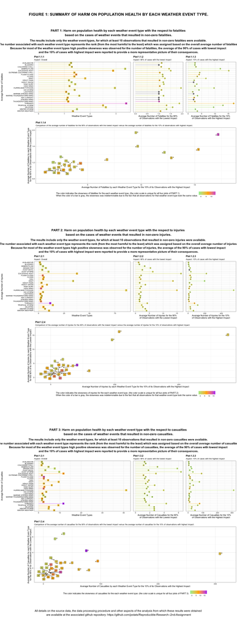

```r
# Display the Figure 1
grid.draw(figure_1)
```

The *Figure 1* was exported (as a png file), in the folder of the working directory:

- *outputs –> harm_on_population_health –> figures*

with filename:

- *figure_1.png*

```r
# Export Figure 1
ggsave(
  filename = "figure_1.png",
  plot = figure_1,
  device = "png",
  path = directory_tree_____outputs[[
    "filepath_____outputs_____harm_on_population_health_____figures"
    ]],
  width = 15,
  height = 50,
  limitsize = FALSE
)
```

back to start of this subsection  
back to start of this section  
back to start of this chapter  
back to *TABLE OF CONTENTS*

### 10.1.2 Most harmful event types with respect to fatalities

According to the summary for the harm on population health with respect to fatalities by each weather event type (that were obtained at the section 8.1 Harm On Population Health With Respect To Fatalities By Each Weather Event Type) out of the 26 included weather event types (for each of which at least 10 observations that resulted in non-zero fatalities at United States in the period from 2001 to 2011 were available) there were 7 of them that stand out:

1. When a weather event of type **TORNADO** resulted in fatalities, it caused about 3.4 fatalities on average (based on 339 observations that had extreme positive skewness equal to 13.5732). For 9 out of 10 times of such cases, an average of 1.88 fatalities was observed (based on the 90% of cases with the lower impact for which 305 observations were available, that had moderate positive skewness equal to 1.812), while for the remaining 1 out of 10 times it caused around 17 fatalities on average (based on the 10% of cases with the higher impact for which 34 observations were available, that had high positive skewness equal to 4.9099).
2. When a weather event of type **DEBRIS FLOW** resulted in fatalities, it caused about 3.36 fatalities on average (based on 11 observations that had moderate positive skewness equal to 1.6608). For 9 out of 10 times of such cases, an average of 1.44 fatalities was observed (based on the 90% of cases with the lower impact for which only 9 observations were available, that had moderate positive skewness equal to 2.0673), while for the remaining 1 out of 10 times it caused around 12 fatalities on average (based on the 10% of cases with the higher impact for which only 2 observations were available, that had low positive skewness equal to 0).
3. When a weather event of type **HURRICANE/TYPHOON** resulted in fatalities, it caused about 2.96 fatalities on average (based on 23 observations that had moderate positive skewness equal to 2.1981). For 9 out of 10 times of such cases, an average of 1.95 fatalities was observed (based on the 90% of cases with the lower impact for which 20 observations were available, that had moderate positive skewness equal to 1.6605), while for the remaining 1 out of 10 times it caused around 9.67 fatalities on average (based on the 10% of cases with the higher impact for which only 3 observations were available, that had low positive skewness equal to 0.7071).
4. When a weather event of type **EXCESSIVE HEAT** resulted in fatalities, it caused about 2.89 fatalities on average (based on 296 observations that had high positive skewness equal to 5.4405). For 9 out of 10 times of such cases, an average of 1.51 fatalities was observed (based on the 90% of cases with the lower impact for which 266 observations were available, that had moderate positive skewness equal to 1.9625), while for the remaining 1 out of 10 times it caused around 15.17 fatalities on average (based on the 10% of cases with the higher impact for which 30 observations were available, that had moderate positive skewness equal to 1.6149).
5. When a weather event of type **WILDFIRE** resulted in fatalities, it caused about 2.61 fatalities on average (based on 31 observations that had moderate positive skewness equal to 2.629). For 9 out of 10 times of such cases, an average of 1.59 fatalities was observed (based on the 90% of cases with the lower impact for which 27 observations were available, that had moderate positive skewness equal to 1.2688), while for the remaining 1 out of 10 times it caused around 9.5 fatalities on average (based on the 10% of cases with the higher impact for which only 4 observations were available, that had low negative skewness equal to -0.278).
6. When a weather event of type **TROPICAL STORM** resulted in fatalities, it caused about 2.5 fatalities on average (based on 20 observations that had high positive skewness equal to 3.8434). For 9 out of 10 times of such cases, an average of 1.33 fatalities was observed (based on the 90% of cases with the lower impact for which 18 observations were available, that had moderate positive skewness equal to 2.3814), while for the remaining 1 out of 10 times it caused around 13 fatalities on average (based on the 10% of cases with the higher impact for which only 2 observations were available, that had low positive skewness equal to 0).
7. When a weather event of type **HEAT** resulted in fatalities, it caused about 1.81 fatalities on average (based on 127 observations that had high positive skewness equal to 4.1476). For 9 out of 10 times of such cases, an average of 1.26 fatalities was observed (based on the 90% of cases with the lower impact for which 114 observations were available, that had moderate positive skewness equal to 1.912), while for the remaining 1 out of 10 times it caused around 6.62 fatalities on average (based on the 10% of cases with the higher impact for which 13 observations were available, that had moderate positive skewness equal to 1.4602).

```r
# Create an interactive table to present present the results
# for the harm on population health with respect to fatalities.
datatable(
  data = summary_____harm_on_population_health______fatalities[order(RANK)],
  caption = paste0(
    "Table 10.1.2-1: ",
    "Harm on Population Health with respect to Fatalities ",
    "by Each Weather Event Type"
  ),
  colnames = c(
    "RANK",
    "WEATHER EVENT TYPE",
    "NUMBER OF ALL AVAILABLE OBSERVATIONS",
    "AVERAGE NUMBER OF FATALITIES FOR ALL AVAILABLE CASES",
    "SKEWNESS IN FATALITIES FOR ALL AVAILABLE CASES",
    "NUMBER OF OBSERVATIONS FOR THE 90% OF CASES WITH LOWEST IMPACT",
    "AVERAGE NUMBER OF FATALITIES FOR THE 90% OF CASES WITH LOWEST IMPACT",
    "SKEWNESS IN FATALITIES FOR THE 90% OF CASES WITH LOWEST IMPACT",
    "NUMBER OF OBSERVATIONS FOR THE 10% OF CASES WITH HIGHEST IMPACT",
    "AVERAGE NUMBER OF FATALITIES FOR THE 10% OF CASES WITH HIGHEST IMPACT",
    "SKEWNESS IN FATALITIES FOR THE 10% OF CASES WITH HIGHEST IMPACT"
  ),
  rownames = FALSE,
  escape = TRUE,
  options=list(
    pageLength = nrow(summary_____harm_on_population_health______fatalities),
    dom = "t",
    initComplete = JS(
      "function(settings, json) {",
      "$(this.api().table().header()).css({'font-size': '50%'});",
      "}"
    )
  )
) %>%
  formatStyle(columns = c(1, 3:11), fontSize = '70%')%>%
  formatStyle(columns = 2, fontSize = '35%')
```

| RANK | WEATHER EVENT TYPE | NUMBER OF ALL AVAILABLE OBSERVATIONS | AVERAGE NUMBER OF FATALITIES FOR ALL AVAILABLE CASES | SKEWNESS IN FATALITIES FOR ALL AVAILABLE CASES | NUMBER OF OBSERVATIONS FOR THE 90% OF CASES WITH LOWEST IMPACT | AVERAGE NUMBER OF FATALITIES FOR THE 90% OF CASES WITH LOWEST IMPACT | SKEWNESS IN FATALITIES FOR THE 90% OF CASES WITH LOWEST IMPACT | NUMBER OF OBSERVATIONS FOR THE 10% OF CASES WITH HIGHEST IMPACT | AVERAGE NUMBER OF FATALITIES FOR THE 10% OF CASES WITH HIGHEST IMPACT | SKEWNESS IN FATALITIES FOR THE 10% OF CASES WITH HIGHEST IMPACT |
| --- | --- | --- | --- | --- | --- | --- | --- | --- | --- | --- |
| 1 | TORNADO | 339 | 3.4 | 13.5732 | 305 | 1.88 | 1.812 | 34 | 17 | 4.9099 |
| 2 | DEBRIS FLOW | 11 | 3.36 | 1.6608 | 9 | 1.44 | 2.0673 | 2 | 12 | 0 |
| 3 | HURRICANE/TYPHOON | 23 | 2.96 | 2.1981 | 20 | 1.95 | 1.6605 | 3 | 9.67 | 0.7071 |
| 4 | EXCESSIVE HEAT | 296 | 2.89 | 5.4405 | 266 | 1.51 | 1.9625 | 30 | 15.17 | 1.6149 |
| 5 | WILDFIRE | 31 | 2.61 | 2.629 | 27 | 1.59 | 1.2688 | 4 | 9.5 | -0.278 |
| 6 | TROPICAL STORM | 20 | 2.5 | 3.8434 | 18 | 1.33 | 2.3814 | 2 | 13 | 0 |
| 7 | HEAT | 127 | 1.81 | 4.1476 | 114 | 1.26 | 1.912 | 13 | 6.62 | 1.4602 |
| 8 | MARINE THUNDERSTORM WIND | 12 | 1.58 | 2.3158 | 10 | 1.2 | 1.5 | 2 | 3.5 | 0 |
| 9 | WINTER STORM | 51 | 1.49 | 0.9436 | 45 | 1.33 | 0.7071 | 6 | 2.67 | -0.7071 |
| 10 | FLASH FLOOD | 392 | 1.46 | 8.0755 | 352 | 1.16 | 1.8354 | 40 | 4.1 | 4.2361 |

[output cut: 16 more lines]

back to start of this subsection  
back to start of this section  
back to start of this chapter  
back to *TABLE OF CONTENTS*

### 10.1.3 Most harmful event types with respect to injuries

According to the summary for the harm on population health with respect to injuries by each weather event type (that were obtained at the section 8.2 Harm On Population Health With Respect To Injuries By Each Weather Event Type) out of the 27 included weather event types (for each of which at least 10 observations that resulted in non-zero injuries at United States in the period from 2001 to 2011 were available) there were 3 of them that stand out:

Specifically :

1. When a weather event of type **HURRICANE/TYPHOON** resulted in injuries, it caused about 86.07 injuries on average (based on 15 observations that had moderate positive skewness equal to 2.773). For 9 out of 10 times of such cases, an average of 15 injuries was observed (based on the 90% of cases with the lower impact for which 13 observations were available, that had moderate positive skewness equal to 2.8806), while for the remaining 1 out of 10 times it caused around 548 injuries on average (based on the 10% of cases with the higher impact for which only 2 observations were available, that had low positive skewness equal to 0).
2. When a weather event of type **EXCESSIVE HEAT** resulted in injuries, it caused about 37.7 injuries on average (based on 86 observations that had high positive skewness equal to 4.1751). For 9 out of 10 times of such cases, an average of 16.48 injuries was observed (based on the 90% of cases with the lower impact for which 77 observations were available, that had moderate positive skewness equal to 1.2674), while for the remaining 1 out of 10 times it caused around 219.22 injuries on average (based on the 10% of cases with the higher impact for which only 9 observations were available, that had low positive skewness equal to 0.7763).
3. When a weather event of type **HEAT** resulted in injuries, it caused about 33.94 injuries on average (based on 36 observations that had moderate positive skewness equal to 2.1619). For 9 out of 10 times of such cases, an average of 13.56 injuries was observed (based on the 90% of cases with the lower impact for which 32 observations were available, that had moderate positive skewness equal to 2.4589), while for the remaining 1 out of 10 times it caused around 197 injuries on average (based on the 10% of cases with the higher impact for which only 4 observations were available, that had moderate negative skewness equal to -1.0869).

```r
# Create an interactive table to present present the results
# for the harm on population health with respect to injuries.
datatable(
  data = summary_____harm_on_population_health______injuries[order(RANK)],
  caption = paste0(
    "Table 10.1.3-1: ",
    "Harm on Population Health with respect to Injuries ",
    "by Each Weather Event Type"
  ),
  colnames = c(
    "RANK",
    "WEATHER EVENT TYPE",
    "NUMBER OF ALL AVAILABLE OBSERVATIONS",
    "AVERAGE NUMBER OF INJURIES FOR ALL AVAILABLE CASES",
    "SKEWNESS IN INJURIES FOR ALL AVAILABLE CASES",
    "NUMBER OF OBSERVATIONS FOR THE 90% OF CASES WITH LOWEST IMPACT",
    "AVERAGE NUMBER OF INJURIES FOR THE 90% OF CASES WITH LOWEST IMPACT",
    "SKEWNESS IN INJURIES FOR THE 90% OF CASES WITH LOWEST IMPACT",
    "NUMBER OF OBSERVATIONS FOR THE 10% OF CASES WITH HIGHEST IMPACT",
    "AVERAGE NUMBER OF INJURIES FOR THE 10% OF CASES WITH HIGHEST IMPACT",
    "SKEWNESS IN INJURIES FOR THE 10% OF CASES WITH HIGHEST IMPACT"
  ),
  rownames = FALSE,
  escape = TRUE,
  options=list(
    pageLength = nrow(summary_____harm_on_population_health______injuries),
    dom = "t",
    initComplete = JS(
      "function(settings, json) {",
      "$(this.api().table().header()).css({'font-size': '50%'});",
      "}"
    )
  )
) %>%
  formatStyle(columns = c(1, 3:11), fontSize = '70%')%>%
  formatStyle(columns = 2, fontSize = '35%')
```

| RANK | WEATHER EVENT TYPE | NUMBER OF ALL AVAILABLE OBSERVATIONS | AVERAGE NUMBER OF INJURIES FOR ALL AVAILABLE CASES | SKEWNESS IN INJURIES FOR ALL AVAILABLE CASES | NUMBER OF OBSERVATIONS FOR THE 90% OF CASES WITH LOWEST IMPACT | AVERAGE NUMBER OF INJURIES FOR THE 90% OF CASES WITH LOWEST IMPACT | SKEWNESS IN INJURIES FOR THE 90% OF CASES WITH LOWEST IMPACT | NUMBER OF OBSERVATIONS FOR THE 10% OF CASES WITH HIGHEST IMPACT | AVERAGE NUMBER OF INJURIES FOR THE 10% OF CASES WITH HIGHEST IMPACT | SKEWNESS IN INJURIES FOR THE 10% OF CASES WITH HIGHEST IMPACT |
| --- | --- | --- | --- | --- | --- | --- | --- | --- | --- | --- |
| 1 | HURRICANE/TYPHOON | 15 | 86.07 | 2.773 | 13 | 15 | 2.8806 | 2 | 548 | 0 |
| 2 | EXCESSIVE HEAT | 86 | 37.7 | 4.1751 | 77 | 16.48 | 1.2674 | 9 | 219.22 | 0.7763 |
| 3 | HEAT | 36 | 33.94 | 2.1619 | 32 | 13.56 | 2.4589 | 4 | 197 | -1.0869 |
| 4 | TROPICAL STORM | 19 | 14.05 | 3.8833 | 17 | 2.24 | 1.7452 | 2 | 114.5 | 0 |
| 5 | TORNADO | 1252 | 11.45 | 16.3086 | 1126 | 4.25 | 1.9101 | 126 | 75.76 | 5.7628 |
| 6 | WINTER WEATHER | 47 | 10.28 | 4.1679 | 42 | 3.98 | 1.6058 | 5 | 63.2 | 0.859 |
| 7 | DUST STORM | 22 | 9.73 | 1.5095 | 19 | 6.26 | 1.3333 | 3 | 31.67 | 0.3818 |
| 8 | HEAVY SNOW | 31 | 8.26 | 4.3682 | 27 | 3.56 | 1.3865 | 4 | 40 | 1.0093 |
| 9 | DENSE FOG | 20 | 7.15 | 1.4182 | 18 | 5.39 | 0.7286 | 2 | 23 | 0 |
| 10 | WINTER STORM | 51 | 6.29 | 3.1228 | 45 | 3.53 | 1.108 | 6 | 27 | 0.4624 |

[output cut: 17 more lines]

back to start of this subsection  
back to start of this section  
back to start of this chapter  
back to *TABLE OF CONTENTS*

### 10.1.4 Most harmful event types with respect to casualties

According to the summary for the harm on population health with respect to casualties by each weather event type (that were obtained at the section 8.3 Harm On Population Health With Respect To Casualties By Each Weather Event Type) out of the 30 included weather event types (for each of which at least 10 observations that resulted in non-zero casualties at United States in the period from 2001 to 2011 were available) there were 7 of them that stand out:

Specifically :

1. When a weather event of type **HURRICANE/TYPHOON** resulted in casualties, it caused about 41.18 casualties on average (based on 33 observations that had high positive skewness equal to 4.4573). For 9 out of 10 times of such cases, an average of 3.93 casualties was observed (based on the 90% of cases with the lower impact for which 29 observations were available, that had moderate positive skewness equal to 2.1573), while for the remaining 1 out of 10 times it caused around 311.25 casualties on average (based on the 10% of cases with the higher impact for which only 4 observations were available, that had low positive skewness equal to 0.7473).
2. When a weather event of type **EXCESSIVE HEAT** resulted in casualties, it caused about 11.71 casualties on average (based on 350 observations that had extreme positive skewness equal to 8.3298). For 9 out of 10 times of such cases, an average of 2.85 casualties was observed (based on the 90% of cases with the lower impact for which 315 observations were available, that had moderate positive skewness equal to 2.7042), while for the remaining 1 out of 10 times it caused around 91.43 casualties on average (based on the 10% of cases with the higher impact for which 35 observations were available, that had moderate positive skewness equal to 2.7186).
3. When a weather event of type **TORNADO** resulted in casualties, it caused about 11.67 casualties on average (based on 1327 observations that had extreme positive skewness equal to 17.6038). For 9 out of 10 times of such cases, an average of 4.29 casualties was observed (based on the 90% of cases with the lower impact for which 1194 observations were available, that had moderate positive skewness equal to 1.936), while for the remaining 1 out of 10 times it caused around 77.9 casualties on average (based on the 10% of cases with the higher impact for which 133 observations were available, that had high positive skewness equal to 6.2215).
4. When a weather event of type **DUST STORM** resulted in casualties, it caused about 9.7 casualties on average (based on 23 observations that had moderate positive skewness equal to 1.5025). For 9 out of 10 times of such cases, an average of 6.35 casualties was observed (based on the 90% of cases with the lower impact for which 20 observations were available, that had moderate positive skewness equal to 1.2737), while for the remaining 1 out of 10 times it caused around 32 casualties on average (based on the 10% of cases with the higher impact for which only 3 observations were available, that had low positive skewness equal to 0.4703).
5. When a weather event of type **HEAT** resulted in casualties, it caused about 9.43 casualties on average (based on 154 observations that had high positive skewness equal to 5.2894). For 9 out of 10 times of such cases, an average of 1.7 casualties was observed (based on the 90% of cases with the lower impact for which 138 observations were available, that had moderate positive skewness equal to 2.459), while for the remaining 1 out of 10 times it caused around 76.12 casualties on average (based on the 10% of cases with the higher impact for which 16 observations were available, that had low positive skewness equal to 0.9965).
6. When a weather event of type **TROPICAL STORM** resulted in casualties, it caused about 9.32 casualties on average (based on 34 observations that had high positive skewness equal to 5.3288). For 9 out of 10 times of such cases, an average of 1.9 casualties was observed (based on the 90% of cases with the lower impact for which 30 observations were available, that had moderate positive skewness equal to 1.4887), while for the remaining 1 out of 10 times it caused around 65 casualties on average (based on the 10% of cases with the higher impact for which only 4 observations were available, that had moderate positive skewness equal to 1.1226).
7. When a weather event of type **DENSE FOG** resulted in casualties, it caused about 7.6 casualties on average (based on 20 observations that had moderate positive skewness equal to 1.3831). For 9 out of 10 times of such cases, an average of 5.83 casualties was observed (based on the 90% of cases with the lower impact for which 18 observations were available, that had low positive skewness equal to 0.5675), while for the remaining 1 out of 10 times it caused around 23.5 casualties on average (based on the 10% of cases with the higher impact for which only 2 observations were available, that had low positive skewness equal to 0).

```r
# Create an interactive table to present present the results
# for the harm on population health with respect to casualties.
datatable(
  data = summary_____harm_on_population_health______casualties[order(RANK)],
  caption = paste0(
    "Table 10.1.4-1: ",
    "Harm on Population Health with respect to Casualties ",
    "by Each Weather Event Type"
  ),
  colnames = c(
    "RANK",
    "WEATHER EVENT TYPE",
    "NUMBER OF ALL AVAILABLE OBSERVATIONS",
    "AVERAGE NUMBER OF CASUALTIES FOR ALL AVAILABLE CASES",
    "SKEWNESS IN CASUALTIES FOR ALL AVAILABLE CASES",
    "NUMBER OF OBSERVATIONS FOR THE 90% OF CASES WITH LOWEST IMPACT",
    "AVERAGE NUMBER OF CASUALTIES FOR THE 90% OF CASES WITH LOWEST IMPACT",
    "SKEWNESS IN CASUALTIES FOR THE 90% OF CASES WITH LOWEST IMPACT",
    "NUMBER OF OBSERVATIONS FOR THE 10% OF CASES WITH HIGHEST IMPACT",
    "AVERAGE NUMBER OF CASUALTIES FOR THE 10% OF CASES WITH HIGHEST IMPACT",
    "SKEWNESS IN CASUALTIES FOR THE 10% OF CASES WITH HIGHEST IMPACT"
  ),
  rownames = FALSE,
  escape = TRUE,
  options=list(
    pageLength = nrow(summary_____harm_on_population_health______casualties),
    dom = "t",
    initComplete = JS(
      "function(settings, json) {",
      "$(this.api().table().header()).css({'font-size': '50%'});",
      "}"
    )
  )
) %>%
  formatStyle(columns = c(1, 3:11), fontSize = '70%')%>%
  formatStyle(columns = 2, fontSize = '35%')
```

| RANK | WEATHER EVENT TYPE | NUMBER OF ALL AVAILABLE OBSERVATIONS | AVERAGE NUMBER OF CASUALTIES FOR ALL AVAILABLE CASES | SKEWNESS IN CASUALTIES FOR ALL AVAILABLE CASES | NUMBER OF OBSERVATIONS FOR THE 90% OF CASES WITH LOWEST IMPACT | AVERAGE NUMBER OF CASUALTIES FOR THE 90% OF CASES WITH LOWEST IMPACT | SKEWNESS IN CASUALTIES FOR THE 90% OF CASES WITH LOWEST IMPACT | NUMBER OF OBSERVATIONS FOR THE 10% OF CASES WITH HIGHEST IMPACT | AVERAGE NUMBER OF CASUALTIES FOR THE 10% OF CASES WITH HIGHEST IMPACT | SKEWNESS IN CASUALTIES FOR THE 10% OF CASES WITH HIGHEST IMPACT |
| --- | --- | --- | --- | --- | --- | --- | --- | --- | --- | --- |
| 1 | HURRICANE/TYPHOON | 33 | 41.18 | 4.4573 | 29 | 3.93 | 2.1573 | 4 | 311.25 | 0.7473 |
| 2 | EXCESSIVE HEAT | 350 | 11.71 | 8.3298 | 315 | 2.85 | 2.7042 | 35 | 91.43 | 2.7186 |
| 3 | TORNADO | 1327 | 11.67 | 17.6038 | 1194 | 4.29 | 1.936 | 133 | 77.9 | 6.2215 |
| 4 | DUST STORM | 23 | 9.7 | 1.5025 | 20 | 6.35 | 1.2737 | 3 | 32 | 0.4703 |
| 5 | HEAT | 154 | 9.43 | 5.2894 | 138 | 1.7 | 2.459 | 16 | 76.12 | 0.9965 |
| 6 | TROPICAL STORM | 34 | 9.32 | 5.3288 | 30 | 1.9 | 1.4887 | 4 | 65 | 1.1226 |
| 7 | DENSE FOG | 20 | 7.6 | 1.3831 | 18 | 5.83 | 0.5675 | 2 | 23.5 | 0 |
| 8 | WINTER WEATHER | 74 | 7.35 | 5.2237 | 66 | 2.62 | 1.3941 | 8 | 46.38 | 1.4182 |
| 9 | HEAVY SNOW | 45 | 6.2 | 5.2993 | 40 | 2.67 | 2.1501 | 5 | 34.4 | 1.3347 |
| 10 | WILDFIRE | 244 | 4.84 | 6.5566 | 219 | 2.6 | 1.5251 | 25 | 24.44 | 2.6702 |

[output cut: 20 more lines]

back to start of this subsection  
back to start of this section  
back to start of this chapter  
back to *TABLE OF CONTENTS*

## 10.2 Question 2 : Across the United States, which types of events have the greatest economic consequences?

In an attempt to identify the most harmful weather event types with respect to economy three different perspectives were examined (for which the analysis can be examined at the chapter 9 HARM ON ECONOMY.

A short overview of the results was presented at the subsection:

- 10.2.1 Overview of results for the harm on economy

Further details, at each of the three perspectives, are available at the following subsections:

- 10.2.2 Most harmful event types with respect to property damage
- 10.2.3 Most harmful event types with respect to crop damage
- 10.2.4 Most harmful event types with respect to economic damage

It is highlighted that the results must be evaluated under the following context in order to be meaningful:

- **The results for a perspective (property damage, crop damage or economic damage) refer specifically to the harm that was caused when harm with respect to that perspective was observed.**

(*In other words the results do not refer to the harm caused for a perspective of interest when a weather phenomenon of an included weather event type occurred independently of whether or not it caused harm with respect to the perspective that was examined.*)

In addition, due to the fact that it was decided to include only the weather event types for which there were available at least 10 observations that corresponded to weather events that resulted in non-zero harm with respect to each perspective examined, the composition of weather event types for the three perspectives is different.

For each perspective, it was consider appropriate to present three aspects in order to supply an insightful picture of the consequences caused by each weather event type:

- the overall average harm
- the average harm of 90% of cases with lower impact
- the average harm of 10% of cases with higher impact

The number of observations as well as their skewness were summarized by each weather event types for every aspect and presented along with the corresponding average.

Although the overall average harm was used as the primary criterion to determine the most harmful events, it should be examined along with the average harm for the two other subgroups, especially when the overall skewness for a weather event type of interest is high.

back to start of this section  
back to start of this chapter  
back to *TABLE OF CONTENTS*

### 10.2.1 Overview of results for the harm on economy

In order to display an overview of the results for the harm on economy by each weather event type the Figure 2 was created.

```r
# Compose the Figure 1, by combining
#   - Multiplot 2.1
#   - Multiplot 2.2
#   - Multiplot 2.3
figure_2 <- arrangeGrob(
  grobs = list(
      ## TITLE
      textGrob(
          label = paste0(
              "FIGURE 2: SUMMARY OF HARM ON ECONOMY BY EACH WEATHER EVENT TYPE."
          ),
          gp=gpar(
              fontsize = 20,
              fontface = "bold"
          )
      ),
      ## PART 1.
      multiplot_2_1,
      ## PART 2
      multiplot_2_2,
      ## PART 3
      multiplot_2_3,
      ## CAPTION
      textGrob(
          label = paste0(
              "\n",
              "All details on the source data, the data processing procedure and other ",
              "aspects of the analysis from which these results were obtained ", "\n",
              "are available at the associated github repository: ",
              "https://github.com/jzstats/Reproducible-Research--2nd-Assignment",
            "\n"
        ),
        gp=gpar(
            fontsize = 14
        )
    )
  ),
  layout_matrix = matrix(
      data = c(1,
               2,
               2,
               2,
               2,
               2,
               2,
               NA,
               3,
               3,
               3,
               3,
               3,
               NA,
               4,
               4,
               4,
               4,
               4,
               4,
               5
      ),
      byrow = TRUE,
      ncol = 1
  )
)
```

The *Figure 2* consists of three parts, one for each of the three perspective examined:

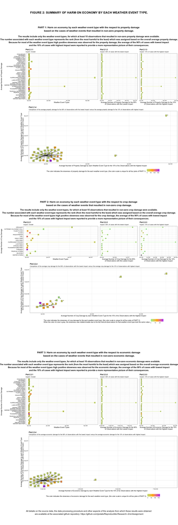

```r
# Display the Figure 2
grid.draw(figure_2)
```

The *Figure 2* was exported (as a png file), in the folder of the working directory:

- *outputs –> harm_on_economy –> figures*

with filename:

- *figure_2.png*

```r
# Export Figure 1
ggsave(
  filename = "figure_2.png",
  plot = figure_2,
  device = "png",
  path = directory_tree_____outputs[[
    "filepath_____outputs_____harm_on_economy_____figures"
    ]],
  width = 15,
  height = 50,
  limitsize = FALSE
)
```

back to start of this subsection  
back to start of this section  
back to start of this chapter  
back to *TABLE OF CONTENTS*

### 10.2.2 Most harmful event types with respect to property damage

According to the summary for the harm on economy with respect to property damage by each weather event type (that were obtained at the section 9.1 Harm On Economy With Respect To Property Damage By Each Weather Event Type) out of the 37 included weather event types (for each of which at least 10 observations that resulted in non-zero property damage  
at United States in the period from 2001 to 2011 were available) there were 2 of them that stand out:

1. When a weather event of type **HURRICANE/TYPHOON** resulted in property damage, it caused about 676106028$ of property damage on average (based on 107 observations that had high positive skewness equal to 4.9333). For 9 out of 10 times of such cases, an average of 81701511$ of property damage was observed (based on the 90% of cases with the lower impact for which 96 observations were available, that had high positive skewness equal to 3.4556), while for the remaining 1 out of 10 times it caused around 5863636364$ of property damage on average (based on the 10% of cases with the higher impact for which 11 observations were available, that had moderate positive skewness equal to 1.5154).
2. When a weather event of type **STORM SURGE/TIDE** resulted in property damage, it caused about 364969183$ of property damage on average (based on 131 observations that had extreme positive skewness equal to 9.6344). For 9 out of 10 times of such cases, an average of 749256$ of property damage was observed (based on the 90% of cases with the lower impact for which 117 observations were available, that had moderate positive skewness equal to 2.9093), while for the remaining 1 out of 10 times it caused around 3408807143$ of property damage on average (based on the 10% of cases with the higher impact for which 14 observations were available, that had moderate positive skewness equal to 2.7389).

```r
# Create an interactive table to present present the results
# for the harm on economy with respect to property damage.
datatable(
  data = summary_____harm_on_economy______property_damage[order(RANK)],
  caption = paste0(
    "Table 10.2.2-1: ",
    "Harm on Population Health with respect to Property Damage ",
    "by Each Weather Event Type"
  ),
  colnames = c(
    "RANK",
    "WEATHER EVENT TYPE",
    "NUMBER OF ALL AVAILABLE OBSERVATIONS",
    "AVERAGE PROPERTY DAMAGE FOR ALL AVAILABLE CASES",
    "SKEWNESS IN PROPERTY DAMAGE FOR ALL AVAILABLE CASES",
    "NUMBER OF OBSERVATIONS FOR THE 90% OF CASES WITH LOWEST IMPACT",
    "AVERAGE PROPERTY DAMAGE FOR THE 90% OF CASES WITH LOWEST IMPACT",
    "SKEWNESS IN PROPERTY DAMAGE FOR THE 90% OF CASES WITH LOWEST IMPACT",
    "NUMBER OF OBSERVATIONS FOR THE 10% OF CASES WITH HIGHEST IMPACT",
    "AVERAGE PROPERTY DAMAGE FOR THE 10% OF CASES WITH HIGHEST IMPACT",
    "SKEWNESS IN PROPERTY DAMAGE FOR THE 10% OF CASES WITH HIGHEST IMPACT"
  ),
  rownames = FALSE,
  escape = TRUE,
  options=list(
    pageLength = nrow(summary_____harm_on_economy______property_damage),
    dom = "t",
    initComplete = JS(
      "function(settings, json) {",
      "$(this.api().table().header()).css({'font-size': '50%'});",
      "}"
    )
  )
) %>%
  formatStyle(columns = c(1, 3:11), fontSize = '50%')%>%
  formatStyle(columns = 2, fontSize = '35%')
```

| RANK | WEATHER EVENT TYPE | NUMBER OF ALL AVAILABLE OBSERVATIONS | AVERAGE PROPERTY DAMAGE FOR ALL AVAILABLE CASES | SKEWNESS IN PROPERTY DAMAGE FOR ALL AVAILABLE CASES | NUMBER OF OBSERVATIONS FOR THE 90% OF CASES WITH LOWEST IMPACT | AVERAGE PROPERTY DAMAGE FOR THE 90% OF CASES WITH LOWEST IMPACT | SKEWNESS IN PROPERTY DAMAGE FOR THE 90% OF CASES WITH LOWEST IMPACT | NUMBER OF OBSERVATIONS FOR THE 10% OF CASES WITH HIGHEST IMPACT | AVERAGE PROPERTY DAMAGE FOR THE 10% OF CASES WITH HIGHEST IMPACT | SKEWNESS IN PROPERTY DAMAGE FOR THE 10% OF CASES WITH HIGHEST IMPACT |
| --- | --- | --- | --- | --- | --- | --- | --- | --- | --- | --- |
| 1 | HURRICANE/TYPHOON | 107 | 676106028.13 | 4.9333 | 96 | 81701510.52 | 3.4556 | 11 | 5863636363.64 | 1.5154 |
| 2 | STORM SURGE/TIDE | 131 | 364969183.21 | 9.6344 | 117 | 749256.41 | 2.9093 | 14 | 3408807142.86 | 2.7389 |
| 3 | DROUGHT | 30 | 28198600 | 4.9802 | 27 | 1881777.78 | 2.2218 | 3 | 265050000 | 0.6889 |
| 4 | TROPICAL STORM | 363 | 19818927.13 | 18.5864 | 326 | 557517.02 | 2.8131 | 37 | 189527567.57 | 5.731 |
| 5 | FLOOD | 7072 | 18944063.85 | 83.9862 | 6364 | 164666.8 | 2.6823 | 708 | 187746440.68 | 26.5242 |
| 6 | TSUNAMI | 14 | 10290142.86 | 2.7176 | 12 | 3038500 | 1.3942 | 2 | 53800000 | 0 |
| 7 | WILDFIRE | 832 | 6015288.22 | 15.4642 | 748 | 367232.35 | 3.0582 | 84 | 56309880.95 | 4.8329 |
| 8 | ICE STORM | 410 | 4816462.93 | 8.6732 | 369 | 557966.94 | 3.9291 | 41 | 43142926.83 | 2.7942 |
| 9 | TORNADO | 8552 | 2226030.12 | 55.2385 | 7696 | 139607.53 | 2.4389 | 856 | 20984334.11 | 17.7218 |
| 10 | DEBRIS FLOW | 189 | 1721708.99 | 6.0565 | 170 | 207605.88 | 3.0507 | 19 | 15268947.37 | 1.823 |

[output cut: 27 more lines]

back to start of this subsection  
back to start of this section  
back to start of this chapter  
back to *TABLE OF CONTENTS*

### 10.2.3 Most harmful event types with respect to crop damage

According to the summary for the harm on economy with respect to crop damage by each weather event type (that were obtained at the section 9.2 Harm On Economy With Respect To Crop Damage By Each Weather Event Type) out of the 16 included weather event types (for each of which at least 10 observations that resulted in non-zero crop damage  
at United States in the period from 2001 to 2011 were available) there were 2 of them that stand out:

1. When a weather event of type **HURRICANE/TYPHOON** resulted in crop damage, it caused about 63684017$ of crop damage on average (based on 48 observations that had high positive skewness equal to 5.6962). For 9 out of 10 times of such cases, an average of 13275181$ of crop damage was observed (based on the 90% of cases with the lower impact for which 43 observations were available, that had moderate positive skewness equal to 2.4986), while for the remaining 1 out of 10 times it caused around 497200000$ of crop damage on average (based on the 10% of cases with the higher impact for which only 5 observations were available, that had moderate positive skewness equal to 1.3378).
2. When a weather event of type **DROUGHT** resulted in crop damage, it caused about 42389146$ of crop damage on average (based on 158 observations that had high positive skewness equal to 4.9333). For 9 out of 10 times of such cases, an average of 11981373$ of crop damage was observed (based on the 90% of cases with the lower impact for which 142 observations were available, that had moderate positive skewness equal to 2.3645), while for the remaining 1 out of 10 times it caused around 312258125$ of crop damage on average (based on the 10% of cases with the higher impact for which 16 observations were available, that had moderate positive skewness equal to 1.8881).

```r
# Create an interactive table to present present the results
# for the harm on economy with respect to crop damage.
datatable(
  data = summary_____harm_on_economy______crop_damage[order(RANK)],
  caption = paste0(
    "Table 10.2.3-1: ",
    "Harm on Population Health with respect to Crop Damage ",
    "by Each Weather Event Type"
  ),
  colnames = c(
    "RANK",
    "WEATHER EVENT TYPE",
    "NUMBER OF ALL AVAILABLE OBSERVATIONS",
    "AVERAGE CROP DAMAGE FOR ALL AVAILABLE CASES",
    "SKEWNESS IN CROP DAMAGE FOR ALL AVAILABLE CASES",
    "NUMBER OF OBSERVATIONS FOR THE 90% OF CASES WITH LOWEST IMPACT",
    "AVERAGE CROP DAMAGE FOR THE 90% OF CASES WITH LOWEST IMPACT",
    "SKEWNESS IN CROP DAMAGE FOR THE 90% OF CASES WITH LOWEST IMPACT",
    "NUMBER OF OBSERVATIONS FOR THE 10% OF CASES WITH HIGHEST IMPACT",
    "AVERAGE CROP DAMAGE FOR THE 10% OF CASES WITH HIGHEST IMPACT",
    "SKEWNESS IN CROP DAMAGE FOR THE 10% OF CASES WITH HIGHEST IMPACT"
  ),
  rownames = FALSE,
  escape = TRUE,
  options=list(
    pageLength = nrow(summary_____harm_on_economy______crop_damage),
    dom = "t",
    initComplete = JS(
      "function(settings, json) {",
      "$(this.api().table().header()).css({'font-size': '50%'});",
      "}"
    )
  )
) %>%
  formatStyle(columns = c(1, 3:11), fontSize = '50%')%>%
  formatStyle(columns = 2, fontSize = '35%')
```

| RANK | WEATHER EVENT TYPE | NUMBER OF ALL AVAILABLE OBSERVATIONS | AVERAGE CROP DAMAGE FOR ALL AVAILABLE CASES | SKEWNESS IN CROP DAMAGE FOR ALL AVAILABLE CASES | NUMBER OF OBSERVATIONS FOR THE 90% OF CASES WITH LOWEST IMPACT | AVERAGE CROP DAMAGE FOR THE 90% OF CASES WITH LOWEST IMPACT | SKEWNESS IN CROP DAMAGE FOR THE 90% OF CASES WITH LOWEST IMPACT | NUMBER OF OBSERVATIONS FOR THE 10% OF CASES WITH HIGHEST IMPACT | AVERAGE CROP DAMAGE FOR THE 10% OF CASES WITH HIGHEST IMPACT | SKEWNESS IN CROP DAMAGE FOR THE 10% OF CASES WITH HIGHEST IMPACT |
| --- | --- | --- | --- | --- | --- | --- | --- | --- | --- | --- |
| 1 | HURRICANE/TYPHOON | 48 | 63684016.67 | 5.6962 | 43 | 13275181.4 | 2.4986 | 5 | 497200000 | 1.3378 |
| 2 | DROUGHT | 158 | 42389145.57 | 4.9333 | 142 | 11981373.24 | 2.3645 | 16 | 312258125 | 1.8881 |
| 3 | EXTREME COLD/WIND CHILL | 11 | 15612727.27 | 1.6402 | 9 | 3187777.78 | 0.5652 | 2 | 71525000 | 0 |
| 4 | FROST/FREEZE | 106 | 10772981.13 | 5.8134 | 95 | 2259747.37 | 2.0012 | 11 | 84296363.64 | 1.8805 |
| 5 | TROPICAL STORM | 52 | 7928096.15 | 3.407 | 46 | 2266543.48 | 2.9393 | 6 | 51333333.33 | 0.934 |
| 6 | HEAVY RAIN | 75 | 5368773.33 | 7.8538 | 67 | 1554000 | 2.0373 | 8 | 37317500 | 2.2474 |
| 7 | HIGH WIND | 123 | 4039284.55 | 7.5985 | 110 | 417018.18 | 2.8571 | 13 | 34689230.77 | 2.2728 |
| 8 | WILDFIRE | 91 | 3269004.73 | 5.3055 | 81 | 241721.36 | 2.5162 | 10 | 27790000 | 1.0727 |
| 9 | FLOOD | 1263 | 2859309.11 | 19.0535 | 1136 | 239073.42 | 3.6684 | 127 | 26297007.87 | 6.7167 |
| 10 | STRONG WIND | 94 | 690994.68 | 8.5291 | 84 | 2690.48 | 1.1555 | 10 | 6472750 | 2.2953 |

[output cut: 6 more lines]

back to start of this subsection  
back to start of this section  
back to start of this chapter  
back to *TABLE OF CONTENTS*

### 10.2.4 Most harmful event types with respect to economic damage

1. When a weather event of type **HURRICANE/TYPHOON** resulted in economic damage, it caused about 698149795$ economic damage on average (based on 108 observations that had high positive skewness equal to 4.7929). For 9 out of 10 times of such cases, an average of 92388431$ economic damage was observed (based on the 90% of cases with the lower impact for which 97 observations were available, that had high positive skewness equal to 3.0615), while for the remaining 1 out of 10 times it caused around 6039863636$ economic damage on average (based on the 10% of cases with the higher impact for which 11 observations were available, that had moderate positive skewness equal to 1.3803).
2. When a weather event of type **STORM SURGE/TIDE** resulted in economic damage, it caused about 364975672$ economic damage on average (based on 131 observations that had extreme positive skewness equal to 9.6344). For 9 out of 10 times of such cases, an average of 756521$ economic damage was observed (based on the 90% of cases with the lower impact for which 117 observations were available, that had moderate positive skewness equal to 2.898), while for the remaining 1 out of 10 times it caused around 3408807143$ economic damage on average (based on the 10% of cases with the higher impact for which 14 observations were available, that had moderate positive skewness equal to 2.7389).

```r
# Create an interactive table to present present the results
# for the harm on economy with respect to economic damage.
datatable(
  data = summary_____harm_on_economy______economic_damage[order(RANK)],
  caption = paste0(
    "Table 10.2.4-3: ",
    "Harm on Population Health with respect to Economic Damage ",
    "by Each Weather Event Type "
  ),
  colnames = c(
    "RANK",
    "WEATHER EVENT TYPE",
    "NUMBER OF ALL AVAILABLE OBSERVATIONS",
    "AVERAGE ECONOMIC DAMAGE FOR ALL AVAILABLE CASES",
    "SKEWNESS IN ECONOMIC DAMAGE FOR ALL AVAILABLE CASES",
    "NUMBER OF OBSERVATIONS FOR THE 90% OF CASES WITH LOWEST IMPACT",
    "AVERAGE ECONOMIC DAMAGE FOR THE 90% OF CASES WITH LOWEST IMPACT",
    "SKEWNESS IN ECONOMIC DAMAGE FOR THE 90% OF CASES WITH LOWEST IMPACT",
    "NUMBER OF OBSERVATIONS FOR THE 10% OF CASES WITH HIGHEST IMPACT",
    "AVERAGE ECONOMIC DAMAGE FOR THE 10% OF CASES WITH HIGHEST IMPACT",
    "SKEWNESS IN ECONOMIC DAMAGE FOR THE 10% OF CASES WITH HIGHEST IMPACT"
  ),
  rownames = FALSE,
  escape = TRUE,
  options=list(
    pageLength = nrow(summary_____harm_on_economy______economic_damage),
    dom = "t",
    initComplete = JS(
      "function(settings, json) {",
      "$(this.api().table().header()).css({'font-size': '50%'});",
      "}"
    )
  )
) %>%
  formatStyle(columns = c(1, 3:11), fontSize = '50%')%>%
  formatStyle(columns = 2, fontSize = '35%')
```

| RANK | WEATHER EVENT TYPE | NUMBER OF ALL AVAILABLE OBSERVATIONS | AVERAGE ECONOMIC DAMAGE FOR ALL AVAILABLE CASES | SKEWNESS IN ECONOMIC DAMAGE FOR ALL AVAILABLE CASES | NUMBER OF OBSERVATIONS FOR THE 90% OF CASES WITH LOWEST IMPACT | AVERAGE ECONOMIC DAMAGE FOR THE 90% OF CASES WITH LOWEST IMPACT | SKEWNESS IN ECONOMIC DAMAGE FOR THE 90% OF CASES WITH LOWEST IMPACT | NUMBER OF OBSERVATIONS FOR THE 10% OF CASES WITH HIGHEST IMPACT | AVERAGE ECONOMIC DAMAGE FOR THE 10% OF CASES WITH HIGHEST IMPACT | SKEWNESS IN ECONOMIC DAMAGE FOR THE 10% OF CASES WITH HIGHEST IMPACT |
| --- | --- | --- | --- | --- | --- | --- | --- | --- | --- | --- |
| 1 | HURRICANE/TYPHOON | 108 | 698149794.54 | 4.7929 | 97 | 92388431.03 | 3.0615 | 11 | 6039863636.36 | 1.3803 |
| 2 | STORM SURGE/TIDE | 131 | 364975671.76 | 9.6344 | 117 | 756521.37 | 2.898 | 14 | 3408807142.86 | 2.7389 |
| 3 | DROUGHT | 171 | 44113701.75 | 4.6871 | 153 | 11645771.24 | 2.3438 | 18 | 320091111.11 | 1.5826 |
| 4 | EXCESSIVE HEAT | 21 | 23657390.48 | 4.2483 | 18 | 50622.22 | 1.5998 | 3 | 165298000 | 0.707 |
| 5 | TROPICAL STORM | 370 | 20558193.38 | 18.7288 | 333 | 759133.78 | 2.8851 | 37 | 198749729.73 | 5.7297 |
| 6 | FLOOD | 7368 | 18673144.26 | 85.7213 | 6631 | 195162.24 | 2.8273 | 737 | 184924838.67 | 27.063 |
| 7 | TSUNAMI | 14 | 10291571.43 | 2.7178 | 12 | 3038500 | 1.3942 | 2 | 53810000 | 0 |
| 8 | FROST/FREEZE | 120 | 9595133.33 | 6.1949 | 108 | 1935796.3 | 2.0586 | 12 | 78529166.67 | 1.9278 |
| 9 | WILDFIRE | 878 | 6038951.29 | 15.6629 | 790 | 372742.06 | 2.9959 | 88 | 56906056.82 | 4.9125 |
| 10 | EXTREME COLD/WIND CHILL | 32 | 5646593.75 | 3.5596 | 28 | 737178.57 | 2.4931 | 4 | 40012500 | 0.0614 |

[output cut: 27 more lines]

back to start of this subsection  
back to start of this section  
back to start of this chapter  
back to *TABLE OF CONTENTS*

# 11 REPRODUCIBILITY DETAILS

To help in any attempt to reproduce the report with this analysis beyond the structure and the in-detail description of the procedure that took place during the execution of the script, several details are provided to make it as easy as possible.

Specifically, in this chapter, information is supplied about:

1. the r session
2. the r options
3. the MD5 checksums of some important files
4. the random seed

back to start of this chapter  
back to *TABLE OF CONTENTS*

## 11.1 Session Info

The details with respect to the operating system, R version as wells as the versions of the libraries used to create this report are supplied to help in any attempt to reproduce the report.

```r
# Captures the session info.

# Display the session info.
session_info
```

[output not shown]

An object with the information on the session was also exported at the folder of working directory:

- *outputs –> reproducibility_support –> r_session*

with filename:

- *session_info.R*

```r
# Supply the filepath at which the R file with the session info will be exported.
filepath_____session_info <- file.path(
directory_tree_____outputs[[
    "filepath_____outputs_____reproducibility_support_____r_session"
  ]],
  "session_info.R"
)

# Export the session info as an R file.
saveRDS(
  object = session_info,
  file = filepath_____session_info
)
```

back to start of this section  
back to start of this chapter  
back to *TABLE OF CONTENTS*

## 11.2 Options

The details with respect to the r options active while the script that produced the report were executed are supplied to help in any attempt to reproduce the report.

```r
# Captures the R options.
r_options <- options()

# Displays the R options
r_options
```

[output not shown]

[output cut: 711 more lines]

[output not shown]

An object with the information for r option was also exported at the folder of working directory:

- *outputs –> reproducibility_support –> r_session*

with filename:

- *r_options.R*

```r
# Supply the filepath at which the R file with the R options will be exported.
filepath_____r_options <- file.path(
directory_tree_____outputs[[
    "filepath_____outputs_____reproducibility_support_____r_session"
  ]],
  "r_options.R"
)
# Export the R options as an R file.
saveRDS(
  object = r_options,
  file = filepath_____r_options
)
```

back to start of this section  
back to start of this chapter  
back to *TABLE OF CONTENTS*

## 11.3 MD5 Checksums

Three txt files with MD5 checksums were created:

1. unprocessed_data_____MD5_checksum.txt
2. processed_data_____MD5_checksum.txt
3. results_____MD5_checksum.txt

and exported at the subdirectory of the working directory:

- *output –> reproducibility_support –> MD5_checksums*

The [original files with the MD5 Checksums](https://github.com/jzstats/Reproducible-Research--2nd-Assignment/tree/master/outputs/reproducibility_support/MD5_checksums) have been uploaded to github.

back to start of this section  
back to start of this chapter  
back to *TABLE OF CONTENTS*

### 11.3.1 Create a utility function to export MD5 checksums

It takes as input two arguments:

1. target_files
   - the paths to the files of which we want to compute the MD5 checksums
2. output_file
   - the path at which the txt file with the MD5 checksums of the target files will be exported

Upon execution, it creates a txt file at the path denoted by the argument ‘output_file’ in which it stores the MD5 checksums of the files found at the paths supplied via the ‘target_files’ argument.

The txt files consists of one row for each of the target files, which:

- begins with MD5 checksum
- followed by two spaces
- ends the the path of the file to which the MD5 corresponds

```r
# utility function: export_md5sum()
#
# Creates and exports a txt file with the MD5 checksums of some target files.
#
# Arguments:
#  'target_files'  :  A character vector with the paths of the target files,
#                     of which the MD5 checksums will be computed.
#                     All supplied files must exist.
#
#  'output_file'   :  A character string with the path to file
#                     which will be created to store the MD5 checksums
#                     of the target files.
#                     The output file must end with the txt extenrgtion.
#                     Any number of directories can be included in the path
#                     prior to the filename, that will be created
#                     even if they don't exist.
#
# Return:
#  If the function executes to correctly it returns a named vector
#  with the MD5 checksums of the target file,
#  named after their corresponding paths.

# Define a utility function to use in order to compute and export
# the MD5 checksums of the files of interest.
export_md5sum <- function(target_files, output_file = "MD5.txt") {

  # Check the validity of the supplied arguments.
  ## a single character string with a txt extention must have been supplied
  ## as the value of 'output_file' argument.
  stopifnot(
    is.character(output_file) &&
      ( length(output_file) == 1 ) &&
      ( tools::file_ext(output_file) == "txt" )
  )
  ## An character vector with arbitrary number of EXISTING files
  ## must have been supplied as the value of 'target_files' argument.
  do_all_target_files_exist <- file.exists(target_files) & !dir.exists(target_files)
  if (!all(do_all_target_files_exist)) {
    not_existing_target_files <- target_files[!do_all_target_files_exist]
    stop(
      "\n",
      "The following supplied target files do not exists: ", "\n",
      paste("\t", not_existing_target_files, "\n", sep = "")
    )
  }

  # Computes the MD5 checksums of the target files.
  md5_checksums_of_target_files <- tools::md5sum(target_files)

  # Creates the content of that will be written inside the output file.
  content_of_output_file <- paste(
    unname(md5_checksums_of_target_files),
    "  ",
    names(md5_checksums_of_target_files)
  )

  # If the value of output file contains some directory name
  # it is identified and created.
  dest_dir <- dirname(output_file)
  if (!dir.exists(dest_dir)) {
    dir.create(dest_dir)
  }
  # A blank output file is created.
  file.create(output_file)

  # If the output file was successfully created..
  if (file.exists(output_file)) {
    # ...it get populated with contents.
    con_to_output_file <- file(output_file)
    writeLines(text = content_of_output_file, con = output_file)
    close(con = con_to_output_file)
  } else {
    # else the operation fails and the execution stops.
    stop(
      "\n",
      "Failed to create the output file at the path:", "\n",
      "\t", output_file,
      "\n"
    )
  }
}
```

back to start of this subsection  
back to start of this section  
back to start of this chapter  
back to *TABLE OF CONTENTS*

### 11.3.2 MD5 checksum of the input file with the unprocessed data

The input file, *repdata_data_StormData.csv.bz2*, with the unprocessed data was downloaded from the [link](https://d396qusza40orc.cloudfront.net/repdata%2Fdata%2FStormData.csv.bz2) that was supplied by the instructions of the assignment.

The same file that was download and used to produce the original report for this analysis was also uploaded at the github and can be accessed from the following link:

- [link_to_add](https://github.com/jzstats/Reproducible-Research--2nd-Assignment/blob/master/repdata_data_StormData.csv.bz2).

A txt file with the MD5 checksum of the input file, *repdata_data_StormData.csv.bz2*, was exported at the subdirectory of the working directory:

- *output –> reproducibility_support –> MD5_checksums*

with name:

- *unprocessed_data_____MD5_checksum.txt*

```r
# Supply the filepath at which the txt file with MD5 checksum
# of the file with the unprocessed data will be exported.
filepath_____unprocessed_data_____MD5_checksum <- file.path(
  directory_tree_____outputs[[
    "filepath_____outputs_____reproducibility_support_____MD5_checksums"
  ]],
  "unprocessed_data_____MD5_checksum.txt"
)

# Create and export a txt file with MD5 checksum
# of the file with the unprocessed data .
export_md5sum(
  target_files = filepath_____unprocessed_data,
  output_file = filepath_____unprocessed_data_____MD5_checksum
)
```

To verify the input file with the unprocessed data, *repdata_data_StormData.csv.bz2*, compare the MD5 checksum contained at the file with name, *unprocessed_data_____MD5_checksum.txt* that was exported when you reproduced the analysis with the the original which was uploaded at github and can be accessed through the following link:

- [link_to_file](https://github.com/jzstats/Reproducible-Research--2nd-Assignment/tree/master/outputs/reproducibility_support/MD5_checksums/unprocessed_data_____MD5_checksum.txt)

back to start of this subsection  
back to start of this section  
back to start of this chapter  
back to *TABLE OF CONTENTS*